# Inseason Bonneville Dam Chinook salmon passage predictions

Last updated 09/08/2026.

## spring

The cumulative spring season adult Chinook passage at Bonneville Dam through June 15, 2026 is **107,487**. The 10-year (2016–2025) average proportion of the count that has occurred at Bonneville Dam through June 15 is **99.95%**. Based on the cumulative counts to date and this proportion, the expected total spring (Mar 1–Jun 15) season dam count would be 107,541 (95% prediction interval = 107,541 – 107,541 and 50% prediction interval = 107,541 – 107,541) adult Chinook.

###### Current year

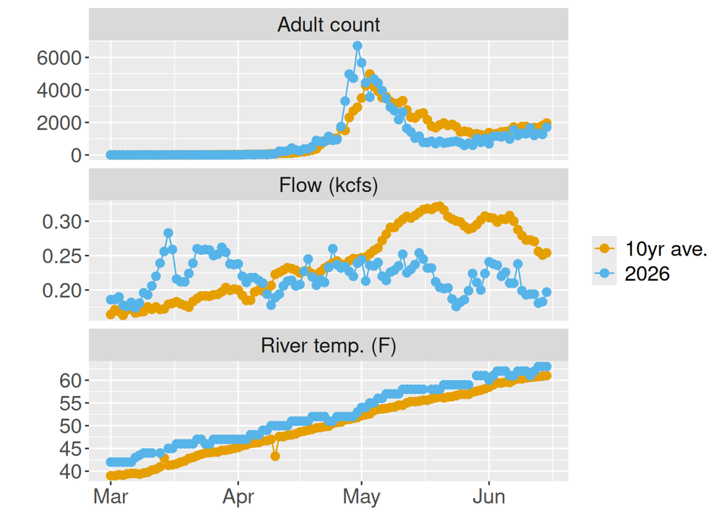

Daily adult Chinook salmon counts, flow, and temperature measurements taken at Bonneville Dam.

###### Percent complete

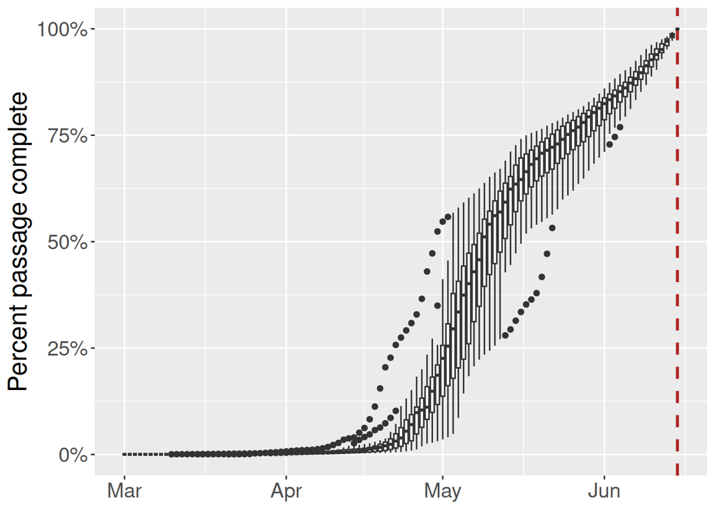

**Percent of the run complete by date in 2011–2025**. Lower and upper hinges correspond to the first and third quartiles (the 25th and 75th percentiles).The upper whisker extends from the hinge to the largest value no further than 1.5 * IQR from the hinge (where IQR is the inter-quartile range, or distance between the first and third quartiles). The lower whisker extends from the hinge to the smallest value at most 1.5 * IQR of the hinge. Data beyond the end of the whiskers are called "outlying" points and are plotted individually.

###### Prediction error

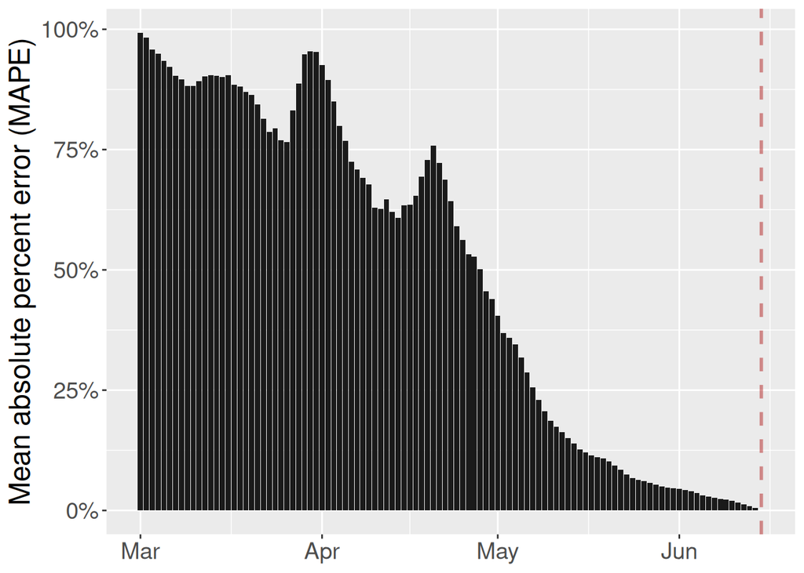

Mean absolute percent error (over 15 year retrospectiv) of predictions based on cumulative counts and 10-year average run timing, by day of year.

##### Run size predictions

###### Prediction table

| Model | Pred | Lo 95 | Lo 50 | Hi 50 | Hi 95 | MAPE |
| --- | --- | --- | --- | --- | --- | --- |
| 10-year ave. timing | 107,541 | 107,541 | 107,541 | 107,541 | 107,541 | 0% |
| 5-year ave. timing | 107,541 | 107,541 | 107,541 | 107,541 | 107,541 | 0% |

###### Prediction plot

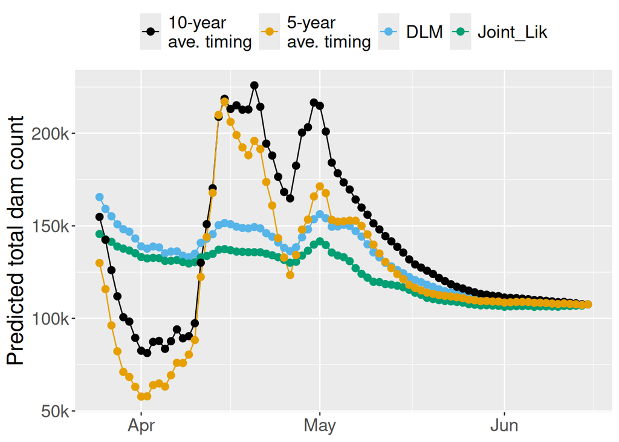

Daily predictions of total counts at Bonneville from different models.

###### Prediction interval plot

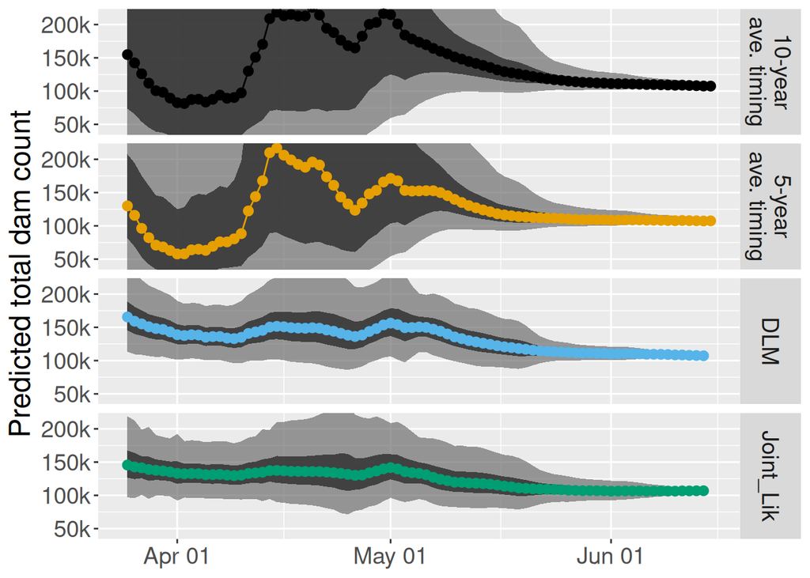

Daily predictions and prediction intervals (95% and 50%). Prediction intervals for different model types are calculated using different methods, so may not be directly comparable. See Methods Description for more details.

###### Methods description

DLM

This is a penalized dynamic linear model fit with the [`Sibregresr` package](https://dfw-wa.github.io/sibregresr/articles/Overview.html). The coefficients are the:

1. log-transformed total count of jacks at Bonneville Dam in the *previous* year,
2. log-transformed cumulative adult count at Bonneville Dam in the *current* year,
3. and interaction between an exponential moving average of river discharge and the cumulative adult count.

The prediction interval is based on the standard deviation (in log-space) of forecasts from a 15-year retrospective. In other words, the root mean square error of the forecast error in log space from a 15-year retrospective is used as the standard deviation in a lognormal prediction interval.

ARIMA

This is an ensemble of ARIMA models fit with the [`SalmonForecasting` package](https://github.com/wdfw-fp/salmonforecast) (see README at the linked page for details). The covariates are the same as those described above for the DLM. Prediction intervals are the weighted average of the prediction intervals provided by the `forecast::forecast()` function in `R`.

Joint likelihood

This is a version of a model that has been used for this purpose of in-season forecasting for several years. The proportion of the run that is complete on a given day is modeled with autoregressive (order 1) errors and an effect of the river discharge covariate. The pre-season forecast is generated using an age-specific sibling regression. I have not yet implemented a retrospective assessment of performance because, in this version, the pre-season forecasts and prediction uncertainty need to be provided, and I have not pulled in the past 15 years’ forecasts.

10 year average run timing

This method takes the 10-year average of the proportion of the run that was complete on a given day and uses it to expand the cumulative counts to date. Performance and prediction intervals are based on a 15-year retrospective as described above for the DLM but assuming a normal prediction distribution for the proportion complete in logit space.

##### Average timing info

###### 10-year average

Prediction

| Date | Daily counts | Cumulative count | 10 Days Early | 9 Days Early | 8 Days Early | 7 Days Early | 6 Days Early | 5 Days Early | 4 Days Early | 3 Days Early | 2 Days Early | 1 Days Early | 10yr Average | 1 Days Late | 2 Days Late | 3 Days Late | 4 Days Late | 5 Days Late | 6 Days Late | 7 Days Late | 8 Days Late | 9 Days Late | 10 Days Late |
| --- | --- | --- | --- | --- | --- | --- | --- | --- | --- | --- | --- | --- | --- | --- | --- | --- | --- | --- | --- | --- | --- | --- | --- |
| 15-Jun | 1,704 | 107,487 | NA | NA | NA | NA | NA | NA | NA | NA | NA | NA | 107,541 | 109,377 | 111,204 | 112,978 | 114,804 | 116,568 | 118,504 | 120,455 | 122,326 | 124,388 | 126,246 |
| 14-Jun | 1,262 | 105,783 | NA | NA | NA | NA | NA | NA | NA | NA | NA | 105,836 | 107,643 | 109,441 | 111,187 | 112,984 | 114,720 | 116,625 | 118,545 | 120,387 | 122,416 | 124,245 | 126,140 |
| 13-Jun | 1,330 | 104,521 | NA | NA | NA | NA | NA | NA | NA | NA | 104,573 | 106,359 | 108,135 | 109,860 | 111,636 | 113,352 | 115,234 | 117,131 | 118,951 | 120,955 | 122,763 | 124,635 | 126,526 |
| 12-Jun | 1,198 | 103,191 | NA | NA | NA | NA | NA | NA | NA | 103,243 | 105,005 | 106,759 | 108,462 | 110,215 | 111,909 | 113,768 | 115,640 | 117,437 | 119,416 | 121,201 | 123,049 | 124,916 | 126,667 |
| 11-Jun | 1,665 | 101,993 | NA | NA | NA | NA | NA | NA | 102,044 | 103,786 | 105,520 | 107,203 | 108,936 | 110,610 | 112,447 | 114,298 | 116,074 | 118,030 | 119,793 | 121,620 | 123,465 | 125,196 | 126,964 |
| 10-Jun | 1,297 | 100,328 | NA | NA | NA | NA | NA | 100,378 | 102,092 | 103,797 | 105,453 | 107,157 | 108,805 | 110,611 | 112,432 | 114,179 | 116,103 | 117,838 | 119,635 | 121,450 | 123,152 | 124,891 | 126,734 |
| 09-Jun | 1,332 | 99,031 | NA | NA | NA | NA | 99,081 | 100,772 | 102,455 | 104,090 | 105,772 | 107,398 | 109,181 | 110,979 | 112,703 | 114,602 | 116,314 | 118,088 | 119,880 | 121,560 | 123,277 | 125,096 | 126,753 |
| 08-Jun | 1,201 | 97,699 | NA | NA | NA | 97,748 | 99,417 | 101,077 | 102,690 | 104,349 | 105,953 | 107,713 | 109,486 | 111,187 | 113,061 | 114,750 | 116,500 | 118,267 | 119,925 | 121,619 | 123,413 | 125,048 | 126,805 |
| 07-Jun | 1,538 | 96,498 | NA | NA | 96,546 | 98,195 | 99,835 | 101,427 | 103,067 | 104,651 | 106,389 | 108,140 | 109,820 | 111,671 | 113,339 | 115,068 | 116,814 | 118,451 | 120,124 | 121,896 | 123,511 | 125,246 | 127,157 |
| 06-Jun | 974 | 94,960 | NA | 95,008 | 96,630 | 98,243 | 99,811 | 101,424 | 102,983 | 104,693 | 106,416 | 108,070 | 109,891 | 111,533 | 113,234 | 114,952 | 116,563 | 118,209 | 119,953 | 121,542 | 123,250 | 125,130 | 127,002 |
| 05-Jun | 1,181 | 93,986 | 94,033 | 95,638 | 97,236 | 98,787 | 100,384 | 101,927 | 103,619 | 105,325 | 106,961 | 108,764 | 110,389 | 112,073 | 113,773 | 115,367 | 116,997 | 118,723 | 120,295 | 121,986 | 123,847 | 125,699 | 127,789 |
| 04-Jun | 1,113 | 92,805 | 94,437 | 96,014 | 97,546 | 99,122 | 100,646 | 102,317 | 104,001 | 105,617 | 107,397 | 109,002 | 110,664 | 112,343 | 113,918 | 115,527 | 117,231 | 118,784 | 120,453 | 122,291 | 124,120 | 126,183 | 128,328 |
| 03-Jun | 1,163 | 91,692 | 94,862 | 96,376 | 97,934 | 99,439 | 101,090 | 102,754 | 104,351 | 106,109 | 107,695 | 109,337 | 110,996 | 112,552 | 114,141 | 115,825 | 117,359 | 119,009 | 120,824 | 122,631 | 124,670 | 126,789 | 128,951 |
| 02-Jun | 1,140 | 90,529 | 95,154 | 96,691 | 98,178 | 99,808 | 101,451 | 103,027 | 104,763 | 106,329 | 107,950 | 109,588 | 111,124 | 112,693 | 114,356 | 115,871 | 117,499 | 119,292 | 121,076 | 123,088 | 125,181 | 127,315 | 130,151 |
| 01-Jun | 686 | 89,389 | 95,474 | 96,941 | 98,551 | 100,173 | 101,730 | 103,444 | 104,990 | 106,591 | 108,208 | 109,725 | 111,274 | 112,916 | 114,412 | 116,019 | 117,789 | 119,551 | 121,538 | 123,604 | 125,712 | 128,512 | 131,650 |
| 31-May | 1,007 | 88,703 | 96,197 | 97,795 | 99,405 | 100,949 | 102,650 | 104,184 | 105,773 | 107,377 | 108,883 | 110,420 | 112,049 | 113,534 | 115,129 | 116,885 | 118,634 | 120,606 | 122,656 | 124,747 | 127,525 | 130,639 | 133,773 |
| 30-May | 775 | 87,696 | 96,684 | 98,276 | 99,803 | 101,485 | 103,001 | 104,572 | 106,158 | 107,647 | 109,167 | 110,777 | 112,245 | 113,822 | 115,558 | 117,287 | 119,237 | 121,263 | 123,331 | 126,078 | 129,156 | 132,254 | 135,774 |
| 29-May | 1,002 | 86,921 | 97,408 | 98,921 | 100,588 | 102,091 | 103,648 | 105,220 | 106,695 | 108,202 | 109,798 | 111,253 | 112,816 | 114,537 | 116,250 | 118,183 | 120,192 | 122,241 | 124,963 | 128,015 | 131,085 | 134,574 | 137,916 |
| 28-May | 596 | 85,919 | 97,781 | 99,429 | 100,914 | 102,453 | 104,007 | 105,465 | 106,955 | 108,533 | 109,970 | 111,516 | 113,217 | 114,910 | 116,820 | 118,806 | 120,832 | 123,523 | 126,539 | 129,574 | 133,023 | 136,326 | 139,388 |
| 27-May | 725 | 85,323 | 98,739 | 100,214 | 101,742 | 103,286 | 104,734 | 106,213 | 107,780 | 109,207 | 110,742 | 112,432 | 114,113 | 116,010 | 117,982 | 119,994 | 122,666 | 125,661 | 128,676 | 132,100 | 135,380 | 138,422 | 141,797 |
| 26-May | 588 | 84,598 | 99,363 | 100,878 | 102,408 | 103,844 | 105,310 | 106,864 | 108,279 | 109,801 | 111,476 | 113,144 | 115,024 | 116,979 | 118,974 | 121,624 | 124,594 | 127,582 | 130,978 | 134,230 | 137,245 | 140,592 | 144,985 |
| 25-May | 750 | 84,010 | 100,177 | 101,696 | 103,122 | 104,578 | 106,121 | 107,527 | 109,038 | 110,701 | 112,357 | 114,225 | 116,166 | 118,147 | 120,778 | 123,728 | 126,695 | 130,067 | 133,297 | 136,291 | 139,615 | 143,977 | 149,493 |
| 24-May | 849 | 83,260 | 100,789 | 102,201 | 103,645 | 105,174 | 106,567 | 108,065 | 109,713 | 111,354 | 113,205 | 115,129 | 117,093 | 119,700 | 122,623 | 125,564 | 128,906 | 132,107 | 135,075 | 138,368 | 142,692 | 148,158 | 153,853 |
| 23-May | 815 | 82,411 | 101,159 | 102,588 | 104,101 | 105,480 | 106,963 | 108,594 | 110,219 | 112,051 | 113,955 | 115,899 | 118,480 | 121,373 | 124,284 | 127,592 | 130,760 | 133,697 | 136,957 | 141,237 | 146,648 | 152,284 | 157,757 |
| 22-May | 769 | 81,596 | 101,573 | 103,072 | 104,437 | 105,905 | 107,520 | 109,129 | 110,943 | 112,828 | 114,752 | 117,308 | 120,172 | 123,055 | 126,330 | 129,467 | 132,375 | 135,603 | 139,840 | 145,197 | 150,778 | 156,197 | 162,379 |
| 21-May | 733 | 80,827 | 102,100 | 103,453 | 104,907 | 106,507 | 108,100 | 109,897 | 111,765 | 113,671 | 116,202 | 119,040 | 121,895 | 125,139 | 128,247 | 131,128 | 134,325 | 138,522 | 143,829 | 149,357 | 154,725 | 160,848 | 168,674 |
| 20-May | 843 | 80,094 | 102,515 | 103,955 | 105,541 | 107,120 | 108,900 | 110,751 | 112,640 | 115,148 | 117,960 | 120,790 | 124,004 | 127,084 | 129,938 | 133,107 | 137,266 | 142,525 | 148,003 | 153,322 | 159,390 | 167,145 | 177,431 |
| 19-May | 698 | 79,251 | 102,861 | 104,430 | 105,992 | 107,754 | 109,586 | 111,455 | 113,937 | 116,719 | 119,518 | 122,699 | 125,746 | 128,571 | 131,706 | 135,821 | 141,024 | 146,445 | 151,708 | 157,712 | 165,385 | 175,564 | 186,915 |
| 18-May | 839 | 78,553 | 103,511 | 105,059 | 106,805 | 108,621 | 110,473 | 112,933 | 115,691 | 118,466 | 121,619 | 124,638 | 127,438 | 130,546 | 134,625 | 139,782 | 145,155 | 150,372 | 156,323 | 163,929 | 174,018 | 185,269 | 198,016 |
| 17-May | 765 | 77,714 | 103,937 | 105,664 | 107,460 | 109,293 | 111,727 | 114,455 | 117,200 | 120,320 | 123,307 | 126,077 | 129,152 | 133,187 | 138,289 | 143,605 | 148,766 | 154,653 | 162,178 | 172,159 | 183,290 | 195,901 | 211,021 |

[output cut: 77 more lines]

Proportion complete

| Date | 10 Days Early | 9 Days Early | 8 Days Early | 7 Days Early | 6 Days Early | 5 Days Early | 4 Days Early | 3 Days Early | 2 Days Early | 1 Days Early | 10yr Average | 1 Days Late | 2 Days Late | 3 Days Late | 4 Days Late | 5 Days Late | 6 Days Late | 7 Days Late | 8 Days Late | 9 Days Late | 10 Days Late |
| --- | --- | --- | --- | --- | --- | --- | --- | --- | --- | --- | --- | --- | --- | --- | --- | --- | --- | --- | --- | --- | --- |
| 15-Jun | NA | NA | NA | NA | NA | NA | NA | NA | NA | NA | 1.00 | 0.98 | 0.97 | 0.95 | 0.94 | 0.92 | 0.91 | 0.89 | 0.88 | 0.86 | 0.85 |
| 14-Jun | NA | NA | NA | NA | NA | NA | NA | NA | NA | 1.00 | 0.98 | 0.97 | 0.95 | 0.94 | 0.92 | 0.91 | 0.89 | 0.88 | 0.86 | 0.85 | 0.84 |
| 13-Jun | NA | NA | NA | NA | NA | NA | NA | NA | 1.00 | 0.98 | 0.97 | 0.95 | 0.94 | 0.92 | 0.91 | 0.89 | 0.88 | 0.86 | 0.85 | 0.84 | 0.83 |
| 12-Jun | NA | NA | NA | NA | NA | NA | NA | 1.00 | 0.98 | 0.97 | 0.95 | 0.94 | 0.92 | 0.91 | 0.89 | 0.88 | 0.86 | 0.85 | 0.84 | 0.83 | 0.81 |
| 11-Jun | NA | NA | NA | NA | NA | NA | 1.00 | 0.98 | 0.97 | 0.95 | 0.94 | 0.92 | 0.91 | 0.89 | 0.88 | 0.86 | 0.85 | 0.84 | 0.83 | 0.81 | 0.80 |
| 10-Jun | NA | NA | NA | NA | NA | 1.00 | 0.98 | 0.97 | 0.95 | 0.94 | 0.92 | 0.91 | 0.89 | 0.88 | 0.86 | 0.85 | 0.84 | 0.83 | 0.81 | 0.80 | 0.79 |
| 09-Jun | NA | NA | NA | NA | 1.00 | 0.98 | 0.97 | 0.95 | 0.94 | 0.92 | 0.91 | 0.89 | 0.88 | 0.86 | 0.85 | 0.84 | 0.83 | 0.81 | 0.80 | 0.79 | 0.78 |
| 08-Jun | NA | NA | NA | 1.00 | 0.98 | 0.97 | 0.95 | 0.94 | 0.92 | 0.91 | 0.89 | 0.88 | 0.86 | 0.85 | 0.84 | 0.83 | 0.81 | 0.80 | 0.79 | 0.78 | 0.77 |
| 07-Jun | NA | NA | 1.00 | 0.98 | 0.97 | 0.95 | 0.94 | 0.92 | 0.91 | 0.89 | 0.88 | 0.86 | 0.85 | 0.84 | 0.83 | 0.81 | 0.80 | 0.79 | 0.78 | 0.77 | 0.76 |
| 06-Jun | NA | 1.00 | 0.98 | 0.97 | 0.95 | 0.94 | 0.92 | 0.91 | 0.89 | 0.88 | 0.86 | 0.85 | 0.84 | 0.83 | 0.81 | 0.80 | 0.79 | 0.78 | 0.77 | 0.76 | 0.75 |
| 05-Jun | 1.00 | 0.98 | 0.97 | 0.95 | 0.94 | 0.92 | 0.91 | 0.89 | 0.88 | 0.86 | 0.85 | 0.84 | 0.83 | 0.81 | 0.80 | 0.79 | 0.78 | 0.77 | 0.76 | 0.75 | 0.74 |
| 04-Jun | 0.98 | 0.97 | 0.95 | 0.94 | 0.92 | 0.91 | 0.89 | 0.88 | 0.86 | 0.85 | 0.84 | 0.83 | 0.81 | 0.80 | 0.79 | 0.78 | 0.77 | 0.76 | 0.75 | 0.74 | 0.72 |
| 03-Jun | 0.97 | 0.95 | 0.94 | 0.92 | 0.91 | 0.89 | 0.88 | 0.86 | 0.85 | 0.84 | 0.83 | 0.81 | 0.80 | 0.79 | 0.78 | 0.77 | 0.76 | 0.75 | 0.74 | 0.72 | 0.71 |
| 02-Jun | 0.95 | 0.94 | 0.92 | 0.91 | 0.89 | 0.88 | 0.86 | 0.85 | 0.84 | 0.83 | 0.81 | 0.80 | 0.79 | 0.78 | 0.77 | 0.76 | 0.75 | 0.74 | 0.72 | 0.71 | 0.70 |
| 01-Jun | 0.94 | 0.92 | 0.91 | 0.89 | 0.88 | 0.86 | 0.85 | 0.84 | 0.83 | 0.81 | 0.80 | 0.79 | 0.78 | 0.77 | 0.76 | 0.75 | 0.74 | 0.72 | 0.71 | 0.70 | 0.68 |
| 31-May | 0.92 | 0.91 | 0.89 | 0.88 | 0.86 | 0.85 | 0.84 | 0.83 | 0.81 | 0.80 | 0.79 | 0.78 | 0.77 | 0.76 | 0.75 | 0.74 | 0.72 | 0.71 | 0.70 | 0.68 | 0.66 |
| 30-May | 0.91 | 0.89 | 0.88 | 0.86 | 0.85 | 0.84 | 0.83 | 0.81 | 0.80 | 0.79 | 0.78 | 0.77 | 0.76 | 0.75 | 0.74 | 0.72 | 0.71 | 0.70 | 0.68 | 0.66 | 0.65 |
| 29-May | 0.89 | 0.88 | 0.86 | 0.85 | 0.84 | 0.83 | 0.81 | 0.80 | 0.79 | 0.78 | 0.77 | 0.76 | 0.75 | 0.74 | 0.72 | 0.71 | 0.70 | 0.68 | 0.66 | 0.65 | 0.63 |
| 28-May | 0.88 | 0.86 | 0.85 | 0.84 | 0.83 | 0.81 | 0.80 | 0.79 | 0.78 | 0.77 | 0.76 | 0.75 | 0.74 | 0.72 | 0.71 | 0.70 | 0.68 | 0.66 | 0.65 | 0.63 | 0.62 |
| 27-May | 0.86 | 0.85 | 0.84 | 0.83 | 0.81 | 0.80 | 0.79 | 0.78 | 0.77 | 0.76 | 0.75 | 0.74 | 0.72 | 0.71 | 0.70 | 0.68 | 0.66 | 0.65 | 0.63 | 0.62 | 0.60 |
| 26-May | 0.85 | 0.84 | 0.83 | 0.81 | 0.80 | 0.79 | 0.78 | 0.77 | 0.76 | 0.75 | 0.74 | 0.72 | 0.71 | 0.70 | 0.68 | 0.66 | 0.65 | 0.63 | 0.62 | 0.60 | 0.58 |
| 25-May | 0.84 | 0.83 | 0.81 | 0.80 | 0.79 | 0.78 | 0.77 | 0.76 | 0.75 | 0.74 | 0.72 | 0.71 | 0.70 | 0.68 | 0.66 | 0.65 | 0.63 | 0.62 | 0.60 | 0.58 | 0.56 |
| 24-May | 0.83 | 0.81 | 0.80 | 0.79 | 0.78 | 0.77 | 0.76 | 0.75 | 0.74 | 0.72 | 0.71 | 0.70 | 0.68 | 0.66 | 0.65 | 0.63 | 0.62 | 0.60 | 0.58 | 0.56 | 0.54 |
| 23-May | 0.81 | 0.80 | 0.79 | 0.78 | 0.77 | 0.76 | 0.75 | 0.74 | 0.72 | 0.71 | 0.70 | 0.68 | 0.66 | 0.65 | 0.63 | 0.62 | 0.60 | 0.58 | 0.56 | 0.54 | 0.52 |
| 22-May | 0.80 | 0.79 | 0.78 | 0.77 | 0.76 | 0.75 | 0.74 | 0.72 | 0.71 | 0.70 | 0.68 | 0.66 | 0.65 | 0.63 | 0.62 | 0.60 | 0.58 | 0.56 | 0.54 | 0.52 | 0.50 |
| 21-May | 0.79 | 0.78 | 0.77 | 0.76 | 0.75 | 0.74 | 0.72 | 0.71 | 0.70 | 0.68 | 0.66 | 0.65 | 0.63 | 0.62 | 0.60 | 0.58 | 0.56 | 0.54 | 0.52 | 0.50 | 0.48 |
| 20-May | 0.78 | 0.77 | 0.76 | 0.75 | 0.74 | 0.72 | 0.71 | 0.70 | 0.68 | 0.66 | 0.65 | 0.63 | 0.62 | 0.60 | 0.58 | 0.56 | 0.54 | 0.52 | 0.50 | 0.48 | 0.45 |
| 19-May | 0.77 | 0.76 | 0.75 | 0.74 | 0.72 | 0.71 | 0.70 | 0.68 | 0.66 | 0.65 | 0.63 | 0.62 | 0.60 | 0.58 | 0.56 | 0.54 | 0.52 | 0.50 | 0.48 | 0.45 | 0.42 |
| 18-May | 0.76 | 0.75 | 0.74 | 0.72 | 0.71 | 0.70 | 0.68 | 0.66 | 0.65 | 0.63 | 0.62 | 0.60 | 0.58 | 0.56 | 0.54 | 0.52 | 0.50 | 0.48 | 0.45 | 0.42 | 0.40 |
| 17-May | 0.75 | 0.74 | 0.72 | 0.71 | 0.70 | 0.68 | 0.66 | 0.65 | 0.63 | 0.62 | 0.60 | 0.58 | 0.56 | 0.54 | 0.52 | 0.50 | 0.48 | 0.45 | 0.42 | 0.40 | 0.37 |

[output cut: 77 more lines]

###### 5-year average

Prediction

| Date | Daily counts | Cumulative count | 10 Days Early | 9 Days Early | 8 Days Early | 7 Days Early | 6 Days Early | 5 Days Early | 4 Days Early | 3 Days Early | 2 Days Early | 1 Days Early | 5yr Average | 1 Days Late | 2 Days Late | 3 Days Late | 4 Days Late | 5 Days Late | 6 Days Late | 7 Days Late | 8 Days Late | 9 Days Late | 10 Days Late |
| --- | --- | --- | --- | --- | --- | --- | --- | --- | --- | --- | --- | --- | --- | --- | --- | --- | --- | --- | --- | --- | --- | --- | --- |
| 15-Jun | 1,704 | 107,487 | NA | NA | NA | NA | NA | NA | NA | NA | NA | NA | 107,541 | 108,999 | 110,708 | 112,321 | 113,898 | 115,463 | 117,248 | 119,139 | 120,816 | 122,746 | 124,488 |
| 14-Jun | 1,262 | 105,783 | NA | NA | NA | NA | NA | NA | NA | NA | NA | 105,836 | 107,271 | 108,953 | 110,540 | 112,092 | 113,633 | 115,389 | 117,250 | 118,901 | 120,800 | 122,515 | 124,123 |
| 13-Jun | 1,330 | 104,521 | NA | NA | NA | NA | NA | NA | NA | NA | 104,573 | 105,991 | 107,653 | 109,222 | 110,755 | 112,277 | 114,012 | 115,851 | 117,482 | 119,359 | 121,053 | 122,643 | 124,116 |
| 12-Jun | 1,198 | 103,191 | NA | NA | NA | NA | NA | NA | NA | 103,243 | 104,643 | 106,283 | 107,832 | 109,346 | 110,848 | 112,562 | 114,377 | 115,987 | 117,840 | 119,513 | 121,082 | 122,537 | 123,913 |
| 11-Jun | 1,665 | 101,993 | NA | NA | NA | NA | NA | NA | 102,044 | 103,428 | 105,050 | 106,580 | 108,076 | 109,561 | 111,255 | 113,049 | 114,641 | 116,472 | 118,125 | 119,676 | 121,114 | 122,474 | 123,881 |
| 10-Jun | 1,297 | 100,328 | NA | NA | NA | NA | NA | 100,378 | 101,739 | 103,335 | 104,840 | 106,312 | 107,773 | 109,439 | 111,204 | 112,769 | 114,571 | 116,197 | 117,723 | 119,137 | 120,475 | 121,859 | 123,386 |
| 09-Jun | 1,332 | 99,031 | NA | NA | NA | NA | 99,081 | 100,424 | 101,999 | 103,485 | 104,937 | 106,380 | 108,024 | 109,766 | 111,311 | 113,089 | 114,695 | 116,201 | 117,597 | 118,918 | 120,284 | 121,791 | 123,223 |
| 08-Jun | 1,201 | 97,699 | NA | NA | NA | 97,748 | 99,073 | 100,627 | 102,093 | 103,526 | 104,949 | 106,571 | 108,290 | 109,814 | 111,568 | 113,152 | 114,638 | 116,015 | 117,318 | 118,666 | 120,153 | 121,566 | 122,971 |
| 07-Jun | 1,538 | 96,498 | NA | NA | 96,546 | 97,855 | 99,390 | 100,838 | 102,253 | 103,659 | 105,261 | 106,959 | 108,464 | 110,197 | 111,761 | 113,229 | 114,589 | 115,876 | 117,207 | 118,676 | 120,071 | 121,460 | 122,771 |
| 06-Jun | 974 | 94,960 | NA | 95,008 | 96,296 | 97,806 | 99,231 | 100,624 | 102,006 | 103,583 | 105,254 | 106,736 | 108,440 | 109,980 | 111,424 | 112,763 | 114,029 | 115,339 | 116,785 | 118,158 | 119,524 | 120,815 | 122,162 |
| 05-Jun | 1,181 | 93,986 | 94,033 | 95,308 | 96,803 | 98,213 | 99,592 | 100,960 | 102,521 | 104,174 | 105,641 | 107,328 | 108,852 | 110,281 | 111,606 | 112,860 | 114,156 | 115,587 | 116,946 | 118,298 | 119,575 | 120,909 | 122,433 |
| 04-Jun | 1,113 | 92,805 | 94,111 | 95,586 | 96,979 | 98,340 | 99,692 | 101,232 | 102,865 | 104,313 | 105,980 | 107,484 | 108,895 | 110,204 | 111,441 | 112,721 | 114,134 | 115,476 | 116,811 | 118,073 | 119,390 | 120,895 | 122,586 |
| 03-Jun | 1,163 | 91,692 | 94,440 | 95,816 | 97,161 | 98,496 | 100,018 | 101,632 | 103,062 | 104,709 | 106,195 | 107,589 | 108,882 | 110,105 | 111,370 | 112,766 | 114,091 | 115,410 | 116,657 | 117,958 | 119,445 | 121,116 | 122,687 |
| 02-Jun | 1,140 | 90,529 | 94,600 | 95,928 | 97,247 | 98,750 | 100,343 | 101,755 | 103,380 | 104,848 | 106,225 | 107,501 | 108,708 | 109,957 | 111,335 | 112,644 | 113,947 | 115,177 | 116,462 | 117,930 | 119,579 | 121,131 | 122,858 |
| 01-Jun | 686 | 89,389 | 94,720 | 96,022 | 97,506 | 99,079 | 100,474 | 102,079 | 103,528 | 104,887 | 106,147 | 107,339 | 108,572 | 109,933 | 111,226 | 112,512 | 113,727 | 114,995 | 116,445 | 118,074 | 119,606 | 121,311 | 122,875 |
| 31-May | 1,007 | 88,703 | 95,285 | 96,758 | 98,319 | 99,703 | 101,295 | 102,733 | 104,082 | 105,333 | 106,516 | 107,739 | 109,090 | 110,372 | 111,648 | 112,854 | 114,113 | 115,551 | 117,168 | 118,688 | 120,380 | 121,932 | 123,531 |
| 30-May | 775 | 87,696 | 95,660 | 97,202 | 98,571 | 100,145 | 101,567 | 102,900 | 104,137 | 105,306 | 106,516 | 107,851 | 109,119 | 110,381 | 111,573 | 112,817 | 114,239 | 115,837 | 117,341 | 119,014 | 120,547 | 122,129 | 124,006 |
| 29-May | 1,002 | 86,921 | 96,343 | 97,700 | 99,260 | 100,669 | 101,991 | 103,217 | 104,376 | 105,575 | 106,898 | 108,155 | 109,405 | 110,587 | 111,820 | 113,230 | 114,814 | 116,304 | 117,962 | 119,482 | 121,050 | 122,910 | 124,931 |
| 28-May | 596 | 85,919 | 96,573 | 98,116 | 99,509 | 100,815 | 102,027 | 103,173 | 104,358 | 105,666 | 106,908 | 108,144 | 109,312 | 110,531 | 111,925 | 113,490 | 114,963 | 116,602 | 118,105 | 119,654 | 121,494 | 123,490 | 125,991 |
| 27-May | 725 | 85,323 | 97,435 | 98,819 | 100,116 | 101,319 | 102,457 | 103,634 | 104,933 | 106,166 | 107,394 | 108,554 | 109,765 | 111,148 | 112,703 | 114,165 | 115,793 | 117,285 | 118,824 | 120,651 | 122,634 | 125,117 | 127,846 |
| 26-May | 588 | 84,598 | 97,979 | 99,265 | 100,458 | 101,586 | 102,753 | 104,041 | 105,264 | 106,481 | 107,631 | 108,832 | 110,204 | 111,745 | 113,195 | 114,809 | 116,289 | 117,814 | 119,626 | 121,592 | 124,054 | 126,759 | 129,902 |
| 25-May | 750 | 84,010 | 98,575 | 99,760 | 100,880 | 102,039 | 103,318 | 104,533 | 105,741 | 106,883 | 108,075 | 109,438 | 110,969 | 112,409 | 114,011 | 115,481 | 116,996 | 118,794 | 120,747 | 123,192 | 125,878 | 128,999 | 133,706 |
| 24-May | 849 | 83,260 | 98,869 | 99,980 | 101,128 | 102,396 | 103,600 | 104,797 | 105,929 | 107,111 | 108,461 | 109,978 | 111,405 | 112,994 | 114,450 | 115,951 | 117,734 | 119,669 | 122,092 | 124,755 | 127,847 | 132,513 | 137,522 |
| 23-May | 815 | 82,411 | 98,960 | 100,097 | 101,351 | 102,543 | 103,729 | 104,849 | 106,018 | 107,355 | 108,856 | 110,269 | 111,841 | 113,283 | 114,769 | 116,533 | 118,448 | 120,847 | 123,482 | 126,544 | 131,162 | 136,120 | 141,623 |
| 22-May | 769 | 81,596 | 99,107 | 100,349 | 101,529 | 102,703 | 103,812 | 104,970 | 106,293 | 107,780 | 109,178 | 110,735 | 112,162 | 113,634 | 115,381 | 117,277 | 119,652 | 122,261 | 125,292 | 129,864 | 134,774 | 140,222 | 146,725 |
| 21-May | 733 | 80,827 | 99,403 | 100,572 | 101,735 | 102,834 | 103,981 | 105,291 | 106,764 | 108,150 | 109,692 | 111,105 | 112,563 | 114,293 | 116,172 | 118,524 | 121,109 | 124,111 | 128,641 | 133,504 | 138,901 | 145,343 | 153,883 |
| 20-May | 843 | 80,094 | 99,660 | 100,812 | 101,901 | 103,038 | 104,336 | 105,796 | 107,169 | 108,697 | 110,098 | 111,542 | 113,257 | 115,118 | 117,449 | 120,011 | 122,986 | 127,474 | 132,293 | 137,641 | 144,025 | 152,487 | 163,973 |
| 19-May | 698 | 79,251 | 99,751 | 100,829 | 101,953 | 103,238 | 104,682 | 106,041 | 107,553 | 108,939 | 110,368 | 112,065 | 113,907 | 116,213 | 118,748 | 121,691 | 126,132 | 130,901 | 136,192 | 142,509 | 150,882 | 162,247 | 174,178 |
| 18-May | 839 | 78,553 | 99,941 | 101,055 | 102,329 | 103,760 | 105,107 | 106,606 | 107,979 | 109,396 | 111,078 | 112,903 | 115,189 | 117,702 | 120,620 | 125,021 | 129,748 | 134,993 | 141,254 | 149,553 | 160,818 | 172,644 | 185,785 |
| 17-May | 765 | 77,714 | 99,976 | 101,236 | 102,652 | 103,984 | 105,467 | 106,826 | 108,227 | 109,891 | 111,697 | 113,959 | 116,445 | 119,331 | 123,686 | 128,362 | 133,551 | 139,745 | 147,956 | 159,101 | 170,800 | 183,800 | 196,304 |

[output cut: 77 more lines]

Proportion complete

| Date | 10 Days Early | 9 Days Early | 8 Days Early | 7 Days Early | 6 Days Early | 5 Days Early | 4 Days Early | 3 Days Early | 2 Days Early | 1 Days Early | 5yr Average | 1 Days Late | 2 Days Late | 3 Days Late | 4 Days Late | 5 Days Late | 6 Days Late | 7 Days Late | 8 Days Late | 9 Days Late | 10 Days Late |
| --- | --- | --- | --- | --- | --- | --- | --- | --- | --- | --- | --- | --- | --- | --- | --- | --- | --- | --- | --- | --- | --- |
| 15-Jun | NA | NA | NA | NA | NA | NA | NA | NA | NA | NA | 1.00 | 0.99 | 0.97 | 0.96 | 0.94 | 0.93 | 0.92 | 0.90 | 0.89 | 0.88 | 0.86 |
| 14-Jun | NA | NA | NA | NA | NA | NA | NA | NA | NA | 1.00 | 0.99 | 0.97 | 0.96 | 0.94 | 0.93 | 0.92 | 0.90 | 0.89 | 0.88 | 0.86 | 0.85 |
| 13-Jun | NA | NA | NA | NA | NA | NA | NA | NA | 1.00 | 0.99 | 0.97 | 0.96 | 0.94 | 0.93 | 0.92 | 0.90 | 0.89 | 0.88 | 0.86 | 0.85 | 0.84 |
| 12-Jun | NA | NA | NA | NA | NA | NA | NA | 1.00 | 0.99 | 0.97 | 0.96 | 0.94 | 0.93 | 0.92 | 0.90 | 0.89 | 0.88 | 0.86 | 0.85 | 0.84 | 0.83 |
| 11-Jun | NA | NA | NA | NA | NA | NA | 1.00 | 0.99 | 0.97 | 0.96 | 0.94 | 0.93 | 0.92 | 0.90 | 0.89 | 0.88 | 0.86 | 0.85 | 0.84 | 0.83 | 0.82 |
| 10-Jun | NA | NA | NA | NA | NA | 1.00 | 0.99 | 0.97 | 0.96 | 0.94 | 0.93 | 0.92 | 0.90 | 0.89 | 0.88 | 0.86 | 0.85 | 0.84 | 0.83 | 0.82 | 0.81 |
| 09-Jun | NA | NA | NA | NA | 1.00 | 0.99 | 0.97 | 0.96 | 0.94 | 0.93 | 0.92 | 0.90 | 0.89 | 0.88 | 0.86 | 0.85 | 0.84 | 0.83 | 0.82 | 0.81 | 0.80 |
| 08-Jun | NA | NA | NA | 1.00 | 0.99 | 0.97 | 0.96 | 0.94 | 0.93 | 0.92 | 0.90 | 0.89 | 0.88 | 0.86 | 0.85 | 0.84 | 0.83 | 0.82 | 0.81 | 0.80 | 0.79 |
| 07-Jun | NA | NA | 1.00 | 0.99 | 0.97 | 0.96 | 0.94 | 0.93 | 0.92 | 0.90 | 0.89 | 0.88 | 0.86 | 0.85 | 0.84 | 0.83 | 0.82 | 0.81 | 0.80 | 0.79 | 0.79 |
| 06-Jun | NA | 1.00 | 0.99 | 0.97 | 0.96 | 0.94 | 0.93 | 0.92 | 0.90 | 0.89 | 0.88 | 0.86 | 0.85 | 0.84 | 0.83 | 0.82 | 0.81 | 0.80 | 0.79 | 0.79 | 0.78 |
| 05-Jun | 1.00 | 0.99 | 0.97 | 0.96 | 0.94 | 0.93 | 0.92 | 0.90 | 0.89 | 0.88 | 0.86 | 0.85 | 0.84 | 0.83 | 0.82 | 0.81 | 0.80 | 0.79 | 0.79 | 0.78 | 0.77 |
| 04-Jun | 0.99 | 0.97 | 0.96 | 0.94 | 0.93 | 0.92 | 0.90 | 0.89 | 0.88 | 0.86 | 0.85 | 0.84 | 0.83 | 0.82 | 0.81 | 0.80 | 0.79 | 0.79 | 0.78 | 0.77 | 0.76 |
| 03-Jun | 0.97 | 0.96 | 0.94 | 0.93 | 0.92 | 0.90 | 0.89 | 0.88 | 0.86 | 0.85 | 0.84 | 0.83 | 0.82 | 0.81 | 0.80 | 0.79 | 0.79 | 0.78 | 0.77 | 0.76 | 0.75 |
| 02-Jun | 0.96 | 0.94 | 0.93 | 0.92 | 0.90 | 0.89 | 0.88 | 0.86 | 0.85 | 0.84 | 0.83 | 0.82 | 0.81 | 0.80 | 0.79 | 0.79 | 0.78 | 0.77 | 0.76 | 0.75 | 0.74 |
| 01-Jun | 0.94 | 0.93 | 0.92 | 0.90 | 0.89 | 0.88 | 0.86 | 0.85 | 0.84 | 0.83 | 0.82 | 0.81 | 0.80 | 0.79 | 0.79 | 0.78 | 0.77 | 0.76 | 0.75 | 0.74 | 0.73 |
| 31-May | 0.93 | 0.92 | 0.90 | 0.89 | 0.88 | 0.86 | 0.85 | 0.84 | 0.83 | 0.82 | 0.81 | 0.80 | 0.79 | 0.79 | 0.78 | 0.77 | 0.76 | 0.75 | 0.74 | 0.73 | 0.72 |
| 30-May | 0.92 | 0.90 | 0.89 | 0.88 | 0.86 | 0.85 | 0.84 | 0.83 | 0.82 | 0.81 | 0.80 | 0.79 | 0.79 | 0.78 | 0.77 | 0.76 | 0.75 | 0.74 | 0.73 | 0.72 | 0.71 |
| 29-May | 0.90 | 0.89 | 0.88 | 0.86 | 0.85 | 0.84 | 0.83 | 0.82 | 0.81 | 0.80 | 0.79 | 0.79 | 0.78 | 0.77 | 0.76 | 0.75 | 0.74 | 0.73 | 0.72 | 0.71 | 0.70 |
| 28-May | 0.89 | 0.88 | 0.86 | 0.85 | 0.84 | 0.83 | 0.82 | 0.81 | 0.80 | 0.79 | 0.79 | 0.78 | 0.77 | 0.76 | 0.75 | 0.74 | 0.73 | 0.72 | 0.71 | 0.70 | 0.68 |
| 27-May | 0.88 | 0.86 | 0.85 | 0.84 | 0.83 | 0.82 | 0.81 | 0.80 | 0.79 | 0.79 | 0.78 | 0.77 | 0.76 | 0.75 | 0.74 | 0.73 | 0.72 | 0.71 | 0.70 | 0.68 | 0.67 |
| 26-May | 0.86 | 0.85 | 0.84 | 0.83 | 0.82 | 0.81 | 0.80 | 0.79 | 0.79 | 0.78 | 0.77 | 0.76 | 0.75 | 0.74 | 0.73 | 0.72 | 0.71 | 0.70 | 0.68 | 0.67 | 0.65 |
| 25-May | 0.85 | 0.84 | 0.83 | 0.82 | 0.81 | 0.80 | 0.79 | 0.79 | 0.78 | 0.77 | 0.76 | 0.75 | 0.74 | 0.73 | 0.72 | 0.71 | 0.70 | 0.68 | 0.67 | 0.65 | 0.63 |
| 24-May | 0.84 | 0.83 | 0.82 | 0.81 | 0.80 | 0.79 | 0.79 | 0.78 | 0.77 | 0.76 | 0.75 | 0.74 | 0.73 | 0.72 | 0.71 | 0.70 | 0.68 | 0.67 | 0.65 | 0.63 | 0.61 |
| 23-May | 0.83 | 0.82 | 0.81 | 0.80 | 0.79 | 0.79 | 0.78 | 0.77 | 0.76 | 0.75 | 0.74 | 0.73 | 0.72 | 0.71 | 0.70 | 0.68 | 0.67 | 0.65 | 0.63 | 0.61 | 0.58 |
| 22-May | 0.82 | 0.81 | 0.80 | 0.79 | 0.79 | 0.78 | 0.77 | 0.76 | 0.75 | 0.74 | 0.73 | 0.72 | 0.71 | 0.70 | 0.68 | 0.67 | 0.65 | 0.63 | 0.61 | 0.58 | 0.56 |
| 21-May | 0.81 | 0.80 | 0.79 | 0.79 | 0.78 | 0.77 | 0.76 | 0.75 | 0.74 | 0.73 | 0.72 | 0.71 | 0.70 | 0.68 | 0.67 | 0.65 | 0.63 | 0.61 | 0.58 | 0.56 | 0.53 |
| 20-May | 0.80 | 0.79 | 0.79 | 0.78 | 0.77 | 0.76 | 0.75 | 0.74 | 0.73 | 0.72 | 0.71 | 0.70 | 0.68 | 0.67 | 0.65 | 0.63 | 0.61 | 0.58 | 0.56 | 0.53 | 0.49 |
| 19-May | 0.79 | 0.79 | 0.78 | 0.77 | 0.76 | 0.75 | 0.74 | 0.73 | 0.72 | 0.71 | 0.70 | 0.68 | 0.67 | 0.65 | 0.63 | 0.61 | 0.58 | 0.56 | 0.53 | 0.49 | 0.45 |
| 18-May | 0.79 | 0.78 | 0.77 | 0.76 | 0.75 | 0.74 | 0.73 | 0.72 | 0.71 | 0.70 | 0.68 | 0.67 | 0.65 | 0.63 | 0.61 | 0.58 | 0.56 | 0.53 | 0.49 | 0.45 | 0.42 |
| 17-May | 0.78 | 0.77 | 0.76 | 0.75 | 0.74 | 0.73 | 0.72 | 0.71 | 0.70 | 0.68 | 0.67 | 0.65 | 0.63 | 0.61 | 0.58 | 0.56 | 0.53 | 0.49 | 0.45 | 0.42 | 0.40 |

[output cut: 77 more lines]

## summer

The cumulative summer season adult Chinook passage at Bonneville Dam through July 31, 2026 is **39,726**. The 10-year (2016–2025) average proportion of the count that has occurred at Bonneville Dam through July 31 is **99.95%**. Based on the cumulative counts to date and this proportion, the expected total summer (Jun 16–Jul 31) season dam count would be 39,746 (95% prediction interval = 39,746 – 39,746 and 50% prediction interval = 39,746 – 39,746) adult Chinook.

###### Current year

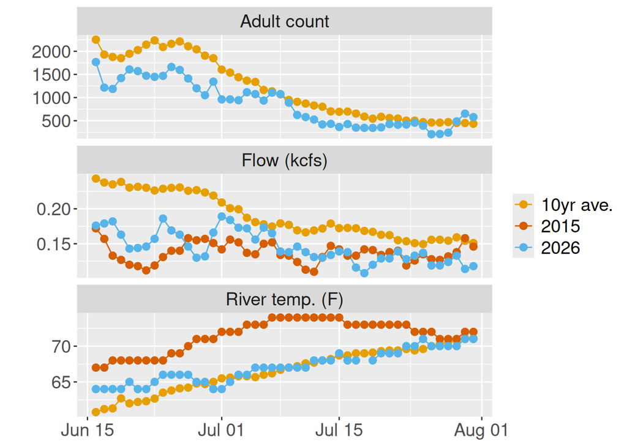

Daily adult Chinook salmon counts, flow, and temperature measurements taken at Bonneville Dam.

###### Percent complete

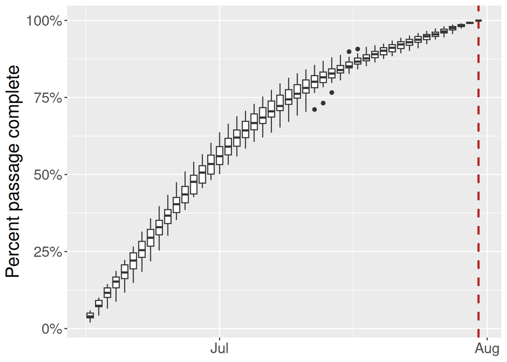

**Percent of the run complete by date in 2011–2025**. Lower and upper hinges correspond to the first and third quartiles (the 25th and 75th percentiles).The upper whisker extends from the hinge to the largest value no further than 1.5 * IQR from the hinge (where IQR is the inter-quartile range, or distance between the first and third quartiles). The lower whisker extends from the hinge to the smallest value at most 1.5 * IQR of the hinge. Data beyond the end of the whiskers are called "outlying" points and are plotted individually.

###### Prediction error

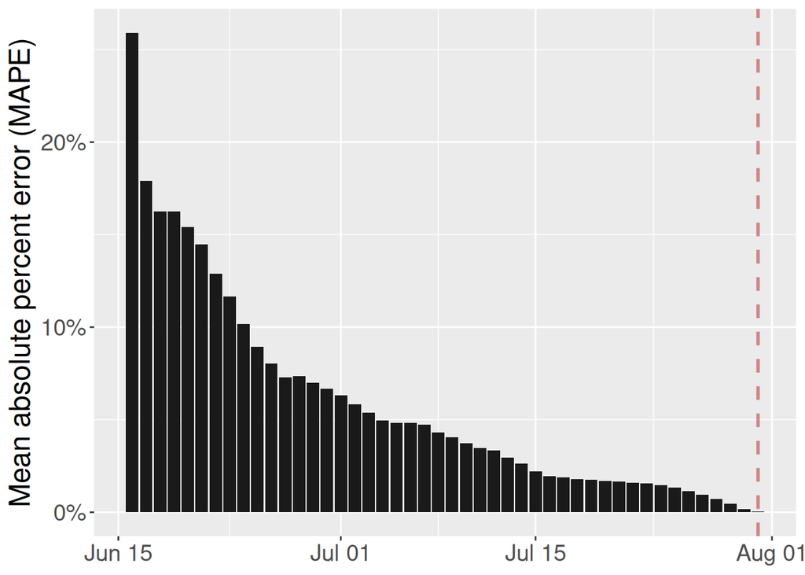

Mean absolute percent error (over 15 year retrospectiv) of predictions based on cumulative counts and 10-year average run timing, by day of year.

##### Run size predictions

###### Prediction table

| Model | Pred | Lo 95 | Lo 50 | Hi 50 | Hi 95 | MAPE |
| --- | --- | --- | --- | --- | --- | --- |
| 10-year ave. timing | 39,746 | 39,746 | 39,746 | 39,746 | 39,746 | 0% |
| 5-year ave. timing | 39,746 | 39,746 | 39,746 | 39,746 | 39,746 | 0% |

###### Prediction plot

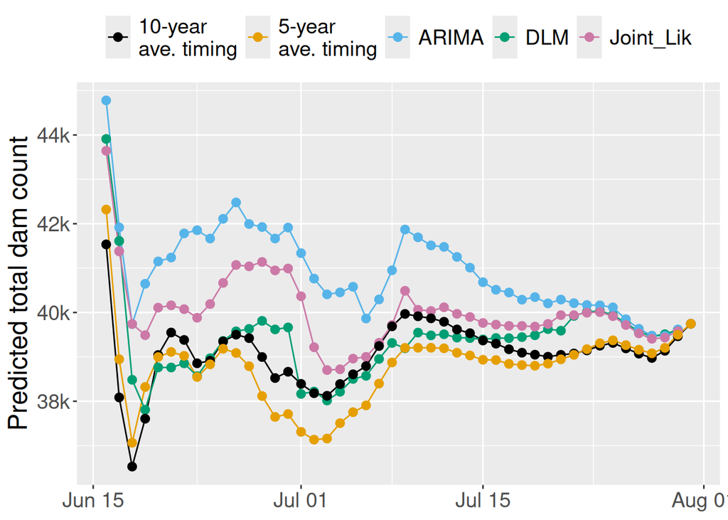

Daily predictions of total counts at Bonneville from different models.

###### Prediction interval plot

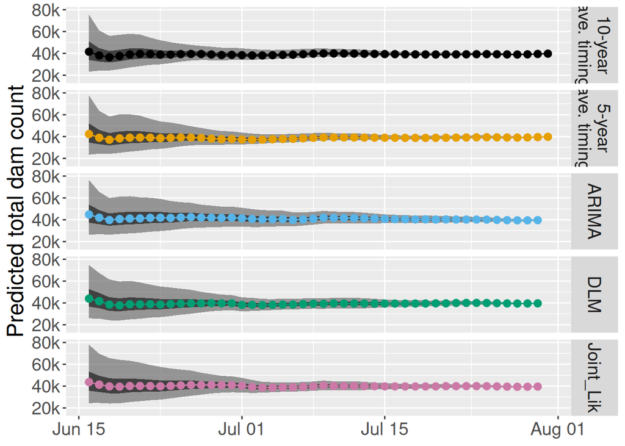

Daily predictions and prediction intervals (95% and 50%). Prediction intervals for different model types are calculated using different methods, so may not be directly comparable. See Methods Description for more details.

###### Methods description

DLM

This is a penalized dynamic linear model fit with the [`Sibregresr` package](https://dfw-wa.github.io/sibregresr/articles/Overview.html). The coefficients are the:

1. log-transformed total count of jacks at Bonneville Dam in the *previous* year,
2. log-transformed cumulative adult count at Bonneville Dam in the *current* year,
3. and interaction between an exponential moving average of river discharge and the cumulative adult count.

The prediction interval is based on the standard deviation (in log-space) of forecasts from a 15-year retrospective. In other words, the root mean square error of the forecast error in log space from a 15-year retrospective is used as the standard deviation in a lognormal prediction interval.

ARIMA

This is an ensemble of ARIMA models fit with the [`SalmonForecasting` package](https://github.com/wdfw-fp/salmonforecast) (see README at the linked page for details). The covariates are the same as those described above for the DLM. Prediction intervals are the weighted average of the prediction intervals provided by the `forecast::forecast()` function in `R`.

Joint likelihood

This is a version of a model that has been used for this purpose of in-season forecasting for several years. The proportion of the run that is complete on a given day is modeled with autoregressive (order 1) errors and an effect of the river discharge covariate. The pre-season forecast is generated using an age-specific sibling regression. I have not yet implemented a retrospective assessment of performance because, in this version, the pre-season forecasts and prediction uncertainty need to be provided, and I have not pulled in the past 15 years’ forecasts.

10 year average run timing

This method takes the 10-year average of the proportion of the run that was complete on a given day and uses it to expand the cumulative counts to date. Performance and prediction intervals are based on a 15-year retrospective as described above for the DLM but assuming a normal prediction distribution for the proportion complete in logit space.

##### Average timing info

###### 10-year average

Prediction

| Date | Daily counts | Cumulative count | 10 Days Early | 9 Days Early | 8 Days Early | 7 Days Early | 6 Days Early | 5 Days Early | 4 Days Early | 3 Days Early | 2 Days Early | 1 Days Early | 10yr Average | 1 Days Late | 2 Days Late | 3 Days Late | 4 Days Late | 5 Days Late | 6 Days Late | 7 Days Late | 8 Days Late | 9 Days Late | 10 Days Late |
| --- | --- | --- | --- | --- | --- | --- | --- | --- | --- | --- | --- | --- | --- | --- | --- | --- | --- | --- | --- | --- | --- | --- | --- |
| 31-Jul | 578 | 39,726 | NA | NA | NA | NA | NA | NA | NA | NA | NA | NA | 39,746 | 40,046 | 40,389 | 40,736 | 41,100 | 41,459 | 41,820 | 42,197 | 42,609 | 43,025 | 43,489 |
| 30-Jul | 653 | 39,148 | NA | NA | NA | NA | NA | NA | NA | NA | NA | 39,168 | 39,463 | 39,801 | 40,143 | 40,502 | 40,856 | 41,212 | 41,583 | 41,989 | 42,399 | 42,856 | 43,327 |
| 29-Jul | 486 | 38,495 | NA | NA | NA | NA | NA | NA | NA | NA | 38,514 | 38,805 | 39,137 | 39,473 | 39,826 | 40,174 | 40,524 | 40,889 | 41,289 | 41,691 | 42,141 | 42,605 | 43,089 |
| 28-Jul | 243 | 38,009 | NA | NA | NA | NA | NA | NA | NA | 38,028 | 38,315 | 38,643 | 38,975 | 39,324 | 39,667 | 40,013 | 40,373 | 40,767 | 41,165 | 41,609 | 42,067 | 42,545 | 43,018 |
| 27-Jul | 213 | 37,766 | NA | NA | NA | NA | NA | NA | 37,785 | 38,070 | 38,396 | 38,726 | 39,072 | 39,413 | 39,757 | 40,115 | 40,507 | 40,902 | 41,343 | 41,798 | 42,273 | 42,743 | 43,259 |
| 26-Jul | 208 | 37,553 | NA | NA | NA | NA | NA | 37,572 | 37,856 | 38,179 | 38,508 | 38,852 | 39,191 | 39,533 | 39,889 | 40,278 | 40,671 | 41,110 | 41,562 | 42,035 | 42,502 | 43,015 | 43,600 |
| 25-Jul | 392 | 37,345 | NA | NA | NA | NA | 37,364 | 37,646 | 37,968 | 38,294 | 38,637 | 38,974 | 39,314 | 39,668 | 40,055 | 40,446 | 40,882 | 41,332 | 41,802 | 42,266 | 42,777 | 43,359 | 43,993 |
| 24-Jul | 456 | 36,953 | NA | NA | NA | 36,971 | 37,251 | 37,569 | 37,892 | 38,231 | 38,565 | 38,901 | 39,252 | 39,635 | 40,021 | 40,453 | 40,898 | 41,363 | 41,823 | 42,328 | 42,904 | 43,531 | 44,193 |
| 23-Jul | 417 | 36,497 | NA | NA | 36,515 | 36,791 | 37,106 | 37,425 | 37,759 | 38,089 | 38,421 | 38,767 | 39,146 | 39,527 | 39,954 | 40,393 | 40,853 | 41,306 | 41,806 | 42,374 | 42,994 | 43,648 | 44,321 |
| 22-Jul | 413 | 36,080 | NA | 36,098 | 36,371 | 36,682 | 36,997 | 37,328 | 37,654 | 37,982 | 38,324 | 38,698 | 39,076 | 39,498 | 39,932 | 40,386 | 40,835 | 41,328 | 41,890 | 42,502 | 43,149 | 43,815 | 44,580 |
| 21-Jul | 426 | 35,667 | 35,685 | 35,954 | 36,262 | 36,574 | 36,901 | 37,223 | 37,547 | 37,886 | 38,255 | 38,629 | 39,046 | 39,475 | 39,923 | 40,367 | 40,855 | 41,411 | 42,016 | 42,655 | 43,313 | 44,070 | 44,888 |
| 20-Jul | 355 | 35,241 | 35,525 | 35,829 | 36,137 | 36,460 | 36,778 | 37,099 | 37,433 | 37,798 | 38,167 | 38,579 | 39,003 | 39,447 | 39,885 | 40,367 | 40,916 | 41,514 | 42,146 | 42,796 | 43,543 | 44,351 | 45,228 |
| 19-Jul | 344 | 34,886 | 35,468 | 35,773 | 36,093 | 36,408 | 36,725 | 37,056 | 37,418 | 37,783 | 38,191 | 38,610 | 39,049 | 39,483 | 39,960 | 40,504 | 41,096 | 41,721 | 42,365 | 43,105 | 43,905 | 44,772 | 45,750 |
| 18-Jul | 345 | 34,542 | 35,420 | 35,737 | 36,049 | 36,363 | 36,691 | 37,049 | 37,410 | 37,814 | 38,230 | 38,664 | 39,094 | 39,566 | 40,105 | 40,691 | 41,310 | 41,947 | 42,680 | 43,472 | 44,331 | 45,299 | 46,332 |
| 17-Jul | 350 | 34,197 | 35,380 | 35,689 | 36,000 | 36,324 | 36,679 | 37,036 | 37,436 | 37,848 | 38,278 | 38,703 | 39,171 | 39,704 | 40,284 | 40,897 | 41,528 | 42,254 | 43,038 | 43,888 | 44,846 | 45,870 | 47,067 |
| 16-Jul | 427 | 33,847 | 35,323 | 35,631 | 35,952 | 36,303 | 36,657 | 37,053 | 37,460 | 37,886 | 38,307 | 38,770 | 39,298 | 39,872 | 40,479 | 41,103 | 41,821 | 42,597 | 43,439 | 44,387 | 45,400 | 46,586 | 47,908 |
| 15-Jul | 364 | 33,420 | 35,182 | 35,499 | 35,845 | 36,195 | 36,586 | 36,988 | 37,408 | 37,824 | 38,281 | 38,802 | 39,369 | 39,968 | 40,585 | 41,293 | 42,060 | 42,891 | 43,827 | 44,827 | 45,998 | 47,303 | 48,740 |
| 14-Jul | 432 | 33,056 | 35,112 | 35,455 | 35,801 | 36,187 | 36,585 | 37,001 | 37,412 | 37,864 | 38,379 | 38,940 | 39,533 | 40,143 | 40,844 | 41,602 | 42,424 | 43,350 | 44,339 | 45,497 | 46,788 | 48,209 | 49,964 |
| 13-Jul | 420 | 32,624 | 34,992 | 35,333 | 35,714 | 36,107 | 36,517 | 36,923 | 37,369 | 37,878 | 38,431 | 39,016 | 39,618 | 40,310 | 41,058 | 41,869 | 42,784 | 43,760 | 44,902 | 46,177 | 47,579 | 49,311 | 51,220 |
| 12-Jul | 525 | 32,204 | 34,878 | 35,255 | 35,642 | 36,047 | 36,448 | 36,888 | 37,390 | 37,936 | 38,514 | 39,108 | 39,791 | 40,529 | 41,330 | 42,233 | 43,196 | 44,324 | 45,582 | 46,967 | 48,677 | 50,561 | 52,681 |
| 11-Jul | 578 | 31,679 | 34,680 | 35,061 | 35,460 | 35,854 | 36,287 | 36,780 | 37,318 | 37,886 | 38,470 | 39,142 | 39,869 | 40,656 | 41,544 | 42,492 | 43,602 | 44,839 | 46,201 | 47,883 | 49,737 | 51,823 | 54,346 |
| 10-Jul | 624 | 31,101 | 34,421 | 34,813 | 35,199 | 35,625 | 36,109 | 36,637 | 37,195 | 37,769 | 38,428 | 39,141 | 39,915 | 40,786 | 41,717 | 42,806 | 44,021 | 45,358 | 47,009 | 48,829 | 50,877 | 53,354 | 56,142 |
| 09-Jul | 889 | 30,477 | 34,114 | 34,493 | 34,910 | 35,385 | 35,902 | 36,449 | 37,011 | 37,657 | 38,356 | 39,114 | 39,968 | 40,880 | 41,947 | 43,138 | 44,448 | 46,066 | 47,850 | 49,856 | 52,284 | 55,015 | 58,484 |
| 08-Jul | 1,075 | 29,588 | 33,487 | 33,892 | 34,353 | 34,855 | 35,385 | 35,931 | 36,559 | 37,237 | 37,973 | 38,802 | 39,687 | 40,724 | 41,879 | 43,152 | 44,722 | 46,454 | 48,402 | 50,758 | 53,411 | 56,778 | 60,648 |
| 07-Jul | 1,106 | 28,513 | 32,660 | 33,105 | 33,588 | 34,100 | 34,626 | 35,230 | 35,884 | 36,593 | 37,392 | 38,246 | 39,244 | 40,358 | 41,584 | 43,098 | 44,766 | 46,643 | 48,914 | 51,470 | 54,715 | 58,445 | 63,063 |
| 06-Jul | 935 | 27,407 | 31,821 | 32,286 | 32,777 | 33,283 | 33,864 | 34,492 | 35,174 | 35,942 | 36,762 | 37,722 | 38,792 | 39,971 | 41,426 | 43,030 | 44,834 | 47,017 | 49,473 | 52,593 | 56,178 | 60,617 | 65,963 |
| 05-Jul | 1,075 | 26,472 | 31,184 | 31,659 | 32,147 | 32,709 | 33,316 | 33,974 | 34,716 | 35,508 | 36,435 | 37,469 | 38,607 | 40,013 | 41,562 | 43,305 | 45,413 | 47,786 | 50,799 | 54,261 | 58,549 | 63,713 | 70,307 |
| 04-Jul | 1,115 | 25,397 | 30,373 | 30,842 | 31,380 | 31,963 | 32,594 | 33,306 | 34,066 | 34,955 | 35,947 | 37,039 | 38,388 | 39,874 | 41,546 | 43,569 | 45,845 | 48,736 | 52,058 | 56,171 | 61,125 | 67,452 | 75,127 |
| 03-Jul | 942 | 24,282 | 29,488 | 30,003 | 30,559 | 31,163 | 31,844 | 32,570 | 33,421 | 34,369 | 35,413 | 36,702 | 38,123 | 39,722 | 41,656 | 43,832 | 46,596 | 49,772 | 53,705 | 58,442 | 64,491 | 71,829 | 80,743 |
| 02-Jul | 961 | 23,340 | 28,839 | 29,374 | 29,954 | 30,608 | 31,307 | 32,124 | 33,036 | 34,039 | 35,279 | 36,644 | 38,181 | 40,040 | 42,132 | 44,789 | 47,841 | 51,622 | 56,174 | 61,989 | 69,042 | 77,611 | 89,780 |
| 01-Jul | 960 | 22,379 | 28,164 | 28,721 | 29,348 | 30,018 | 30,802 | 31,676 | 32,638 | 33,826 | 35,136 | 36,609 | 38,391 | 40,397 | 42,944 | 45,872 | 49,496 | 53,862 | 59,436 | 66,200 | 74,416 | 86,083 | 100,965 |
| 30-Jun | 1,344 | 21,419 | 27,489 | 28,089 | 28,730 | 29,480 | 30,317 | 31,238 | 32,375 | 33,628 | 35,039 | 36,744 | 38,664 | 41,102 | 43,904 | 47,373 | 51,551 | 56,887 | 63,360 | 71,223 | 82,390 | 96,634 | 116,227 |
| 29-Jun | 1,050 | 20,075 | 26,327 | 26,927 | 27,630 | 28,415 | 29,278 | 30,343 | 31,518 | 32,840 | 34,439 | 36,238 | 38,523 | 41,149 | 44,400 | 48,316 | 53,317 | 59,384 | 66,754 | 77,220 | 90,571 | 108,934 | 135,102 |
| 28-Jun | 1,201 | 19,025 | 25,519 | 26,185 | 26,928 | 27,746 | 28,756 | 29,870 | 31,122 | 32,638 | 34,343 | 36,508 | 38,997 | 42,078 | 45,789 | 50,528 | 56,278 | 63,263 | 73,182 | 85,833 | 103,236 | 128,036 | 166,729 |
| 27-Jun | 1,412 | 17,824 | 24,532 | 25,228 | 25,995 | 26,941 | 27,984 | 29,158 | 30,577 | 32,175 | 34,204 | 36,535 | 39,422 | 42,899 | 47,339 | 52,725 | 59,269 | 68,562 | 80,415 | 96,719 | 119,953 | 156,204 | 227,646 |
| 26-Jun | 1,597 | 16,412 | 23,230 | 23,935 | 24,807 | 25,767 | 26,848 | 28,155 | 29,626 | 31,494 | 33,641 | 36,299 | 39,500 | 43,589 | 48,548 | 54,574 | 63,130 | 74,045 | 89,057 | 110,451 | 143,830 | 209,612 | 385,775 |
| 25-Jun | 1,661 | 14,815 | 21,606 | 22,393 | 23,260 | 24,235 | 25,415 | 26,743 | 28,429 | 30,367 | 32,767 | 35,657 | 39,347 | 43,824 | 49,263 | 56,987 | 66,840 | 80,391 | 99,703 | 129,834 | 189,216 | 348,236 | NA |
| 24-Jun | 1,469 | 13,154 | 19,882 | 20,652 | 21,518 | 22,566 | 23,745 | 25,242 | 26,963 | 29,093 | 31,659 | 34,936 | 38,911 | 43,740 | 50,598 | 59,346 | 71,378 | 88,525 | 115,278 | 168,001 | 309,193 | NA | NA |
| 23-Jun | 1,447 | 11,685 | 18,346 | 19,115 | 20,046 | 21,093 | 22,423 | 23,951 | 25,844 | 28,123 | 31,034 | 34,565 | 38,855 | 44,948 | 52,718 | 63,407 | 78,638 | 102,404 | 149,240 | 274,664 | NA | NA | NA |
| 22-Jun | 1,472 | 10,238 | 16,748 | 17,563 | 18,481 | 19,646 | 20,985 | 22,644 | 24,641 | 27,191 | 30,285 | 34,044 | 39,381 | 46,190 | 55,555 | 68,900 | 89,723 | 130,759 | 240,651 | NA | NA | NA | NA |
| 21-Jun | 1,571 | 8,766 | 15,038 | 15,824 | 16,822 | 17,968 | 19,388 | 21,098 | 23,282 | 25,931 | 29,149 | 33,719 | 39,549 | 47,567 | 58,994 | 76,823 | 111,958 | 206,051 | NA | NA | NA | NA | NA |
| 20-Jun | 1,607 | 7,195 | 12,988 | 13,807 | 14,748 | 15,913 | 17,317 | 19,109 | 21,284 | 23,925 | 27,676 | 32,461 | 39,042 | 48,421 | 63,055 | 91,894 | 169,123 | NA | NA | NA | NA | NA | NA |
| 19-Jun | 1,420 | 5,588 | 10,723 | 11,454 | 12,359 | 13,449 | 14,841 | 16,530 | 18,581 | 21,495 | 25,211 | 30,322 | 37,606 | 48,972 | 71,369 | 131,350 | NA | NA | NA | NA | NA | NA | NA |
| 18-Jun | 1,186 | 4,168 | 8,543 | 9,218 | 10,032 | 11,070 | 12,329 | 13,860 | 16,033 | 18,804 | 22,617 | 28,050 | 36,527 | 53,233 | 97,972 | NA | NA | NA | NA | NA | NA | NA | NA |
| 17-Jun | 1,215 | 2,982 | 6,595 | 7,177 | 7,920 | 8,821 | 9,916 | 11,471 | 13,454 | 16,181 | 20,068 | 26,133 | 38,086 | 70,094 | NA | NA | NA | NA | NA | NA | NA | NA | NA |
| 16-Jun | 1,767 | 1,767 | 4,253 | 4,693 | 5,227 | 5,876 | 6,797 | 7,972 | 9,588 | 11,892 | 15,485 | 22,568 | 41,535 | NA | NA | NA | NA | NA | NA | NA | NA | NA | NA |

Proportion complete

| Date | 10 Days Early | 9 Days Early | 8 Days Early | 7 Days Early | 6 Days Early | 5 Days Early | 4 Days Early | 3 Days Early | 2 Days Early | 1 Days Early | 10yr Average | 1 Days Late | 2 Days Late | 3 Days Late | 4 Days Late | 5 Days Late | 6 Days Late | 7 Days Late | 8 Days Late | 9 Days Late | 10 Days Late |
| --- | --- | --- | --- | --- | --- | --- | --- | --- | --- | --- | --- | --- | --- | --- | --- | --- | --- | --- | --- | --- | --- |
| 31-Jul | NA | NA | NA | NA | NA | NA | NA | NA | NA | NA | 1.00 | 0.99 | 0.98 | 0.98 | 0.97 | 0.96 | 0.95 | 0.94 | 0.93 | 0.92 | 0.91 |
| 30-Jul | NA | NA | NA | NA | NA | NA | NA | NA | NA | 1.00 | 0.99 | 0.98 | 0.98 | 0.97 | 0.96 | 0.95 | 0.94 | 0.93 | 0.92 | 0.91 | 0.90 |
| 29-Jul | NA | NA | NA | NA | NA | NA | NA | NA | 1.00 | 0.99 | 0.98 | 0.98 | 0.97 | 0.96 | 0.95 | 0.94 | 0.93 | 0.92 | 0.91 | 0.90 | 0.89 |
| 28-Jul | NA | NA | NA | NA | NA | NA | NA | 1.00 | 0.99 | 0.98 | 0.98 | 0.97 | 0.96 | 0.95 | 0.94 | 0.93 | 0.92 | 0.91 | 0.90 | 0.89 | 0.88 |
| 27-Jul | NA | NA | NA | NA | NA | NA | 1.00 | 0.99 | 0.98 | 0.98 | 0.97 | 0.96 | 0.95 | 0.94 | 0.93 | 0.92 | 0.91 | 0.90 | 0.89 | 0.88 | 0.87 |
| 26-Jul | NA | NA | NA | NA | NA | 1.00 | 0.99 | 0.98 | 0.98 | 0.97 | 0.96 | 0.95 | 0.94 | 0.93 | 0.92 | 0.91 | 0.90 | 0.89 | 0.88 | 0.87 | 0.86 |
| 25-Jul | NA | NA | NA | NA | 1.00 | 0.99 | 0.98 | 0.98 | 0.97 | 0.96 | 0.95 | 0.94 | 0.93 | 0.92 | 0.91 | 0.90 | 0.89 | 0.88 | 0.87 | 0.86 | 0.85 |
| 24-Jul | NA | NA | NA | 1.00 | 0.99 | 0.98 | 0.98 | 0.97 | 0.96 | 0.95 | 0.94 | 0.93 | 0.92 | 0.91 | 0.90 | 0.89 | 0.88 | 0.87 | 0.86 | 0.85 | 0.84 |
| 23-Jul | NA | NA | 1.00 | 0.99 | 0.98 | 0.98 | 0.97 | 0.96 | 0.95 | 0.94 | 0.93 | 0.92 | 0.91 | 0.90 | 0.89 | 0.88 | 0.87 | 0.86 | 0.85 | 0.84 | 0.82 |
| 22-Jul | NA | 1.00 | 0.99 | 0.98 | 0.98 | 0.97 | 0.96 | 0.95 | 0.94 | 0.93 | 0.92 | 0.91 | 0.90 | 0.89 | 0.88 | 0.87 | 0.86 | 0.85 | 0.84 | 0.82 | 0.81 |
| 21-Jul | 1.00 | 0.99 | 0.98 | 0.98 | 0.97 | 0.96 | 0.95 | 0.94 | 0.93 | 0.92 | 0.91 | 0.90 | 0.89 | 0.88 | 0.87 | 0.86 | 0.85 | 0.84 | 0.82 | 0.81 | 0.79 |
| 20-Jul | 0.99 | 0.98 | 0.98 | 0.97 | 0.96 | 0.95 | 0.94 | 0.93 | 0.92 | 0.91 | 0.90 | 0.89 | 0.88 | 0.87 | 0.86 | 0.85 | 0.84 | 0.82 | 0.81 | 0.79 | 0.78 |
| 19-Jul | 0.98 | 0.98 | 0.97 | 0.96 | 0.95 | 0.94 | 0.93 | 0.92 | 0.91 | 0.90 | 0.89 | 0.88 | 0.87 | 0.86 | 0.85 | 0.84 | 0.82 | 0.81 | 0.79 | 0.78 | 0.76 |
| 18-Jul | 0.98 | 0.97 | 0.96 | 0.95 | 0.94 | 0.93 | 0.92 | 0.91 | 0.90 | 0.89 | 0.88 | 0.87 | 0.86 | 0.85 | 0.84 | 0.82 | 0.81 | 0.79 | 0.78 | 0.76 | 0.75 |
| 17-Jul | 0.97 | 0.96 | 0.95 | 0.94 | 0.93 | 0.92 | 0.91 | 0.90 | 0.89 | 0.88 | 0.87 | 0.86 | 0.85 | 0.84 | 0.82 | 0.81 | 0.79 | 0.78 | 0.76 | 0.75 | 0.73 |
| 16-Jul | 0.96 | 0.95 | 0.94 | 0.93 | 0.92 | 0.91 | 0.90 | 0.89 | 0.88 | 0.87 | 0.86 | 0.85 | 0.84 | 0.82 | 0.81 | 0.79 | 0.78 | 0.76 | 0.75 | 0.73 | 0.71 |
| 15-Jul | 0.95 | 0.94 | 0.93 | 0.92 | 0.91 | 0.90 | 0.89 | 0.88 | 0.87 | 0.86 | 0.85 | 0.84 | 0.82 | 0.81 | 0.79 | 0.78 | 0.76 | 0.75 | 0.73 | 0.71 | 0.69 |
| 14-Jul | 0.94 | 0.93 | 0.92 | 0.91 | 0.90 | 0.89 | 0.88 | 0.87 | 0.86 | 0.85 | 0.84 | 0.82 | 0.81 | 0.79 | 0.78 | 0.76 | 0.75 | 0.73 | 0.71 | 0.69 | 0.66 |
| 13-Jul | 0.93 | 0.92 | 0.91 | 0.90 | 0.89 | 0.88 | 0.87 | 0.86 | 0.85 | 0.84 | 0.82 | 0.81 | 0.79 | 0.78 | 0.76 | 0.75 | 0.73 | 0.71 | 0.69 | 0.66 | 0.64 |
| 12-Jul | 0.92 | 0.91 | 0.90 | 0.89 | 0.88 | 0.87 | 0.86 | 0.85 | 0.84 | 0.82 | 0.81 | 0.79 | 0.78 | 0.76 | 0.75 | 0.73 | 0.71 | 0.69 | 0.66 | 0.64 | 0.61 |
| 11-Jul | 0.91 | 0.90 | 0.89 | 0.88 | 0.87 | 0.86 | 0.85 | 0.84 | 0.82 | 0.81 | 0.79 | 0.78 | 0.76 | 0.75 | 0.73 | 0.71 | 0.69 | 0.66 | 0.64 | 0.61 | 0.58 |
| 10-Jul | 0.90 | 0.89 | 0.88 | 0.87 | 0.86 | 0.85 | 0.84 | 0.82 | 0.81 | 0.79 | 0.78 | 0.76 | 0.75 | 0.73 | 0.71 | 0.69 | 0.66 | 0.64 | 0.61 | 0.58 | 0.55 |
| 09-Jul | 0.89 | 0.88 | 0.87 | 0.86 | 0.85 | 0.84 | 0.82 | 0.81 | 0.79 | 0.78 | 0.76 | 0.75 | 0.73 | 0.71 | 0.69 | 0.66 | 0.64 | 0.61 | 0.58 | 0.55 | 0.52 |
| 08-Jul | 0.88 | 0.87 | 0.86 | 0.85 | 0.84 | 0.82 | 0.81 | 0.79 | 0.78 | 0.76 | 0.75 | 0.73 | 0.71 | 0.69 | 0.66 | 0.64 | 0.61 | 0.58 | 0.55 | 0.52 | 0.49 |
| 07-Jul | 0.87 | 0.86 | 0.85 | 0.84 | 0.82 | 0.81 | 0.79 | 0.78 | 0.76 | 0.75 | 0.73 | 0.71 | 0.69 | 0.66 | 0.64 | 0.61 | 0.58 | 0.55 | 0.52 | 0.49 | 0.45 |
| 06-Jul | 0.86 | 0.85 | 0.84 | 0.82 | 0.81 | 0.79 | 0.78 | 0.76 | 0.75 | 0.73 | 0.71 | 0.69 | 0.66 | 0.64 | 0.61 | 0.58 | 0.55 | 0.52 | 0.49 | 0.45 | 0.42 |
| 05-Jul | 0.85 | 0.84 | 0.82 | 0.81 | 0.79 | 0.78 | 0.76 | 0.75 | 0.73 | 0.71 | 0.69 | 0.66 | 0.64 | 0.61 | 0.58 | 0.55 | 0.52 | 0.49 | 0.45 | 0.42 | 0.38 |
| 04-Jul | 0.84 | 0.82 | 0.81 | 0.79 | 0.78 | 0.76 | 0.75 | 0.73 | 0.71 | 0.69 | 0.66 | 0.64 | 0.61 | 0.58 | 0.55 | 0.52 | 0.49 | 0.45 | 0.42 | 0.38 | 0.34 |
| 03-Jul | 0.82 | 0.81 | 0.79 | 0.78 | 0.76 | 0.75 | 0.73 | 0.71 | 0.69 | 0.66 | 0.64 | 0.61 | 0.58 | 0.55 | 0.52 | 0.49 | 0.45 | 0.42 | 0.38 | 0.34 | 0.30 |
| 02-Jul | 0.81 | 0.79 | 0.78 | 0.76 | 0.75 | 0.73 | 0.71 | 0.69 | 0.66 | 0.64 | 0.61 | 0.58 | 0.55 | 0.52 | 0.49 | 0.45 | 0.42 | 0.38 | 0.34 | 0.30 | 0.26 |
| 01-Jul | 0.79 | 0.78 | 0.76 | 0.75 | 0.73 | 0.71 | 0.69 | 0.66 | 0.64 | 0.61 | 0.58 | 0.55 | 0.52 | 0.49 | 0.45 | 0.42 | 0.38 | 0.34 | 0.30 | 0.26 | 0.22 |
| 30-Jun | 0.78 | 0.76 | 0.75 | 0.73 | 0.71 | 0.69 | 0.66 | 0.64 | 0.61 | 0.58 | 0.55 | 0.52 | 0.49 | 0.45 | 0.42 | 0.38 | 0.34 | 0.30 | 0.26 | 0.22 | 0.18 |
| 29-Jun | 0.76 | 0.75 | 0.73 | 0.71 | 0.69 | 0.66 | 0.64 | 0.61 | 0.58 | 0.55 | 0.52 | 0.49 | 0.45 | 0.42 | 0.38 | 0.34 | 0.30 | 0.26 | 0.22 | 0.18 | 0.15 |
| 28-Jun | 0.75 | 0.73 | 0.71 | 0.69 | 0.66 | 0.64 | 0.61 | 0.58 | 0.55 | 0.52 | 0.49 | 0.45 | 0.42 | 0.38 | 0.34 | 0.30 | 0.26 | 0.22 | 0.18 | 0.15 | 0.11 |
| 27-Jun | 0.73 | 0.71 | 0.69 | 0.66 | 0.64 | 0.61 | 0.58 | 0.55 | 0.52 | 0.49 | 0.45 | 0.42 | 0.38 | 0.34 | 0.30 | 0.26 | 0.22 | 0.18 | 0.15 | 0.11 | 0.08 |
| 26-Jun | 0.71 | 0.69 | 0.66 | 0.64 | 0.61 | 0.58 | 0.55 | 0.52 | 0.49 | 0.45 | 0.42 | 0.38 | 0.34 | 0.30 | 0.26 | 0.22 | 0.18 | 0.15 | 0.11 | 0.08 | 0.04 |
| 25-Jun | 0.69 | 0.66 | 0.64 | 0.61 | 0.58 | 0.55 | 0.52 | 0.49 | 0.45 | 0.42 | 0.38 | 0.34 | 0.30 | 0.26 | 0.22 | 0.18 | 0.15 | 0.11 | 0.08 | 0.04 | NA |
| 24-Jun | 0.66 | 0.64 | 0.61 | 0.58 | 0.55 | 0.52 | 0.49 | 0.45 | 0.42 | 0.38 | 0.34 | 0.30 | 0.26 | 0.22 | 0.18 | 0.15 | 0.11 | 0.08 | 0.04 | NA | NA |
| 23-Jun | 0.64 | 0.61 | 0.58 | 0.55 | 0.52 | 0.49 | 0.45 | 0.42 | 0.38 | 0.34 | 0.30 | 0.26 | 0.22 | 0.18 | 0.15 | 0.11 | 0.08 | 0.04 | NA | NA | NA |
| 22-Jun | 0.61 | 0.58 | 0.55 | 0.52 | 0.49 | 0.45 | 0.42 | 0.38 | 0.34 | 0.30 | 0.26 | 0.22 | 0.18 | 0.15 | 0.11 | 0.08 | 0.04 | NA | NA | NA | NA |
| 21-Jun | 0.58 | 0.55 | 0.52 | 0.49 | 0.45 | 0.42 | 0.38 | 0.34 | 0.30 | 0.26 | 0.22 | 0.18 | 0.15 | 0.11 | 0.08 | 0.04 | NA | NA | NA | NA | NA |
| 20-Jun | 0.55 | 0.52 | 0.49 | 0.45 | 0.42 | 0.38 | 0.34 | 0.30 | 0.26 | 0.22 | 0.18 | 0.15 | 0.11 | 0.08 | 0.04 | NA | NA | NA | NA | NA | NA |
| 19-Jun | 0.52 | 0.49 | 0.45 | 0.42 | 0.38 | 0.34 | 0.30 | 0.26 | 0.22 | 0.18 | 0.15 | 0.11 | 0.08 | 0.04 | NA | NA | NA | NA | NA | NA | NA |
| 18-Jun | 0.49 | 0.45 | 0.42 | 0.38 | 0.34 | 0.30 | 0.26 | 0.22 | 0.18 | 0.15 | 0.11 | 0.08 | 0.04 | NA | NA | NA | NA | NA | NA | NA | NA |
| 17-Jun | 0.45 | 0.42 | 0.38 | 0.34 | 0.30 | 0.26 | 0.22 | 0.18 | 0.15 | 0.11 | 0.08 | 0.04 | NA | NA | NA | NA | NA | NA | NA | NA | NA |
| 16-Jun | 0.42 | 0.38 | 0.34 | 0.30 | 0.26 | 0.22 | 0.18 | 0.15 | 0.11 | 0.08 | 0.04 | NA | NA | NA | NA | NA | NA | NA | NA | NA | NA |

###### 5-year average

Prediction

| Date | Daily counts | Cumulative count | 10 Days Early | 9 Days Early | 8 Days Early | 7 Days Early | 6 Days Early | 5 Days Early | 4 Days Early | 3 Days Early | 2 Days Early | 1 Days Early | 5yr Average | 1 Days Late | 2 Days Late | 3 Days Late | 4 Days Late | 5 Days Late | 6 Days Late | 7 Days Late | 8 Days Late | 9 Days Late | 10 Days Late |
| --- | --- | --- | --- | --- | --- | --- | --- | --- | --- | --- | --- | --- | --- | --- | --- | --- | --- | --- | --- | --- | --- | --- | --- |
| 31-Jul | 578 | 39,726 | NA | NA | NA | NA | NA | NA | NA | NA | NA | NA | 39,746 | 40,081 | 40,457 | 40,845 | 41,194 | 41,537 | 41,883 | 42,256 | 42,639 | 42,991 | 43,376 |
| 30-Jul | 653 | 39,148 | NA | NA | NA | NA | NA | NA | NA | NA | NA | 39,168 | 39,498 | 39,869 | 40,251 | 40,595 | 40,933 | 41,274 | 41,641 | 42,019 | 42,366 | 42,745 | 43,153 |
| 29-Jul | 486 | 38,495 | NA | NA | NA | NA | NA | NA | NA | NA | 38,514 | 38,839 | 39,204 | 39,579 | 39,917 | 40,250 | 40,586 | 40,947 | 41,318 | 41,659 | 42,032 | 42,433 | 42,815 |
| 28-Jul | 243 | 38,009 | NA | NA | NA | NA | NA | NA | NA | 38,028 | 38,349 | 38,709 | 39,080 | 39,414 | 39,742 | 40,073 | 40,430 | 40,796 | 41,133 | 41,502 | 41,897 | 42,274 | 42,711 |
| 27-Jul | 213 | 37,766 | NA | NA | NA | NA | NA | NA | 37,785 | 38,104 | 38,461 | 38,830 | 39,162 | 39,488 | 39,817 | 40,171 | 40,536 | 40,870 | 41,236 | 41,629 | 42,004 | 42,438 | 42,896 |
| 26-Jul | 208 | 37,553 | NA | NA | NA | NA | NA | 37,572 | 37,889 | 38,244 | 38,611 | 38,941 | 39,265 | 39,592 | 39,945 | 40,307 | 40,640 | 41,004 | 41,395 | 41,767 | 42,198 | 42,654 | 43,191 |
| 25-Jul | 392 | 37,345 | NA | NA | NA | NA | 37,364 | 37,679 | 38,032 | 38,397 | 38,725 | 39,047 | 39,373 | 39,724 | 40,084 | 40,415 | 40,777 | 41,165 | 41,536 | 41,965 | 42,418 | 42,952 | 43,507 |
| 24-Jul | 456 | 36,953 | NA | NA | NA | 36,971 | 37,284 | 37,633 | 37,994 | 38,319 | 38,638 | 38,960 | 39,307 | 39,663 | 39,990 | 40,349 | 40,733 | 41,100 | 41,524 | 41,972 | 42,501 | 43,050 | 43,633 |
| 23-Jul | 417 | 36,497 | NA | NA | 36,515 | 36,824 | 37,169 | 37,525 | 37,846 | 38,161 | 38,479 | 38,822 | 39,174 | 39,497 | 39,851 | 40,231 | 40,592 | 41,012 | 41,454 | 41,976 | 42,519 | 43,094 | 43,733 |
| 22-Jul | 413 | 36,080 | NA | 36,098 | 36,403 | 36,744 | 37,096 | 37,413 | 37,725 | 38,039 | 38,378 | 38,726 | 39,046 | 39,395 | 39,771 | 40,129 | 40,543 | 40,981 | 41,497 | 42,033 | 42,602 | 43,234 | 43,910 |
| 21-Jul | 426 | 35,667 | 35,685 | 35,986 | 36,324 | 36,672 | 36,985 | 37,293 | 37,604 | 37,939 | 38,283 | 38,599 | 38,944 | 39,316 | 39,669 | 40,079 | 40,512 | 41,022 | 41,552 | 42,114 | 42,739 | 43,407 | 44,141 |
| 20-Jul | 355 | 35,241 | 35,556 | 35,890 | 36,234 | 36,543 | 36,848 | 37,155 | 37,486 | 37,825 | 38,138 | 38,479 | 38,846 | 39,196 | 39,600 | 40,028 | 40,532 | 41,056 | 41,611 | 42,228 | 42,889 | 43,614 | 44,424 |
| 19-Jul | 344 | 34,886 | 35,528 | 35,869 | 36,175 | 36,476 | 36,781 | 37,108 | 37,444 | 37,753 | 38,092 | 38,455 | 38,801 | 39,201 | 39,625 | 40,124 | 40,642 | 41,192 | 41,803 | 42,457 | 43,174 | 43,977 | 44,874 |
| 18-Jul | 345 | 34,542 | 35,515 | 35,818 | 36,117 | 36,418 | 36,742 | 37,075 | 37,381 | 37,716 | 38,076 | 38,418 | 38,815 | 39,234 | 39,728 | 40,241 | 40,786 | 41,391 | 42,038 | 42,749 | 43,543 | 44,432 | 45,383 |
| 17-Jul | 350 | 34,197 | 35,461 | 35,756 | 36,054 | 36,375 | 36,705 | 37,008 | 37,339 | 37,695 | 38,034 | 38,427 | 38,842 | 39,331 | 39,840 | 40,379 | 40,977 | 41,618 | 42,322 | 43,108 | 43,988 | 44,929 | 46,052 |
| 16-Jul | 427 | 33,847 | 35,390 | 35,685 | 36,003 | 36,329 | 36,629 | 36,957 | 37,310 | 37,645 | 38,034 | 38,444 | 38,929 | 39,432 | 39,965 | 40,558 | 41,192 | 41,889 | 42,667 | 43,538 | 44,470 | 45,581 | 46,814 |
| 15-Jul | 364 | 33,420 | 35,235 | 35,549 | 35,871 | 36,167 | 36,491 | 36,839 | 37,170 | 37,554 | 37,959 | 38,438 | 38,934 | 39,461 | 40,046 | 40,673 | 41,360 | 42,129 | 42,988 | 43,909 | 45,006 | 46,223 | 47,662 |
| 14-Jul | 432 | 33,056 | 35,161 | 35,480 | 35,773 | 36,094 | 36,438 | 36,765 | 37,145 | 37,546 | 38,019 | 38,510 | 39,031 | 39,610 | 40,230 | 40,910 | 41,670 | 42,520 | 43,430 | 44,516 | 45,720 | 47,143 | 48,817 |
| 13-Jul | 420 | 32,624 | 35,017 | 35,306 | 35,622 | 35,961 | 36,285 | 36,660 | 37,055 | 37,522 | 38,007 | 38,521 | 39,093 | 39,704 | 40,375 | 41,125 | 41,965 | 42,863 | 43,934 | 45,122 | 46,527 | 48,179 | 49,925 |
| 12-Jul | 525 | 32,204 | 34,851 | 35,163 | 35,498 | 35,818 | 36,188 | 36,578 | 37,039 | 37,518 | 38,025 | 38,589 | 39,193 | 39,855 | 40,596 | 41,424 | 42,311 | 43,368 | 44,541 | 45,928 | 47,558 | 49,282 | 51,237 |
| 11-Jul | 578 | 31,679 | 34,590 | 34,920 | 35,234 | 35,598 | 35,982 | 36,435 | 36,906 | 37,406 | 37,960 | 38,554 | 39,206 | 39,934 | 40,749 | 41,621 | 42,661 | 43,815 | 45,179 | 46,783 | 48,479 | 50,402 | 52,815 |
| 10-Jul | 624 | 31,101 | 34,283 | 34,591 | 34,948 | 35,325 | 35,770 | 36,233 | 36,723 | 37,268 | 37,850 | 38,490 | 39,205 | 40,005 | 40,862 | 41,883 | 43,016 | 44,355 | 45,929 | 47,595 | 49,482 | 51,852 | 54,758 |
| 09-Jul | 889 | 30,477 | 33,897 | 34,247 | 34,617 | 35,053 | 35,506 | 35,986 | 36,520 | 37,091 | 37,718 | 38,419 | 39,203 | 40,042 | 41,043 | 42,153 | 43,465 | 45,008 | 46,640 | 48,489 | 50,811 | 53,660 | 57,154 |
| 08-Jul | 1,075 | 29,588 | 33,248 | 33,607 | 34,030 | 34,470 | 34,937 | 35,455 | 36,009 | 36,618 | 37,298 | 38,059 | 38,874 | 39,846 | 40,923 | 42,197 | 43,695 | 45,279 | 47,075 | 49,329 | 52,095 | 55,487 | 59,281 |
| 07-Jul | 1,106 | 28,513 | 32,386 | 32,794 | 33,218 | 33,667 | 34,166 | 34,701 | 35,287 | 35,943 | 36,676 | 37,462 | 38,398 | 39,436 | 40,664 | 42,108 | 43,634 | 45,365 | 47,537 | 50,202 | 53,471 | 57,127 | 62,051 |
| 06-Jul | 935 | 27,407 | 31,522 | 31,929 | 32,361 | 32,841 | 33,355 | 33,919 | 34,549 | 35,254 | 36,008 | 36,908 | 37,907 | 39,087 | 40,474 | 41,942 | 43,605 | 45,693 | 48,255 | 51,397 | 54,911 | 59,645 | 65,275 |
| 05-Jul | 1,075 | 26,472 | 30,840 | 31,257 | 31,721 | 32,217 | 32,761 | 33,370 | 34,051 | 34,780 | 35,649 | 36,614 | 37,753 | 39,093 | 40,511 | 42,117 | 44,134 | 46,608 | 49,643 | 53,038 | 57,610 | 63,048 | 70,012 |
| 04-Jul | 1,115 | 25,397 | 29,988 | 30,433 | 30,909 | 31,431 | 32,015 | 32,668 | 33,368 | 34,202 | 35,127 | 36,220 | 37,506 | 38,866 | 40,407 | 42,342 | 44,716 | 47,627 | 50,884 | 55,270 | 60,488 | 67,169 | 74,975 |
| 03-Jul | 942 | 24,282 | 29,097 | 29,552 | 30,051 | 30,609 | 31,234 | 31,903 | 32,700 | 33,585 | 34,630 | 35,859 | 37,159 | 38,633 | 40,483 | 42,752 | 45,536 | 48,650 | 52,844 | 57,832 | 64,220 | 71,683 | 80,102 |
| 02-Jul | 961 | 23,340 | 28,405 | 28,885 | 29,422 | 30,022 | 30,665 | 31,431 | 32,282 | 33,287 | 34,468 | 35,718 | 37,134 | 38,913 | 41,094 | 43,770 | 46,763 | 50,794 | 55,589 | 61,729 | 68,902 | 76,994 | 88,962 |
| 01-Jul | 960 | 22,379 | 27,696 | 28,211 | 28,786 | 29,402 | 30,137 | 30,952 | 31,916 | 33,049 | 34,247 | 35,605 | 37,310 | 39,402 | 41,968 | 44,837 | 48,702 | 53,300 | 59,187 | 66,065 | 73,824 | 85,299 | 99,848 |
| 30-Jun | 1,344 | 21,419 | 27,000 | 27,551 | 28,141 | 28,844 | 29,625 | 30,547 | 31,631 | 32,778 | 34,078 | 35,710 | 37,712 | 40,167 | 42,914 | 46,613 | 51,013 | 56,648 | 63,231 | 70,657 | 81,640 | 95,565 | 116,088 |
| 29-Jun | 1,050 | 20,075 | 25,823 | 26,375 | 27,035 | 27,766 | 28,630 | 29,646 | 30,721 | 31,940 | 33,469 | 35,345 | 37,647 | 40,221 | 43,688 | 47,812 | 53,094 | 59,264 | 66,224 | 76,517 | 89,568 | 108,804 | 137,671 |
| 28-Jun | 1,201 | 19,025 | 24,996 | 25,621 | 26,314 | 27,133 | 28,096 | 29,114 | 30,269 | 31,719 | 33,497 | 35,678 | 38,117 | 41,403 | 45,312 | 50,317 | 56,164 | 62,760 | 72,515 | 84,883 | 103,113 | 130,470 | 169,184 |
| 27-Jun | 1,412 | 17,824 | 24,003 | 24,652 | 25,420 | 26,322 | 27,276 | 28,358 | 29,716 | 31,382 | 33,426 | 35,711 | 38,790 | 42,451 | 47,140 | 52,618 | 58,798 | 67,937 | 79,525 | 96,604 | 122,234 | 158,504 | 232,791 |
| 26-Jun | 1,597 | 16,412 | 22,700 | 23,406 | 24,237 | 25,116 | 26,112 | 27,362 | 28,896 | 30,778 | 32,882 | 35,717 | 39,088 | 43,406 | 48,450 | 54,140 | 62,555 | 73,225 | 88,951 | 112,551 | 145,947 | 214,350 | 393,068 |
| 25-Jun | 1,661 | 14,815 | 21,129 | 21,879 | 22,672 | 23,571 | 24,700 | 26,084 | 27,783 | 29,682 | 32,241 | 35,285 | 39,182 | 43,735 | 48,872 | 56,468 | 66,100 | 80,295 | 101,599 | 131,746 | 193,492 | 354,820 | NA |
| 24-Jun | 1,469 | 13,154 | 19,426 | 20,130 | 20,928 | 21,930 | 23,160 | 24,668 | 26,355 | 28,626 | 31,329 | 34,789 | 38,832 | 43,393 | 50,137 | 58,689 | 71,293 | 90,208 | 116,975 | 171,798 | 315,039 | NA | NA |
| 23-Jun | 1,447 | 11,685 | 17,882 | 18,591 | 19,481 | 20,573 | 21,913 | 23,411 | 25,430 | 27,830 | 30,904 | 34,495 | 38,547 | 44,538 | 52,135 | 63,331 | 80,134 | 103,911 | 152,612 | 279,857 | NA | NA | NA |
| 22-Jun | 1,472 | 10,238 | 16,289 | 17,069 | 18,026 | 19,199 | 20,512 | 22,280 | 24,384 | 27,077 | 30,224 | 33,773 | 39,023 | 45,679 | 55,489 | 70,211 | 91,044 | 133,714 | 245,201 | NA | NA | NA | NA |
| 21-Jun | 1,571 | 8,766 | 14,615 | 15,434 | 16,439 | 17,563 | 19,077 | 20,878 | 23,184 | 25,878 | 28,917 | 33,412 | 39,111 | 47,510 | 60,116 | 77,954 | 114,489 | 209,946 | NA | NA | NA | NA | NA |
| 20-Jun | 1,607 | 7,195 | 12,668 | 13,493 | 14,415 | 15,658 | 17,136 | 19,029 | 21,240 | 23,735 | 27,424 | 32,102 | 38,996 | 49,342 | 63,983 | 93,971 | 172,321 | NA | NA | NA | NA | NA | NA |
| 19-Jun | 1,420 | 5,588 | 10,479 | 11,196 | 12,161 | 13,309 | 14,779 | 16,496 | 18,434 | 21,299 | 24,932 | 30,286 | 38,322 | 49,692 | 72,982 | 133,833 | NA | NA | NA | NA | NA | NA | NA |
| 18-Jun | 1,186 | 4,168 | 8,351 | 9,071 | 9,927 | 11,023 | 12,304 | 13,749 | 15,887 | 18,596 | 22,590 | 28,583 | 37,065 | 54,436 | 99,824 | NA | NA | NA | NA | NA | NA | NA | NA |
| 17-Jun | 1,215 | 2,982 | 6,490 | 7,102 | 7,887 | 8,803 | 9,837 | 11,366 | 13,305 | 16,162 | 20,450 | 26,518 | 38,947 | 71,419 | NA | NA | NA | NA | NA | NA | NA | NA | NA |
| 16-Jun | 1,767 | 1,767 | 4,208 | 4,673 | 5,216 | 5,829 | 6,735 | 7,884 | 9,577 | 12,118 | 15,713 | 23,078 | 42,320 | NA | NA | NA | NA | NA | NA | NA | NA | NA | NA |

Proportion complete

| Date | 10 Days Early | 9 Days Early | 8 Days Early | 7 Days Early | 6 Days Early | 5 Days Early | 4 Days Early | 3 Days Early | 2 Days Early | 1 Days Early | 5yr Average | 1 Days Late | 2 Days Late | 3 Days Late | 4 Days Late | 5 Days Late | 6 Days Late | 7 Days Late | 8 Days Late | 9 Days Late | 10 Days Late |
| --- | --- | --- | --- | --- | --- | --- | --- | --- | --- | --- | --- | --- | --- | --- | --- | --- | --- | --- | --- | --- | --- |
| 31-Jul | NA | NA | NA | NA | NA | NA | NA | NA | NA | NA | 1.00 | 0.99 | 0.98 | 0.97 | 0.96 | 0.96 | 0.95 | 0.94 | 0.93 | 0.92 | 0.92 |
| 30-Jul | NA | NA | NA | NA | NA | NA | NA | NA | NA | 1.00 | 0.99 | 0.98 | 0.97 | 0.96 | 0.96 | 0.95 | 0.94 | 0.93 | 0.92 | 0.92 | 0.91 |
| 29-Jul | NA | NA | NA | NA | NA | NA | NA | NA | 1.00 | 0.99 | 0.98 | 0.97 | 0.96 | 0.96 | 0.95 | 0.94 | 0.93 | 0.92 | 0.92 | 0.91 | 0.90 |
| 28-Jul | NA | NA | NA | NA | NA | NA | NA | 1.00 | 0.99 | 0.98 | 0.97 | 0.96 | 0.96 | 0.95 | 0.94 | 0.93 | 0.92 | 0.92 | 0.91 | 0.90 | 0.89 |
| 27-Jul | NA | NA | NA | NA | NA | NA | 1.00 | 0.99 | 0.98 | 0.97 | 0.96 | 0.96 | 0.95 | 0.94 | 0.93 | 0.92 | 0.92 | 0.91 | 0.90 | 0.89 | 0.88 |
| 26-Jul | NA | NA | NA | NA | NA | 1.00 | 0.99 | 0.98 | 0.97 | 0.96 | 0.96 | 0.95 | 0.94 | 0.93 | 0.92 | 0.92 | 0.91 | 0.90 | 0.89 | 0.88 | 0.87 |
| 25-Jul | NA | NA | NA | NA | 1.00 | 0.99 | 0.98 | 0.97 | 0.96 | 0.96 | 0.95 | 0.94 | 0.93 | 0.92 | 0.92 | 0.91 | 0.90 | 0.89 | 0.88 | 0.87 | 0.86 |
| 24-Jul | NA | NA | NA | 1.00 | 0.99 | 0.98 | 0.97 | 0.96 | 0.96 | 0.95 | 0.94 | 0.93 | 0.92 | 0.92 | 0.91 | 0.90 | 0.89 | 0.88 | 0.87 | 0.86 | 0.85 |
| 23-Jul | NA | NA | 1.00 | 0.99 | 0.98 | 0.97 | 0.96 | 0.96 | 0.95 | 0.94 | 0.93 | 0.92 | 0.92 | 0.91 | 0.90 | 0.89 | 0.88 | 0.87 | 0.86 | 0.85 | 0.83 |
| 22-Jul | NA | 1.00 | 0.99 | 0.98 | 0.97 | 0.96 | 0.96 | 0.95 | 0.94 | 0.93 | 0.92 | 0.92 | 0.91 | 0.90 | 0.89 | 0.88 | 0.87 | 0.86 | 0.85 | 0.83 | 0.82 |
| 21-Jul | 1.00 | 0.99 | 0.98 | 0.97 | 0.96 | 0.96 | 0.95 | 0.94 | 0.93 | 0.92 | 0.92 | 0.91 | 0.90 | 0.89 | 0.88 | 0.87 | 0.86 | 0.85 | 0.83 | 0.82 | 0.81 |
| 20-Jul | 0.99 | 0.98 | 0.97 | 0.96 | 0.96 | 0.95 | 0.94 | 0.93 | 0.92 | 0.92 | 0.91 | 0.90 | 0.89 | 0.88 | 0.87 | 0.86 | 0.85 | 0.83 | 0.82 | 0.81 | 0.79 |
| 19-Jul | 0.98 | 0.97 | 0.96 | 0.96 | 0.95 | 0.94 | 0.93 | 0.92 | 0.92 | 0.91 | 0.90 | 0.89 | 0.88 | 0.87 | 0.86 | 0.85 | 0.83 | 0.82 | 0.81 | 0.79 | 0.78 |
| 18-Jul | 0.97 | 0.96 | 0.96 | 0.95 | 0.94 | 0.93 | 0.92 | 0.92 | 0.91 | 0.90 | 0.89 | 0.88 | 0.87 | 0.86 | 0.85 | 0.83 | 0.82 | 0.81 | 0.79 | 0.78 | 0.76 |
| 17-Jul | 0.96 | 0.96 | 0.95 | 0.94 | 0.93 | 0.92 | 0.92 | 0.91 | 0.90 | 0.89 | 0.88 | 0.87 | 0.86 | 0.85 | 0.83 | 0.82 | 0.81 | 0.79 | 0.78 | 0.76 | 0.74 |
| 16-Jul | 0.96 | 0.95 | 0.94 | 0.93 | 0.92 | 0.92 | 0.91 | 0.90 | 0.89 | 0.88 | 0.87 | 0.86 | 0.85 | 0.83 | 0.82 | 0.81 | 0.79 | 0.78 | 0.76 | 0.74 | 0.72 |
| 15-Jul | 0.95 | 0.94 | 0.93 | 0.92 | 0.92 | 0.91 | 0.90 | 0.89 | 0.88 | 0.87 | 0.86 | 0.85 | 0.83 | 0.82 | 0.81 | 0.79 | 0.78 | 0.76 | 0.74 | 0.72 | 0.70 |
| 14-Jul | 0.94 | 0.93 | 0.92 | 0.92 | 0.91 | 0.90 | 0.89 | 0.88 | 0.87 | 0.86 | 0.85 | 0.83 | 0.82 | 0.81 | 0.79 | 0.78 | 0.76 | 0.74 | 0.72 | 0.70 | 0.68 |
| 13-Jul | 0.93 | 0.92 | 0.92 | 0.91 | 0.90 | 0.89 | 0.88 | 0.87 | 0.86 | 0.85 | 0.83 | 0.82 | 0.81 | 0.79 | 0.78 | 0.76 | 0.74 | 0.72 | 0.70 | 0.68 | 0.65 |
| 12-Jul | 0.92 | 0.92 | 0.91 | 0.90 | 0.89 | 0.88 | 0.87 | 0.86 | 0.85 | 0.83 | 0.82 | 0.81 | 0.79 | 0.78 | 0.76 | 0.74 | 0.72 | 0.70 | 0.68 | 0.65 | 0.63 |
| 11-Jul | 0.92 | 0.91 | 0.90 | 0.89 | 0.88 | 0.87 | 0.86 | 0.85 | 0.83 | 0.82 | 0.81 | 0.79 | 0.78 | 0.76 | 0.74 | 0.72 | 0.70 | 0.68 | 0.65 | 0.63 | 0.60 |
| 10-Jul | 0.91 | 0.90 | 0.89 | 0.88 | 0.87 | 0.86 | 0.85 | 0.83 | 0.82 | 0.81 | 0.79 | 0.78 | 0.76 | 0.74 | 0.72 | 0.70 | 0.68 | 0.65 | 0.63 | 0.60 | 0.57 |
| 09-Jul | 0.90 | 0.89 | 0.88 | 0.87 | 0.86 | 0.85 | 0.83 | 0.82 | 0.81 | 0.79 | 0.78 | 0.76 | 0.74 | 0.72 | 0.70 | 0.68 | 0.65 | 0.63 | 0.60 | 0.57 | 0.53 |
| 08-Jul | 0.89 | 0.88 | 0.87 | 0.86 | 0.85 | 0.83 | 0.82 | 0.81 | 0.79 | 0.78 | 0.76 | 0.74 | 0.72 | 0.70 | 0.68 | 0.65 | 0.63 | 0.60 | 0.57 | 0.53 | 0.50 |
| 07-Jul | 0.88 | 0.87 | 0.86 | 0.85 | 0.83 | 0.82 | 0.81 | 0.79 | 0.78 | 0.76 | 0.74 | 0.72 | 0.70 | 0.68 | 0.65 | 0.63 | 0.60 | 0.57 | 0.53 | 0.50 | 0.46 |
| 06-Jul | 0.87 | 0.86 | 0.85 | 0.83 | 0.82 | 0.81 | 0.79 | 0.78 | 0.76 | 0.74 | 0.72 | 0.70 | 0.68 | 0.65 | 0.63 | 0.60 | 0.57 | 0.53 | 0.50 | 0.46 | 0.42 |
| 05-Jul | 0.86 | 0.85 | 0.83 | 0.82 | 0.81 | 0.79 | 0.78 | 0.76 | 0.74 | 0.72 | 0.70 | 0.68 | 0.65 | 0.63 | 0.60 | 0.57 | 0.53 | 0.50 | 0.46 | 0.42 | 0.38 |
| 04-Jul | 0.85 | 0.83 | 0.82 | 0.81 | 0.79 | 0.78 | 0.76 | 0.74 | 0.72 | 0.70 | 0.68 | 0.65 | 0.63 | 0.60 | 0.57 | 0.53 | 0.50 | 0.46 | 0.42 | 0.38 | 0.34 |
| 03-Jul | 0.83 | 0.82 | 0.81 | 0.79 | 0.78 | 0.76 | 0.74 | 0.72 | 0.70 | 0.68 | 0.65 | 0.63 | 0.60 | 0.57 | 0.53 | 0.50 | 0.46 | 0.42 | 0.38 | 0.34 | 0.30 |
| 02-Jul | 0.82 | 0.81 | 0.79 | 0.78 | 0.76 | 0.74 | 0.72 | 0.70 | 0.68 | 0.65 | 0.63 | 0.60 | 0.57 | 0.53 | 0.50 | 0.46 | 0.42 | 0.38 | 0.34 | 0.30 | 0.26 |
| 01-Jul | 0.81 | 0.79 | 0.78 | 0.76 | 0.74 | 0.72 | 0.70 | 0.68 | 0.65 | 0.63 | 0.60 | 0.57 | 0.53 | 0.50 | 0.46 | 0.42 | 0.38 | 0.34 | 0.30 | 0.26 | 0.22 |
| 30-Jun | 0.79 | 0.78 | 0.76 | 0.74 | 0.72 | 0.70 | 0.68 | 0.65 | 0.63 | 0.60 | 0.57 | 0.53 | 0.50 | 0.46 | 0.42 | 0.38 | 0.34 | 0.30 | 0.26 | 0.22 | 0.18 |
| 29-Jun | 0.78 | 0.76 | 0.74 | 0.72 | 0.70 | 0.68 | 0.65 | 0.63 | 0.60 | 0.57 | 0.53 | 0.50 | 0.46 | 0.42 | 0.38 | 0.34 | 0.30 | 0.26 | 0.22 | 0.18 | 0.15 |
| 28-Jun | 0.76 | 0.74 | 0.72 | 0.70 | 0.68 | 0.65 | 0.63 | 0.60 | 0.57 | 0.53 | 0.50 | 0.46 | 0.42 | 0.38 | 0.34 | 0.30 | 0.26 | 0.22 | 0.18 | 0.15 | 0.11 |
| 27-Jun | 0.74 | 0.72 | 0.70 | 0.68 | 0.65 | 0.63 | 0.60 | 0.57 | 0.53 | 0.50 | 0.46 | 0.42 | 0.38 | 0.34 | 0.30 | 0.26 | 0.22 | 0.18 | 0.15 | 0.11 | 0.08 |
| 26-Jun | 0.72 | 0.70 | 0.68 | 0.65 | 0.63 | 0.60 | 0.57 | 0.53 | 0.50 | 0.46 | 0.42 | 0.38 | 0.34 | 0.30 | 0.26 | 0.22 | 0.18 | 0.15 | 0.11 | 0.08 | 0.04 |
| 25-Jun | 0.70 | 0.68 | 0.65 | 0.63 | 0.60 | 0.57 | 0.53 | 0.50 | 0.46 | 0.42 | 0.38 | 0.34 | 0.30 | 0.26 | 0.22 | 0.18 | 0.15 | 0.11 | 0.08 | 0.04 | NA |
| 24-Jun | 0.68 | 0.65 | 0.63 | 0.60 | 0.57 | 0.53 | 0.50 | 0.46 | 0.42 | 0.38 | 0.34 | 0.30 | 0.26 | 0.22 | 0.18 | 0.15 | 0.11 | 0.08 | 0.04 | NA | NA |
| 23-Jun | 0.65 | 0.63 | 0.60 | 0.57 | 0.53 | 0.50 | 0.46 | 0.42 | 0.38 | 0.34 | 0.30 | 0.26 | 0.22 | 0.18 | 0.15 | 0.11 | 0.08 | 0.04 | NA | NA | NA |
| 22-Jun | 0.63 | 0.60 | 0.57 | 0.53 | 0.50 | 0.46 | 0.42 | 0.38 | 0.34 | 0.30 | 0.26 | 0.22 | 0.18 | 0.15 | 0.11 | 0.08 | 0.04 | NA | NA | NA | NA |
| 21-Jun | 0.60 | 0.57 | 0.53 | 0.50 | 0.46 | 0.42 | 0.38 | 0.34 | 0.30 | 0.26 | 0.22 | 0.18 | 0.15 | 0.11 | 0.08 | 0.04 | NA | NA | NA | NA | NA |
| 20-Jun | 0.57 | 0.53 | 0.50 | 0.46 | 0.42 | 0.38 | 0.34 | 0.30 | 0.26 | 0.22 | 0.18 | 0.15 | 0.11 | 0.08 | 0.04 | NA | NA | NA | NA | NA | NA |
| 19-Jun | 0.53 | 0.50 | 0.46 | 0.42 | 0.38 | 0.34 | 0.30 | 0.26 | 0.22 | 0.18 | 0.15 | 0.11 | 0.08 | 0.04 | NA | NA | NA | NA | NA | NA | NA |
| 18-Jun | 0.50 | 0.46 | 0.42 | 0.38 | 0.34 | 0.30 | 0.26 | 0.22 | 0.18 | 0.15 | 0.11 | 0.08 | 0.04 | NA | NA | NA | NA | NA | NA | NA | NA |
| 17-Jun | 0.46 | 0.42 | 0.38 | 0.34 | 0.30 | 0.26 | 0.22 | 0.18 | 0.15 | 0.11 | 0.08 | 0.04 | NA | NA | NA | NA | NA | NA | NA | NA | NA |
| 16-Jun | 0.42 | 0.38 | 0.34 | 0.30 | 0.26 | 0.22 | 0.18 | 0.15 | 0.11 | 0.08 | 0.04 | NA | NA | NA | NA | NA | NA | NA | NA | NA | NA |

## fall

During the fall season, we partition adult Chinook counts into bright adults, tule adults, and tule stubbies based on a visual assessment of the number of fish of each class passing the dam during two hours of the day. These visual assignments are subject to error and are a tool for inseason forecasting but not post-season run reconstruction. The predictions below are based on these visual assesments.

#### Tule

The cumulative fall season Tule adult Chinook passage at Bonneville Dam through September 07, 2026 is **81,143**. The 10-year (2016–2025) average proportion of the count that has occurred at Bonneville Dam through September 07 is **67.55%**. Based on the cumulative counts to date and this proportion, the expected total fall (Aug 1–Oct 30) season dam count would be 120,116 (95% prediction interval = 88,033 – 301,602 and 50% prediction interval = 102,611 – 151,896) adult Chinook.

###### Current year

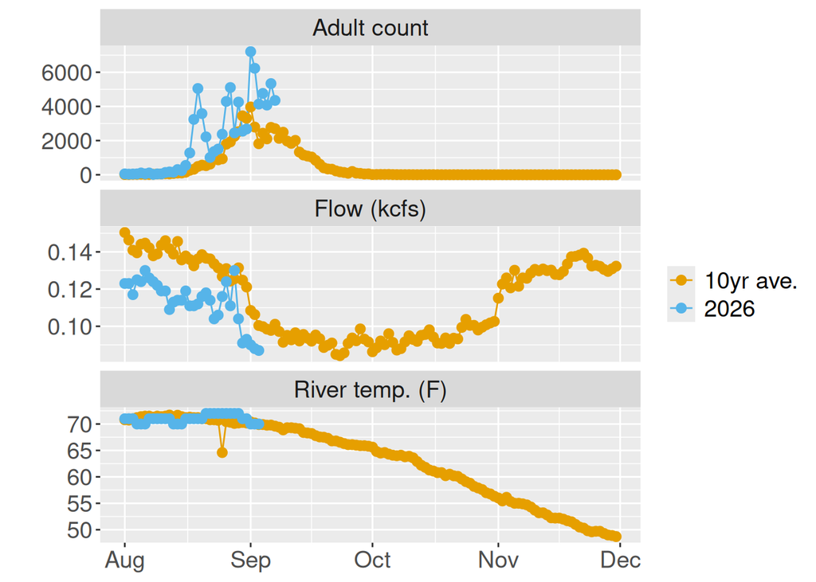

Daily adult Chinook salmon counts, flow, and temperature measurements taken at Bonneville Dam.

###### Percent complete

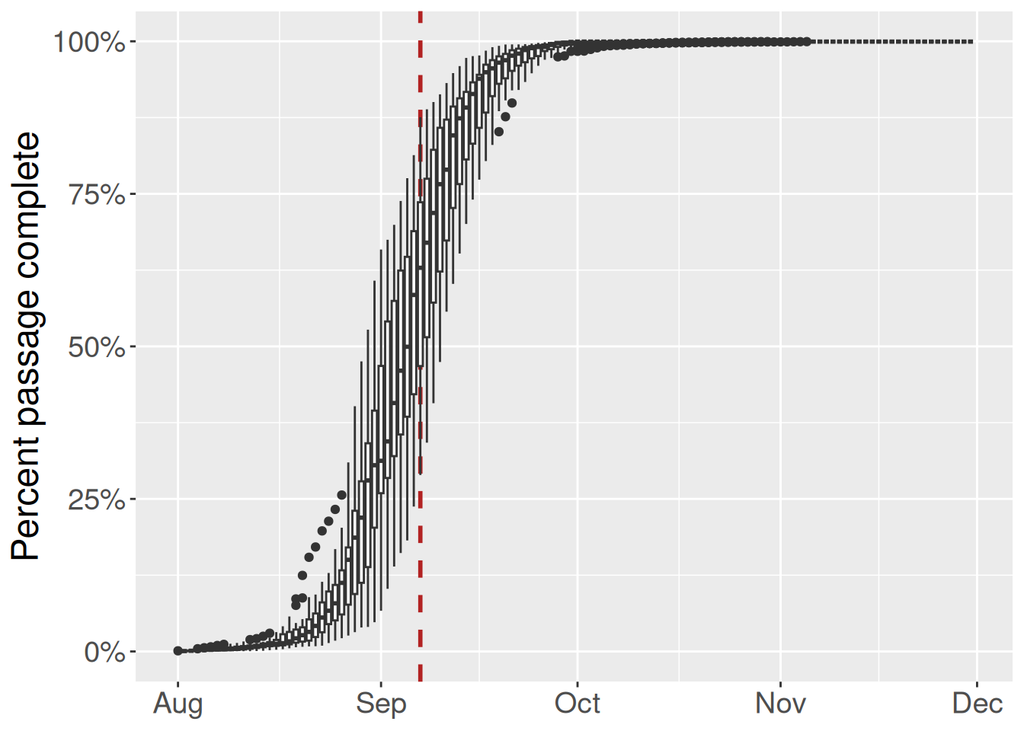

**Percent of the run complete by date in 2011–2025**. Lower and upper hinges correspond to the first and third quartiles (the 25th and 75th percentiles).The upper whisker extends from the hinge to the largest value no further than 1.5 * IQR from the hinge (where IQR is the inter-quartile range, or distance between the first and third quartiles). The lower whisker extends from the hinge to the smallest value at most 1.5 * IQR of the hinge. Data beyond the end of the whiskers are called "outlying" points and are plotted individually.

###### Prediction error

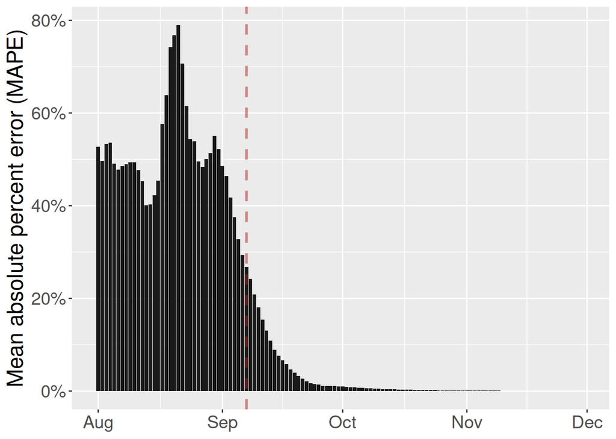

Mean absolute percent error (over 15 year retrospectiv) of predictions based on cumulative counts and 10-year average run timing, by day of year.

##### Run size predictions

###### Prediction table

| Model | Pred | Lo 95 | Lo 50 | Hi 50 | Hi 95 | MAPE |
| --- | --- | --- | --- | --- | --- | --- |
| DLM | 106,701 | 53,911 | 84,360 | 134,959 | 211,185 | 31% |
| ARIMA | 97,846 | 47,538 | 76,187 | 125,936 | 205,171 | 27% |
| 10-year ave. timing | 120,116 | 88,033 | 102,611 | 151,896 | 301,602 | 27% |
| 5-year ave. timing | 112,345 | 86,552 | 98,214 | 138,172 | 261,138 | 29% |

###### Prediction plot

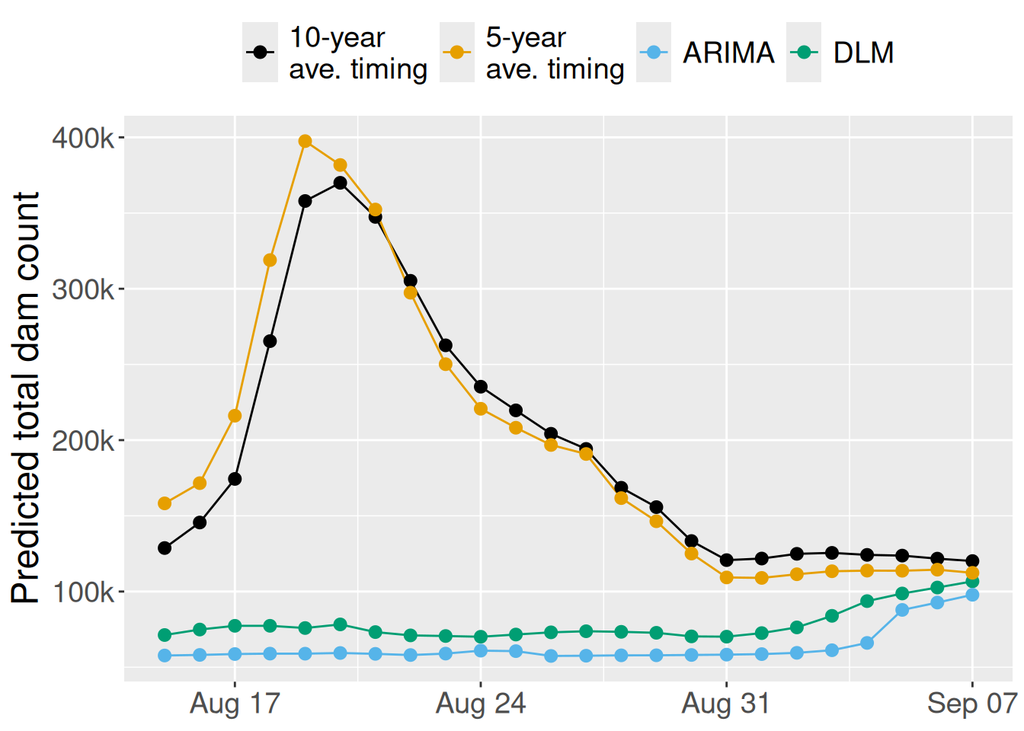

Daily predictions of total counts at Bonneville from different models.

###### Prediction interval plot

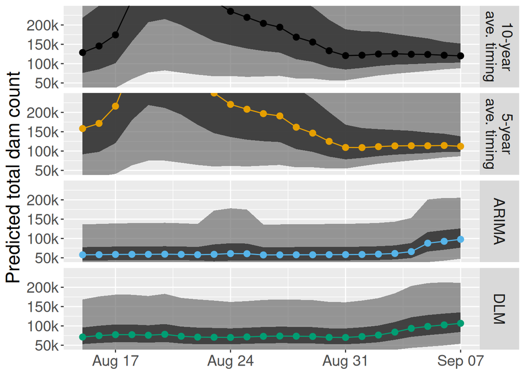

Daily predictions and prediction intervals (95% and 50%). Prediction intervals for different model types are calculated using different methods, so may not be directly comparable. See Methods Description for more details.

###### Covariate effects

Fitted coefficients, covariate values, and effects (coefficient * covariate) for the DLM and ARIMA models. Covariates are the log of the jack returns in the previous years, the log of the cumulative adult counts to date, and an interaction between the cumulative counts and a moving average of river discharge.

| Model<sup>1</sup> | coef intercept | coef log lag jack | coef log cum cnt | coef cnt by flow | covar log lag jack | covar log cum cnt | covar cnt by flow | effect log lag jack | effect log cum cnt | effect cnt by flow |
| --- | --- | --- | --- | --- | --- | --- | --- | --- | --- | --- |
| DLM | −0.31 | 0.30 | 0.63 | 0.05 | 1.26 | 1.26 | NA | 0.38 | 0.79 | NA |
| ARIMA | 7.11 | 0.22 | 0.34 | 0.05 | 1.26 | 1.30 | −0.78 | 0.28 | 0.44 | −0.04 |

<sup>1</sup> The response and the covariates are z-scored before fitting the DLM, but the response is not standardized for the ARIMA model

[output not shown]

###### Methods description

DLM

This is a penalized dynamic linear model fit with the [`Sibregresr` package](https://dfw-wa.github.io/sibregresr/articles/Overview.html). The coefficients are the:

1. log-transformed total count of jacks at Bonneville Dam in the *previous* year,
2. log-transformed cumulative adult count at Bonneville Dam in the *current* year,
3. and interaction between an exponential moving average of river discharge and the cumulative adult count.

The prediction interval is based on the standard deviation (in log-space) of forecasts from a 15-year retrospective. In other words, the root mean square error of the forecast error in log space from a 15-year retrospective is used as the standard deviation in a lognormal prediction interval.

ARIMA

This is an ensemble of ARIMA models fit with the [`SalmonForecasting` package](https://github.com/wdfw-fp/salmonforecast) (see README at the linked page for details). The covariates are the same as those described above for the DLM. Prediction intervals are the weighted average of the prediction intervals provided by the `forecast::forecast()` function in `R`.

Joint likelihood

This is a version of a model that has been used for this purpose of in-season forecasting for several years. The proportion of the run that is complete on a given day is modeled with autoregressive (order 1) errors and an effect of the river discharge covariate. The pre-season forecast is generated using an age-specific sibling regression. I have not yet implemented a retrospective assessment of performance because, in this version, the pre-season forecasts and prediction uncertainty need to be provided, and I have not pulled in the past 15 years’ forecasts.

10 year average run timing

This method takes the 10-year average of the proportion of the run that was complete on a given day and uses it to expand the cumulative counts to date. Performance and prediction intervals are based on a 15-year retrospective as described above for the DLM but assuming a normal prediction distribution for the proportion complete in logit space.

##### Average timing info

###### 10-year average

Prediction

| Date | Daily counts | Cumulative count | 10 Days Early | 9 Days Early | 8 Days Early | 7 Days Early | 6 Days Early | 5 Days Early | 4 Days Early | 3 Days Early | 2 Days Early | 1 Days Early | 10yr Average | 1 Days Late | 2 Days Late | 3 Days Late | 4 Days Late | 5 Days Late | 6 Days Late | 7 Days Late | 8 Days Late | 9 Days Late | 10 Days Late |
| --- | --- | --- | --- | --- | --- | --- | --- | --- | --- | --- | --- | --- | --- | --- | --- | --- | --- | --- | --- | --- | --- | --- | --- |
| 07-Sep | 4,350 | 81,143 | 86,635 | 88,002 | 89,825 | 91,650 | 93,912 | 96,601 | 100,611 | 104,816 | 109,066 | 114,771 | 120,116 | 128,611 | 140,485 | 149,574 | 162,667 | 173,292 | 189,132 | 217,519 | 255,431 | 317,453 | 384,614 |
| 06-Sep | 5,337 | 76,793 | 83,284 | 85,009 | 86,736 | 88,877 | 91,422 | 95,217 | 99,196 | 103,219 | 108,618 | 113,676 | 121,715 | 132,953 | 141,555 | 153,945 | 164,001 | 178,992 | 205,857 | 241,736 | 300,433 | 363,993 | 450,375 |
| 05-Sep | 4,078 | 71,456 | 79,101 | 80,709 | 82,701 | 85,069 | 88,600 | 92,303 | 96,046 | 101,070 | 105,776 | 113,257 | 123,714 | 131,718 | 143,247 | 152,604 | 166,553 | 191,551 | 224,937 | 279,554 | 338,697 | 419,077 | 521,030 |
| 04-Sep | 4,762 | 67,378 | 76,103 | 77,981 | 80,213 | 83,543 | 87,035 | 90,564 | 95,301 | 99,739 | 106,793 | 116,653 | 124,200 | 135,071 | 143,894 | 157,047 | 180,619 | 212,099 | 263,599 | 319,367 | 395,159 | 491,293 | 624,096 |
| 03-Sep | 4,137 | 62,616 | 72,469 | 74,544 | 77,638 | 80,883 | 84,163 | 88,565 | 92,690 | 99,245 | 108,408 | 115,422 | 125,525 | 133,724 | 145,947 | 167,853 | 197,108 | 244,969 | 296,795 | 367,230 | 456,570 | 579,986 | 690,351 |
| 02-Sep | 6,232 | 58,479 | 69,619 | 72,509 | 75,540 | 78,603 | 82,715 | 86,566 | 92,689 | 101,246 | 107,797 | 117,232 | 124,890 | 136,306 | 156,764 | 184,087 | 228,785 | 277,188 | 342,969 | 426,408 | 541,670 | 644,744 | 774,145 |
| 01-Sep | 7,207 | 52,248 | 64,782 | 67,490 | 70,227 | 73,900 | 77,342 | 82,811 | 90,457 | 96,310 | 104,740 | 111,581 | 121,780 | 140,059 | 164,470 | 204,405 | 247,650 | 306,421 | 380,968 | 483,948 | 576,038 | 691,649 | 862,953 |
| 31-Aug | 2,681 | 45,040 | 58,180 | 60,539 | 63,706 | 66,672 | 71,388 | 77,979 | 83,024 | 90,291 | 96,189 | 104,981 | 120,738 | 141,781 | 176,208 | 213,487 | 264,151 | 328,414 | 417,188 | 496,574 | 596,237 | 743,910 | 895,810 |
| 30-Aug | 2,550 | 42,359 | 56,936 | 59,914 | 62,704 | 67,139 | 73,337 | 78,082 | 84,917 | 90,463 | 98,732 | 113,551 | 133,342 | 165,720 | 200,780 | 248,429 | 308,867 | 392,357 | 467,018 | 560,749 | 699,632 | 842,491 | 1,027,581 |
| 29-Aug | 4,253 | 39,809 | 56,307 | 58,930 | 63,097 | 68,923 | 73,382 | 79,805 | 85,018 | 92,789 | 106,716 | 125,316 | 155,744 | 188,694 | 233,475 | 290,275 | 368,739 | 438,906 | 526,995 | 657,518 | 791,777 | 965,726 | 1,220,870 |
| 28-Aug | 2,447 | 35,556 | 52,633 | 56,356 | 61,559 | 65,542 | 71,279 | 75,934 | 82,875 | 95,314 | 111,927 | 139,104 | 168,533 | 208,529 | 259,261 | 329,342 | 392,012 | 470,689 | 587,267 | 707,182 | 862,545 | 1,090,429 | 1,424,844 |
| 27-Aug | 5,106 | 33,109 | 52,477 | 57,322 | 61,031 | 66,373 | 70,708 | 77,171 | 88,754 | 104,223 | 129,530 | 156,934 | 194,177 | 241,417 | 306,675 | 365,032 | 438,294 | 546,848 | 658,510 | 803,180 | 1,015,380 | 1,326,778 | 1,707,069 |
| 26-Aug | 4,289 | 28,003 | 48,483 | 51,620 | 56,138 | 59,805 | 65,271 | 75,068 | 88,152 | 109,556 | 132,734 | 164,234 | 204,189 | 259,384 | 308,742 | 370,706 | 462,521 | 556,964 | 679,325 | 858,802 | 1,122,181 | 1,443,829 | 1,938,048 |
| 25-Aug | 2,373 | 23,714 | 43,713 | 47,539 | 50,645 | 55,274 | 63,570 | 74,650 | 92,776 | 112,404 | 139,079 | 172,915 | 219,655 | 261,454 | 313,927 | 391,679 | 471,657 | 575,277 | 727,265 | 950,303 | 1,222,686 | 1,641,208 | 1,959,648 |
| 24-Aug | 1,503 | 21,341 | 42,782 | 45,576 | 49,742 | 57,208 | 67,179 | 83,491 | 101,154 | 125,160 | 155,610 | 197,673 | 235,288 | 282,510 | 352,480 | 424,454 | 517,704 | 654,481 | 855,198 | 1,100,321 | 1,476,958 | 1,763,528 | 2,100,270 |
| 23-Aug | 1,357 | 19,838 | 42,367 | 46,240 | 53,180 | 62,449 | 77,612 | 94,032 | 116,348 | 144,653 | 183,754 | 218,720 | 262,618 | 327,662 | 394,567 | 481,251 | 608,397 | 794,982 | 1,022,845 | 1,372,962 | 1,639,355 | 1,952,386 | 2,409,681 |
| 22-Aug | 1,011 | 18,481 | 43,076 | 49,541 | 58,176 | 72,302 | 87,598 | 108,387 | 134,755 | 171,181 | 203,755 | 244,648 | 305,241 | 367,569 | 448,322 | 566,768 | 740,586 | 952,858 | 1,279,018 | 1,527,183 | 1,818,795 | 2,244,801 | 2,706,957 |
| 21-Aug | 2,218 | 17,470 | 46,830 | 54,992 | 68,345 | 82,804 | 102,455 | 127,381 | 161,813 | 192,605 | 231,261 | 288,538 | 347,455 | 423,788 | 535,753 | 700,059 | 900,715 | 1,209,027 | 1,443,612 | 1,719,266 | 2,121,959 | 2,558,826 | 2,969,985 |
| 20-Aug | 3,579 | 15,251 | 48,009 | 59,666 | 72,289 | 89,445 | 111,205 | 141,265 | 168,146 | 201,894 | 251,897 | 303,333 | 369,973 | 467,720 | 611,161 | 786,336 | 1,055,497 | 1,260,292 | 1,500,942 | 1,852,499 | 2,233,889 | 2,592,836 | 3,200,221 |
| 19-Aug | 5,049 | 11,672 | 45,663 | 55,324 | 68,453 | 85,107 | 108,112 | 128,684 | 154,511 | 192,780 | 232,144 | 283,144 | 357,951 | 467,728 | 601,791 | 807,783 | 964,515 | 1,148,687 | 1,417,737 | 1,709,619 | 1,984,325 | 2,449,163 | 2,852,200 |
| 18-Aug | 3,241 | 6,623 | 31,391 | 38,841 | 48,290 | 61,343 | 73,016 | 87,670 | 109,384 | 131,719 | 160,657 | 203,102 | 265,390 | 341,458 | 458,339 | 547,269 | 651,769 | 804,429 | 970,043 | 1,125,913 | 1,389,663 | 1,618,348 | 1,940,344 |
| 17-Aug | 1,278 | 3,382 | 19,834 | 24,659 | 31,325 | 37,286 | 44,769 | 55,857 | 67,263 | 82,040 | 103,715 | 135,523 | 174,367 | 234,053 | 279,465 | 332,829 | 410,785 | 495,357 | 574,953 | 709,638 | 826,417 | 990,846 | 1,158,539 |
| 16-Aug | 546 | 2,104 | 15,339 | 19,485 | 23,193 | 27,847 | 34,744 | 41,839 | 51,031 | 64,513 | 84,298 | 108,460 | 145,585 | 173,833 | 207,026 | 255,516 | 308,121 | 357,631 | 441,408 | 514,047 | 616,325 | 720,633 | 855,768 |
| 15-Aug | 240 | 1,558 | 14,428 | 17,173 | 20,620 | 25,727 | 30,980 | 37,787 | 47,770 | 62,420 | 80,311 | 107,801 | 128,718 | 153,296 | 189,202 | 228,155 | 264,815 | 326,849 | 380,636 | 456,369 | 533,607 | 633,670 | 769,488 |
| 14-Aug | 304 | 1,318 | 14,528 | 17,444 | 21,765 | 26,209 | 31,967 | 40,413 | 52,806 | 67,942 | 91,199 | 108,894 | 129,687 | 160,063 | 193,016 | 224,030 | 276,510 | 322,013 | 386,083 | 451,425 | 536,077 | 650,978 | 853,987 |
| 13-Aug | 146 | 1,013 | 13,414 | 16,736 | 20,154 | 24,581 | 31,075 | 40,606 | 52,244 | 70,128 | 83,734 | 99,723 | 123,081 | 148,420 | 172,269 | 212,624 | 247,613 | 296,880 | 347,125 | 412,219 | 500,572 | 656,677 | 870,353 |
| 12-Aug | 166 | 867 | 14,324 | 17,249 | 21,039 | 26,597 | 34,754 | 44,715 | 60,021 | 71,667 | 85,352 | 105,343 | 127,031 | 147,443 | 181,982 | 211,930 | 254,096 | 297,100 | 352,813 | 428,434 | 562,043 | 744,925 | 1,245,190 |
| 11-Aug | 134 | 701 | 13,950 | 17,015 | 21,510 | 28,107 | 36,164 | 48,542 | 57,961 | 69,028 | 85,197 | 102,737 | 119,245 | 147,178 | 171,398 | 205,501 | 240,280 | 285,338 | 346,496 | 454,552 | 602,459 | 1,007,048 | 1,557,446 |
| 10-Aug | 50 | 568 | 13,776 | 17,416 | 22,757 | 29,279 | 39,302 | 46,927 | 55,888 | 68,978 | 83,179 | 96,544 | 119,160 | 138,770 | 166,380 | 194,539 | 231,019 | 280,535 | 368,021 | 487,771 | 815,339 | 1,260,959 | NA |
| 09-Aug | 50 | 518 | 15,883 | 20,754 | 26,702 | 35,843 | 42,797 | 50,969 | 62,907 | 75,859 | 88,048 | 108,673 | 126,557 | 151,737 | 177,418 | 210,687 | 255,845 | 335,632 | 444,843 | 743,583 | 1,149,984 | NA | NA |
| 08-Aug | 23 | 468 | 18,750 | 24,125 | 32,382 | 38,665 | 46,048 | 56,834 | 68,535 | 79,547 | 98,182 | 114,338 | 137,088 | 160,289 | 190,347 | 231,145 | 303,228 | 401,896 | 671,794 | 1,038,960 | NA | NA | NA |
| 07-Aug | 104 | 445 | 22,933 | 30,783 | 36,755 | 43,774 | 54,027 | 65,150 | 75,618 | 93,332 | 108,691 | 130,317 | 152,372 | 180,945 | 219,728 | 288,251 | 382,044 | 638,611 | 987,641 | NA | NA | NA | NA |
| 06-Aug | 54 | 341 | 23,585 | 28,161 | 33,538 | 41,393 | 49,915 | 57,936 | 71,508 | 83,275 | 99,844 | 116,742 | 138,634 | 168,348 | 220,848 | 292,709 | 489,282 | 756,697 | NA | NA | NA | NA | NA |
| 05-Aug | 104 | 287 | 23,693 | 28,217 | 34,826 | 41,996 | 48,744 | 60,163 | 70,063 | 84,003 | 98,220 | 116,639 | 141,638 | 185,809 | 246,269 | 411,654 | 636,642 | NA | NA | NA | NA | NA | NA |
| 04-Aug | 51 | 182 | 17,942 | 22,144 | 26,703 | 30,994 | 38,255 | 44,550 | 53,414 | 62,454 | 74,165 | 90,062 | 118,147 | 156,591 | 261,752 | 404,812 | NA | NA | NA | NA | NA | NA | NA |
| 03-Aug | 44 | 131 | 15,958 | 19,243 | 22,335 | 27,568 | 32,104 | 38,492 | 45,006 | 53,446 | 64,901 | 85,141 | 112,845 | 188,627 | 291,720 | NA | NA | NA | NA | NA | NA | NA | NA |
| 02-Aug | 36 | 88 | 12,819 | 14,878 | 18,364 | 21,386 | 25,641 | 29,980 | 35,602 | 43,233 | 56,715 | 75,170 | 125,651 | 194,326 | NA | NA | NA | NA | NA | NA | NA | NA | NA |
| 01-Aug | 52 | 52 | 8,804 | 10,867 | 12,655 | 15,173 | 17,741 | 21,068 | 25,584 | 33,562 | 44,483 | 74,355 | 114,994 | NA | NA | NA | NA | NA | NA | NA | NA | NA | NA |

Proportion complete

| Date | 10 Days Early | 9 Days Early | 8 Days Early | 7 Days Early | 6 Days Early | 5 Days Early | 4 Days Early | 3 Days Early | 2 Days Early | 1 Days Early | 10yr Average | 1 Days Late | 2 Days Late | 3 Days Late | 4 Days Late | 5 Days Late | 6 Days Late | 7 Days Late | 8 Days Late | 9 Days Late | 10 Days Late |
| --- | --- | --- | --- | --- | --- | --- | --- | --- | --- | --- | --- | --- | --- | --- | --- | --- | --- | --- | --- | --- | --- |
| 30-Nov | NA | NA | NA | NA | NA | NA | NA | NA | NA | NA | 1.00 | 1.00 | 1.00 | 1.00 | 1.00 | 1.00 | 1.00 | 1.00 | 1.00 | 1.00 | 1.00 |
| 29-Nov | NA | NA | NA | NA | NA | NA | NA | NA | NA | 1.00 | 1.00 | 1.00 | 1.00 | 1.00 | 1.00 | 1.00 | 1.00 | 1.00 | 1.00 | 1.00 | 1.00 |
| 28-Nov | NA | NA | NA | NA | NA | NA | NA | NA | 1.00 | 1.00 | 1.00 | 1.00 | 1.00 | 1.00 | 1.00 | 1.00 | 1.00 | 1.00 | 1.00 | 1.00 | 1.00 |
| 27-Nov | NA | NA | NA | NA | NA | NA | NA | 1.00 | 1.00 | 1.00 | 1.00 | 1.00 | 1.00 | 1.00 | 1.00 | 1.00 | 1.00 | 1.00 | 1.00 | 1.00 | 1.00 |
| 26-Nov | NA | NA | NA | NA | NA | NA | 1.00 | 1.00 | 1.00 | 1.00 | 1.00 | 1.00 | 1.00 | 1.00 | 1.00 | 1.00 | 1.00 | 1.00 | 1.00 | 1.00 | 1.00 |
| 25-Nov | NA | NA | NA | NA | NA | 1.00 | 1.00 | 1.00 | 1.00 | 1.00 | 1.00 | 1.00 | 1.00 | 1.00 | 1.00 | 1.00 | 1.00 | 1.00 | 1.00 | 1.00 | 1.00 |
| 24-Nov | NA | NA | NA | NA | 1.00 | 1.00 | 1.00 | 1.00 | 1.00 | 1.00 | 1.00 | 1.00 | 1.00 | 1.00 | 1.00 | 1.00 | 1.00 | 1.00 | 1.00 | 1.00 | 1.00 |
| 23-Nov | NA | NA | NA | 1.00 | 1.00 | 1.00 | 1.00 | 1.00 | 1.00 | 1.00 | 1.00 | 1.00 | 1.00 | 1.00 | 1.00 | 1.00 | 1.00 | 1.00 | 1.00 | 1.00 | 1.00 |
| 22-Nov | NA | NA | 1.00 | 1.00 | 1.00 | 1.00 | 1.00 | 1.00 | 1.00 | 1.00 | 1.00 | 1.00 | 1.00 | 1.00 | 1.00 | 1.00 | 1.00 | 1.00 | 1.00 | 1.00 | 1.00 |
| 21-Nov | NA | 1.00 | 1.00 | 1.00 | 1.00 | 1.00 | 1.00 | 1.00 | 1.00 | 1.00 | 1.00 | 1.00 | 1.00 | 1.00 | 1.00 | 1.00 | 1.00 | 1.00 | 1.00 | 1.00 | 1.00 |
| 20-Nov | 1.00 | 1.00 | 1.00 | 1.00 | 1.00 | 1.00 | 1.00 | 1.00 | 1.00 | 1.00 | 1.00 | 1.00 | 1.00 | 1.00 | 1.00 | 1.00 | 1.00 | 1.00 | 1.00 | 1.00 | 1.00 |
| 19-Nov | 1.00 | 1.00 | 1.00 | 1.00 | 1.00 | 1.00 | 1.00 | 1.00 | 1.00 | 1.00 | 1.00 | 1.00 | 1.00 | 1.00 | 1.00 | 1.00 | 1.00 | 1.00 | 1.00 | 1.00 | 1.00 |
| 18-Nov | 1.00 | 1.00 | 1.00 | 1.00 | 1.00 | 1.00 | 1.00 | 1.00 | 1.00 | 1.00 | 1.00 | 1.00 | 1.00 | 1.00 | 1.00 | 1.00 | 1.00 | 1.00 | 1.00 | 1.00 | 1.00 |
| 17-Nov | 1.00 | 1.00 | 1.00 | 1.00 | 1.00 | 1.00 | 1.00 | 1.00 | 1.00 | 1.00 | 1.00 | 1.00 | 1.00 | 1.00 | 1.00 | 1.00 | 1.00 | 1.00 | 1.00 | 1.00 | 1.00 |
| 16-Nov | 1.00 | 1.00 | 1.00 | 1.00 | 1.00 | 1.00 | 1.00 | 1.00 | 1.00 | 1.00 | 1.00 | 1.00 | 1.00 | 1.00 | 1.00 | 1.00 | 1.00 | 1.00 | 1.00 | 1.00 | 1.00 |
| 15-Nov | 1.00 | 1.00 | 1.00 | 1.00 | 1.00 | 1.00 | 1.00 | 1.00 | 1.00 | 1.00 | 1.00 | 1.00 | 1.00 | 1.00 | 1.00 | 1.00 | 1.00 | 1.00 | 1.00 | 1.00 | 1.00 |
| 14-Nov | 1.00 | 1.00 | 1.00 | 1.00 | 1.00 | 1.00 | 1.00 | 1.00 | 1.00 | 1.00 | 1.00 | 1.00 | 1.00 | 1.00 | 1.00 | 1.00 | 1.00 | 1.00 | 1.00 | 1.00 | 1.00 |
| 13-Nov | 1.00 | 1.00 | 1.00 | 1.00 | 1.00 | 1.00 | 1.00 | 1.00 | 1.00 | 1.00 | 1.00 | 1.00 | 1.00 | 1.00 | 1.00 | 1.00 | 1.00 | 1.00 | 1.00 | 1.00 | 1.00 |
| 12-Nov | 1.00 | 1.00 | 1.00 | 1.00 | 1.00 | 1.00 | 1.00 | 1.00 | 1.00 | 1.00 | 1.00 | 1.00 | 1.00 | 1.00 | 1.00 | 1.00 | 1.00 | 1.00 | 1.00 | 1.00 | 1.00 |
| 11-Nov | 1.00 | 1.00 | 1.00 | 1.00 | 1.00 | 1.00 | 1.00 | 1.00 | 1.00 | 1.00 | 1.00 | 1.00 | 1.00 | 1.00 | 1.00 | 1.00 | 1.00 | 1.00 | 1.00 | 1.00 | 1.00 |
| 10-Nov | 1.00 | 1.00 | 1.00 | 1.00 | 1.00 | 1.00 | 1.00 | 1.00 | 1.00 | 1.00 | 1.00 | 1.00 | 1.00 | 1.00 | 1.00 | 1.00 | 1.00 | 1.00 | 1.00 | 1.00 | 1.00 |
| 09-Nov | 1.00 | 1.00 | 1.00 | 1.00 | 1.00 | 1.00 | 1.00 | 1.00 | 1.00 | 1.00 | 1.00 | 1.00 | 1.00 | 1.00 | 1.00 | 1.00 | 1.00 | 1.00 | 1.00 | 1.00 | 1.00 |
| 08-Nov | 1.00 | 1.00 | 1.00 | 1.00 | 1.00 | 1.00 | 1.00 | 1.00 | 1.00 | 1.00 | 1.00 | 1.00 | 1.00 | 1.00 | 1.00 | 1.00 | 1.00 | 1.00 | 1.00 | 1.00 | 1.00 |
| 07-Nov | 1.00 | 1.00 | 1.00 | 1.00 | 1.00 | 1.00 | 1.00 | 1.00 | 1.00 | 1.00 | 1.00 | 1.00 | 1.00 | 1.00 | 1.00 | 1.00 | 1.00 | 1.00 | 1.00 | 1.00 | 1.00 |
| 06-Nov | 1.00 | 1.00 | 1.00 | 1.00 | 1.00 | 1.00 | 1.00 | 1.00 | 1.00 | 1.00 | 1.00 | 1.00 | 1.00 | 1.00 | 1.00 | 1.00 | 1.00 | 1.00 | 1.00 | 1.00 | 1.00 |
| 05-Nov | 1.00 | 1.00 | 1.00 | 1.00 | 1.00 | 1.00 | 1.00 | 1.00 | 1.00 | 1.00 | 1.00 | 1.00 | 1.00 | 1.00 | 1.00 | 1.00 | 1.00 | 1.00 | 1.00 | 1.00 | 1.00 |
| 04-Nov | 1.00 | 1.00 | 1.00 | 1.00 | 1.00 | 1.00 | 1.00 | 1.00 | 1.00 | 1.00 | 1.00 | 1.00 | 1.00 | 1.00 | 1.00 | 1.00 | 1.00 | 1.00 | 1.00 | 1.00 | 1.00 |
| 03-Nov | 1.00 | 1.00 | 1.00 | 1.00 | 1.00 | 1.00 | 1.00 | 1.00 | 1.00 | 1.00 | 1.00 | 1.00 | 1.00 | 1.00 | 1.00 | 1.00 | 1.00 | 1.00 | 1.00 | 1.00 | 1.00 |
| 02-Nov | 1.00 | 1.00 | 1.00 | 1.00 | 1.00 | 1.00 | 1.00 | 1.00 | 1.00 | 1.00 | 1.00 | 1.00 | 1.00 | 1.00 | 1.00 | 1.00 | 1.00 | 1.00 | 1.00 | 1.00 | 1.00 |
| 01-Nov | 1.00 | 1.00 | 1.00 | 1.00 | 1.00 | 1.00 | 1.00 | 1.00 | 1.00 | 1.00 | 1.00 | 1.00 | 1.00 | 1.00 | 1.00 | 1.00 | 1.00 | 1.00 | 1.00 | 1.00 | 1.00 |

[output cut: 92 more lines]

###### 5-year average

Prediction

| Date | Daily counts | Cumulative count | 10 Days Early | 9 Days Early | 8 Days Early | 7 Days Early | 6 Days Early | 5 Days Early | 4 Days Early | 3 Days Early | 2 Days Early | 1 Days Early | 5yr Average | 1 Days Late | 2 Days Late | 3 Days Late | 4 Days Late | 5 Days Late | 6 Days Late | 7 Days Late | 8 Days Late | 9 Days Late | 10 Days Late |
| --- | --- | --- | --- | --- | --- | --- | --- | --- | --- | --- | --- | --- | --- | --- | --- | --- | --- | --- | --- | --- | --- | --- | --- |
| 07-Sep | 4,350 | 81,143 | 84,073 | 85,246 | 86,620 | 88,307 | 89,965 | 91,970 | 95,169 | 98,527 | 102,206 | 107,358 | 112,345 | 120,908 | 129,137 | 137,033 | 146,938 | 154,586 | 169,256 | 196,917 | 239,568 | 298,419 | 369,020 |
| 06-Sep | 5,337 | 76,793 | 80,676 | 81,976 | 83,572 | 85,142 | 87,039 | 90,067 | 93,245 | 96,726 | 101,602 | 106,322 | 114,426 | 122,213 | 129,686 | 139,060 | 146,298 | 160,181 | 186,359 | 226,724 | 282,419 | 349,235 | 442,637 |
| 05-Sep | 4,078 | 71,456 | 76,279 | 77,765 | 79,225 | 80,990 | 83,808 | 86,765 | 90,004 | 94,541 | 98,933 | 106,474 | 113,720 | 120,674 | 129,397 | 136,131 | 149,050 | 173,409 | 210,968 | 262,793 | 324,965 | 411,876 | 502,178 |
| 04-Sep | 4,762 | 67,378 | 73,326 | 74,703 | 76,368 | 79,025 | 81,813 | 84,868 | 89,145 | 93,286 | 100,397 | 107,230 | 113,787 | 122,011 | 128,362 | 140,543 | 163,512 | 198,927 | 247,794 | 306,418 | 388,369 | 473,517 | 591,498 |
| 03-Sep | 4,137 | 62,616 | 69,423 | 70,970 | 73,439 | 76,030 | 78,869 | 82,845 | 86,693 | 93,301 | 99,651 | 105,745 | 113,388 | 119,289 | 130,610 | 151,955 | 184,868 | 230,281 | 284,761 | 360,920 | 440,050 | 549,692 | 647,608 |
| 02-Sep | 6,232 | 58,479 | 66,282 | 68,588 | 71,008 | 73,659 | 77,372 | 80,966 | 87,138 | 93,068 | 98,759 | 105,897 | 111,409 | 121,981 | 141,916 | 172,655 | 215,068 | 265,949 | 337,076 | 410,979 | 513,378 | 604,826 | 737,410 |
| 01-Sep | 7,207 | 52,248 | 61,279 | 63,441 | 65,810 | 69,127 | 72,338 | 77,852 | 83,150 | 88,235 | 94,612 | 99,537 | 108,983 | 126,793 | 154,256 | 192,149 | 237,609 | 301,156 | 367,183 | 458,671 | 540,373 | 658,829 | 840,697 |
| 31-Aug | 2,681 | 45,040 | 54,689 | 56,731 | 59,591 | 62,359 | 67,112 | 71,680 | 76,063 | 81,561 | 85,806 | 93,949 | 109,302 | 132,977 | 165,643 | 204,831 | 259,612 | 316,531 | 395,398 | 465,829 | 567,945 | 724,723 | 908,361 |
| 30-Aug | 2,550 | 42,359 | 53,355 | 56,044 | 58,647 | 63,118 | 67,413 | 71,536 | 76,706 | 80,699 | 88,357 | 102,797 | 125,062 | 155,784 | 192,639 | 244,160 | 297,691 | 371,864 | 438,103 | 534,141 | 681,588 | 854,296 | 1,060,271 |
| 29-Aug | 4,253 | 39,809 | 52,670 | 55,117 | 59,318 | 63,355 | 67,229 | 72,089 | 75,841 | 83,038 | 96,609 | 117,534 | 146,406 | 181,043 | 229,463 | 279,772 | 349,479 | 411,732 | 501,988 | 640,560 | 802,871 | 996,448 | 1,355,793 |
| 28-Aug | 2,447 | 35,556 | 49,228 | 52,981 | 56,586 | 60,046 | 64,387 | 67,738 | 74,166 | 86,287 | 104,976 | 130,764 | 161,700 | 204,946 | 249,880 | 312,140 | 367,741 | 448,354 | 572,120 | 717,090 | 889,984 | 1,210,937 | 1,712,287 |
| 27-Aug | 5,106 | 33,109 | 49,334 | 52,692 | 55,914 | 59,955 | 63,076 | 69,062 | 80,348 | 97,751 | 121,764 | 150,571 | 190,841 | 232,682 | 290,657 | 342,431 | 417,496 | 532,744 | 667,736 | 828,731 | 1,127,594 | 1,594,438 | 2,115,951 |
| 26-Aug | 4,289 | 28,003 | 44,566 | 47,292 | 50,710 | 53,349 | 58,412 | 67,958 | 82,677 | 102,987 | 127,352 | 161,412 | 196,801 | 245,836 | 289,626 | 353,116 | 450,592 | 564,767 | 700,936 | 953,712 | 1,348,567 | 1,789,659 | 2,284,175 |
| 25-Aug | 2,373 | 23,714 | 40,048 | 42,943 | 45,178 | 49,465 | 57,549 | 70,014 | 87,213 | 107,846 | 136,690 | 166,658 | 208,183 | 245,266 | 299,031 | 381,577 | 478,265 | 593,577 | 807,637 | 1,142,014 | 1,515,547 | 1,934,321 | 2,408,810 |
| 24-Aug | 1,503 | 21,341 | 38,645 | 40,657 | 44,515 | 51,790 | 63,007 | 78,485 | 97,053 | 123,010 | 149,979 | 187,348 | 220,720 | 269,104 | 343,389 | 430,401 | 534,173 | 726,810 | 1,027,723 | 1,363,873 | 1,740,736 | 2,167,739 | 2,538,348 |
| 23-Aug | 1,357 | 19,838 | 37,794 | 41,380 | 48,143 | 58,571 | 72,959 | 90,220 | 114,348 | 139,419 | 174,156 | 205,179 | 250,156 | 319,211 | 400,095 | 496,561 | 675,634 | 955,359 | 1,267,840 | 1,618,167 | 2,015,104 | 2,359,618 | 2,905,071 |
| 22-Aug | 1,011 | 18,481 | 38,549 | 44,849 | 54,563 | 67,967 | 84,046 | 106,524 | 129,879 | 162,240 | 191,139 | 233,039 | 297,369 | 372,719 | 462,584 | 629,404 | 889,989 | 1,181,089 | 1,507,445 | 1,877,222 | 2,198,163 | 2,706,294 | 3,235,071 |
| 21-Aug | 2,218 | 17,470 | 42,395 | 51,577 | 64,247 | 79,447 | 100,695 | 122,772 | 153,362 | 180,680 | 220,287 | 281,096 | 352,323 | 437,270 | 594,961 | 841,287 | 1,116,457 | 1,424,954 | 1,774,496 | 2,077,874 | 2,558,199 | 3,058,040 | 3,596,520 |
| 20-Aug | 3,579 | 15,251 | 45,028 | 56,089 | 69,358 | 87,908 | 107,181 | 133,887 | 157,736 | 192,313 | 245,401 | 307,583 | 381,743 | 519,409 | 734,454 | 974,682 | 1,244,004 | 1,549,158 | 1,814,011 | 2,233,342 | 2,669,710 | 3,139,810 | 4,038,289 |
| 19-Aug | 5,049 | 11,672 | 42,925 | 53,081 | 67,277 | 82,027 | 102,465 | 120,717 | 147,179 | 187,808 | 235,396 | 292,152 | 397,509 | 562,086 | 745,934 | 952,049 | 1,185,587 | 1,388,282 | 1,709,200 | 2,043,157 | 2,402,930 | 3,090,545 | 3,868,113 |
| 18-Aug | 3,241 | 6,623 | 30,118 | 38,173 | 46,542 | 58,139 | 68,495 | 83,510 | 106,563 | 133,565 | 165,768 | 225,548 | 318,929 | 423,246 | 540,196 | 672,706 | 787,716 | 969,806 | 1,159,294 | 1,363,430 | 1,753,585 | 2,194,780 | 3,036,575 |
| 17-Aug | 1,278 | 3,382 | 19,493 | 23,767 | 29,689 | 34,977 | 42,645 | 54,417 | 68,205 | 84,650 | 115,177 | 162,863 | 216,132 | 275,854 | 343,521 | 402,251 | 495,236 | 591,999 | 696,242 | 895,477 | 1,120,775 | 1,550,642 | 1,908,968 |
| 16-Aug | 546 | 2,104 | 14,784 | 18,467 | 21,757 | 26,526 | 33,848 | 42,425 | 52,654 | 71,642 | 101,304 | 134,438 | 171,586 | 213,676 | 250,208 | 308,046 | 368,234 | 433,076 | 557,003 | 697,143 | 964,528 | 1,187,413 | 1,409,322 |
| 15-Aug | 240 | 1,558 | 13,674 | 16,110 | 19,642 | 25,064 | 31,414 | 38,989 | 53,049 | 75,012 | 99,547 | 127,054 | 158,221 | 185,271 | 228,099 | 272,666 | 320,679 | 412,444 | 516,213 | 714,203 | 879,243 | 1,043,560 | 1,307,456 |
| 14-Aug | 304 | 1,318 | 13,629 | 16,617 | 21,203 | 26,576 | 32,984 | 44,879 | 63,459 | 84,216 | 107,486 | 133,853 | 156,737 | 192,969 | 230,672 | 271,291 | 348,923 | 436,710 | 604,208 | 743,829 | 882,839 | 1,106,092 | 1,574,184 |
| 13-Aug | 146 | 1,013 | 12,777 | 16,305 | 20,436 | 25,363 | 34,510 | 48,797 | 64,758 | 82,652 | 102,927 | 120,524 | 148,384 | 177,376 | 208,610 | 268,305 | 335,810 | 464,608 | 571,971 | 678,863 | 850,534 | 1,210,475 | 1,784,371 |
| 12-Aug | 166 | 867 | 13,955 | 17,491 | 21,708 | 29,537 | 41,765 | 55,426 | 70,741 | 88,094 | 103,155 | 127,000 | 151,815 | 178,547 | 229,640 | 287,416 | 397,653 | 489,543 | 581,031 | 727,963 | 1,036,032 | 1,527,224 | 1,946,708 |
| 11-Aug | 134 | 701 | 14,146 | 17,556 | 23,888 | 33,778 | 44,826 | 57,212 | 71,246 | 83,427 | 102,712 | 122,780 | 144,400 | 185,721 | 232,448 | 321,602 | 395,919 | 469,909 | 588,740 | 837,892 | 1,235,143 | 1,574,401 | 1,753,504 |
| 10-Aug | 50 | 568 | 14,214 | 19,340 | 27,347 | 36,292 | 46,321 | 57,683 | 67,545 | 83,159 | 99,407 | 116,911 | 150,366 | 188,197 | 260,380 | 320,549 | 380,454 | 476,663 | 678,385 | 1,000,013 | 1,274,687 | 1,419,694 | NA |
| 09-Aug | 50 | 518 | 17,638 | 24,941 | 33,098 | 42,244 | 52,606 | 61,600 | 75,840 | 90,658 | 106,622 | 137,133 | 171,634 | 237,464 | 292,338 | 346,971 | 434,713 | 618,681 | 912,003 | 1,162,504 | 1,294,749 | NA | NA |
| 08-Aug | 23 | 468 | 22,533 | 29,903 | 38,166 | 47,528 | 55,653 | 68,518 | 81,906 | 96,328 | 123,893 | 155,064 | 214,538 | 264,114 | 313,473 | 392,744 | 558,951 | 823,955 | 1,050,271 | 1,169,749 | NA | NA | NA |
| 07-Aug | 104 | 445 | 28,426 | 36,280 | 45,180 | 52,904 | 65,134 | 77,860 | 91,570 | 117,774 | 147,405 | 203,941 | 251,068 | 297,989 | 373,345 | 531,342 | 783,256 | 998,394 | 1,111,970 | NA | NA | NA | NA |
| 06-Aug | 54 | 341 | 27,797 | 34,615 | 40,533 | 49,903 | 59,654 | 70,158 | 90,234 | 112,937 | 156,253 | 192,360 | 228,309 | 286,044 | 407,096 | 600,104 | 764,935 | 851,954 | NA | NA | NA | NA | NA |
| 05-Aug | 104 | 287 | 29,123 | 34,103 | 41,986 | 50,189 | 59,027 | 75,918 | 95,018 | 131,462 | 161,841 | 192,086 | 240,661 | 342,508 | 504,893 | 643,573 | 716,785 | NA | NA | NA | NA | NA | NA |
| 04-Aug | 51 | 182 | 21,684 | 26,697 | 31,913 | 37,533 | 48,273 | 60,418 | 83,591 | 102,907 | 122,139 | 153,026 | 217,785 | 321,039 | 409,219 | 455,772 | NA | NA | NA | NA | NA | NA | NA |
| 03-Aug | 44 | 131 | 19,239 | 22,998 | 27,047 | 34,787 | 43,539 | 60,238 | 74,158 | 88,017 | 110,275 | 156,943 | 231,351 | 294,896 | 328,444 | NA | NA | NA | NA | NA | NA | NA | NA |
| 02-Aug | 36 | 88 | 15,320 | 18,017 | 23,173 | 29,003 | 40,127 | 49,400 | 58,632 | 73,458 | 104,545 | 154,111 | 196,441 | 218,788 | NA | NA | NA | NA | NA | NA | NA | NA | NA |
| 01-Aug | 52 | 52 | 10,662 | 13,713 | 17,163 | 23,746 | 29,233 | 34,696 | 43,470 | 61,866 | 91,197 | 116,246 | 129,470 | NA | NA | NA | NA | NA | NA | NA | NA | NA | NA |

Proportion complete

| Date | 10 Days Early | 9 Days Early | 8 Days Early | 7 Days Early | 6 Days Early | 5 Days Early | 4 Days Early | 3 Days Early | 2 Days Early | 1 Days Early | 5yr Average | 1 Days Late | 2 Days Late | 3 Days Late | 4 Days Late | 5 Days Late | 6 Days Late | 7 Days Late | 8 Days Late | 9 Days Late | 10 Days Late |
| --- | --- | --- | --- | --- | --- | --- | --- | --- | --- | --- | --- | --- | --- | --- | --- | --- | --- | --- | --- | --- | --- |
| 30-Nov | NA | NA | NA | NA | NA | NA | NA | NA | NA | NA | 1.00 | 1.00 | 1.00 | 1.00 | 1.00 | 1.00 | 1.00 | 1.00 | 1.00 | 1.00 | 1.00 |
| 29-Nov | NA | NA | NA | NA | NA | NA | NA | NA | NA | 1.00 | 1.00 | 1.00 | 1.00 | 1.00 | 1.00 | 1.00 | 1.00 | 1.00 | 1.00 | 1.00 | 1.00 |
| 28-Nov | NA | NA | NA | NA | NA | NA | NA | NA | 1.00 | 1.00 | 1.00 | 1.00 | 1.00 | 1.00 | 1.00 | 1.00 | 1.00 | 1.00 | 1.00 | 1.00 | 1.00 |
| 27-Nov | NA | NA | NA | NA | NA | NA | NA | 1.00 | 1.00 | 1.00 | 1.00 | 1.00 | 1.00 | 1.00 | 1.00 | 1.00 | 1.00 | 1.00 | 1.00 | 1.00 | 1.00 |
| 26-Nov | NA | NA | NA | NA | NA | NA | 1.00 | 1.00 | 1.00 | 1.00 | 1.00 | 1.00 | 1.00 | 1.00 | 1.00 | 1.00 | 1.00 | 1.00 | 1.00 | 1.00 | 1.00 |
| 25-Nov | NA | NA | NA | NA | NA | 1.00 | 1.00 | 1.00 | 1.00 | 1.00 | 1.00 | 1.00 | 1.00 | 1.00 | 1.00 | 1.00 | 1.00 | 1.00 | 1.00 | 1.00 | 1.00 |
| 24-Nov | NA | NA | NA | NA | 1.00 | 1.00 | 1.00 | 1.00 | 1.00 | 1.00 | 1.00 | 1.00 | 1.00 | 1.00 | 1.00 | 1.00 | 1.00 | 1.00 | 1.00 | 1.00 | 1.00 |
| 23-Nov | NA | NA | NA | 1.00 | 1.00 | 1.00 | 1.00 | 1.00 | 1.00 | 1.00 | 1.00 | 1.00 | 1.00 | 1.00 | 1.00 | 1.00 | 1.00 | 1.00 | 1.00 | 1.00 | 1.00 |
| 22-Nov | NA | NA | 1.00 | 1.00 | 1.00 | 1.00 | 1.00 | 1.00 | 1.00 | 1.00 | 1.00 | 1.00 | 1.00 | 1.00 | 1.00 | 1.00 | 1.00 | 1.00 | 1.00 | 1.00 | 1.00 |
| 21-Nov | NA | 1.00 | 1.00 | 1.00 | 1.00 | 1.00 | 1.00 | 1.00 | 1.00 | 1.00 | 1.00 | 1.00 | 1.00 | 1.00 | 1.00 | 1.00 | 1.00 | 1.00 | 1.00 | 1.00 | 1.00 |
| 20-Nov | 1.00 | 1.00 | 1.00 | 1.00 | 1.00 | 1.00 | 1.00 | 1.00 | 1.00 | 1.00 | 1.00 | 1.00 | 1.00 | 1.00 | 1.00 | 1.00 | 1.00 | 1.00 | 1.00 | 1.00 | 1.00 |
| 19-Nov | 1.00 | 1.00 | 1.00 | 1.00 | 1.00 | 1.00 | 1.00 | 1.00 | 1.00 | 1.00 | 1.00 | 1.00 | 1.00 | 1.00 | 1.00 | 1.00 | 1.00 | 1.00 | 1.00 | 1.00 | 1.00 |
| 18-Nov | 1.00 | 1.00 | 1.00 | 1.00 | 1.00 | 1.00 | 1.00 | 1.00 | 1.00 | 1.00 | 1.00 | 1.00 | 1.00 | 1.00 | 1.00 | 1.00 | 1.00 | 1.00 | 1.00 | 1.00 | 1.00 |
| 17-Nov | 1.00 | 1.00 | 1.00 | 1.00 | 1.00 | 1.00 | 1.00 | 1.00 | 1.00 | 1.00 | 1.00 | 1.00 | 1.00 | 1.00 | 1.00 | 1.00 | 1.00 | 1.00 | 1.00 | 1.00 | 1.00 |
| 16-Nov | 1.00 | 1.00 | 1.00 | 1.00 | 1.00 | 1.00 | 1.00 | 1.00 | 1.00 | 1.00 | 1.00 | 1.00 | 1.00 | 1.00 | 1.00 | 1.00 | 1.00 | 1.00 | 1.00 | 1.00 | 1.00 |
| 15-Nov | 1.00 | 1.00 | 1.00 | 1.00 | 1.00 | 1.00 | 1.00 | 1.00 | 1.00 | 1.00 | 1.00 | 1.00 | 1.00 | 1.00 | 1.00 | 1.00 | 1.00 | 1.00 | 1.00 | 1.00 | 1.00 |
| 14-Nov | 1.00 | 1.00 | 1.00 | 1.00 | 1.00 | 1.00 | 1.00 | 1.00 | 1.00 | 1.00 | 1.00 | 1.00 | 1.00 | 1.00 | 1.00 | 1.00 | 1.00 | 1.00 | 1.00 | 1.00 | 1.00 |
| 13-Nov | 1.00 | 1.00 | 1.00 | 1.00 | 1.00 | 1.00 | 1.00 | 1.00 | 1.00 | 1.00 | 1.00 | 1.00 | 1.00 | 1.00 | 1.00 | 1.00 | 1.00 | 1.00 | 1.00 | 1.00 | 1.00 |
| 12-Nov | 1.00 | 1.00 | 1.00 | 1.00 | 1.00 | 1.00 | 1.00 | 1.00 | 1.00 | 1.00 | 1.00 | 1.00 | 1.00 | 1.00 | 1.00 | 1.00 | 1.00 | 1.00 | 1.00 | 1.00 | 1.00 |
| 11-Nov | 1.00 | 1.00 | 1.00 | 1.00 | 1.00 | 1.00 | 1.00 | 1.00 | 1.00 | 1.00 | 1.00 | 1.00 | 1.00 | 1.00 | 1.00 | 1.00 | 1.00 | 1.00 | 1.00 | 1.00 | 1.00 |
| 10-Nov | 1.00 | 1.00 | 1.00 | 1.00 | 1.00 | 1.00 | 1.00 | 1.00 | 1.00 | 1.00 | 1.00 | 1.00 | 1.00 | 1.00 | 1.00 | 1.00 | 1.00 | 1.00 | 1.00 | 1.00 | 1.00 |
| 09-Nov | 1.00 | 1.00 | 1.00 | 1.00 | 1.00 | 1.00 | 1.00 | 1.00 | 1.00 | 1.00 | 1.00 | 1.00 | 1.00 | 1.00 | 1.00 | 1.00 | 1.00 | 1.00 | 1.00 | 1.00 | 1.00 |
| 08-Nov | 1.00 | 1.00 | 1.00 | 1.00 | 1.00 | 1.00 | 1.00 | 1.00 | 1.00 | 1.00 | 1.00 | 1.00 | 1.00 | 1.00 | 1.00 | 1.00 | 1.00 | 1.00 | 1.00 | 1.00 | 1.00 |
| 07-Nov | 1.00 | 1.00 | 1.00 | 1.00 | 1.00 | 1.00 | 1.00 | 1.00 | 1.00 | 1.00 | 1.00 | 1.00 | 1.00 | 1.00 | 1.00 | 1.00 | 1.00 | 1.00 | 1.00 | 1.00 | 1.00 |
| 06-Nov | 1.00 | 1.00 | 1.00 | 1.00 | 1.00 | 1.00 | 1.00 | 1.00 | 1.00 | 1.00 | 1.00 | 1.00 | 1.00 | 1.00 | 1.00 | 1.00 | 1.00 | 1.00 | 1.00 | 1.00 | 1.00 |
| 05-Nov | 1.00 | 1.00 | 1.00 | 1.00 | 1.00 | 1.00 | 1.00 | 1.00 | 1.00 | 1.00 | 1.00 | 1.00 | 1.00 | 1.00 | 1.00 | 1.00 | 1.00 | 1.00 | 1.00 | 1.00 | 1.00 |
| 04-Nov | 1.00 | 1.00 | 1.00 | 1.00 | 1.00 | 1.00 | 1.00 | 1.00 | 1.00 | 1.00 | 1.00 | 1.00 | 1.00 | 1.00 | 1.00 | 1.00 | 1.00 | 1.00 | 1.00 | 1.00 | 1.00 |
| 03-Nov | 1.00 | 1.00 | 1.00 | 1.00 | 1.00 | 1.00 | 1.00 | 1.00 | 1.00 | 1.00 | 1.00 | 1.00 | 1.00 | 1.00 | 1.00 | 1.00 | 1.00 | 1.00 | 1.00 | 1.00 | 1.00 |
| 02-Nov | 1.00 | 1.00 | 1.00 | 1.00 | 1.00 | 1.00 | 1.00 | 1.00 | 1.00 | 1.00 | 1.00 | 1.00 | 1.00 | 1.00 | 1.00 | 1.00 | 1.00 | 1.00 | 1.00 | 1.00 | 1.00 |
| 01-Nov | 1.00 | 1.00 | 1.00 | 1.00 | 1.00 | 1.00 | 1.00 | 1.00 | 1.00 | 1.00 | 1.00 | 1.00 | 1.00 | 1.00 | 1.00 | 1.00 | 1.00 | 1.00 | 1.00 | 1.00 | 1.00 |

[output cut: 92 more lines]

#### Bright

The cumulative fall season Bright adult Chinook passage at Bonneville Dam through September 07, 2026 is **158,242**. The 10-year (2016–2025) average proportion of the count that has occurred at Bonneville Dam through September 07 is **44.32%**. Based on the cumulative counts to date and this proportion, the expected total fall (Aug 1–Oct 30) season dam count would be 357,004 (95% prediction interval = 247,966 – 598,553 and 50% prediction interval = 309,410 – 419,582) adult Chinook.

###### Current year

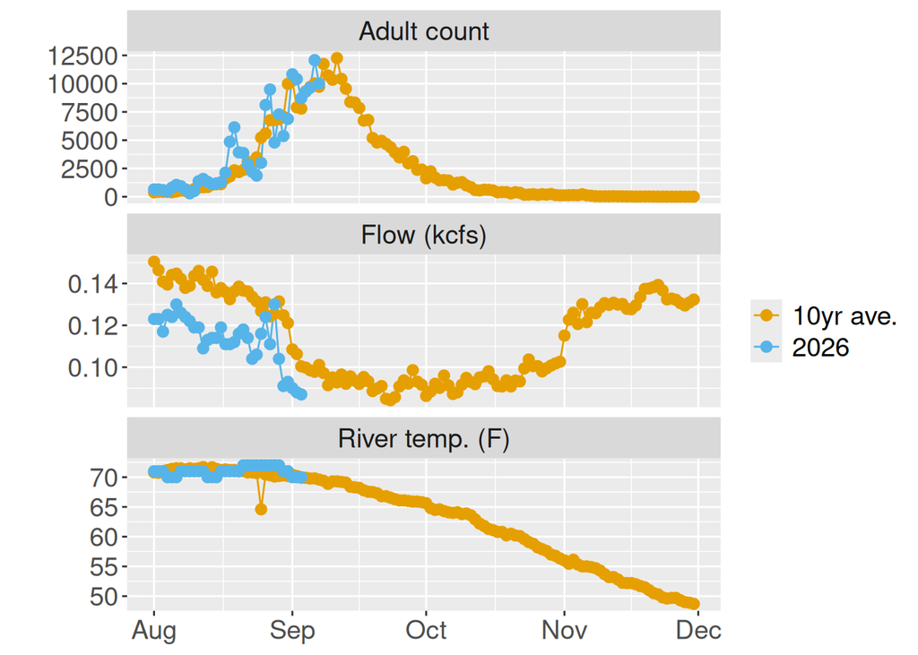

Daily adult Chinook salmon counts, flow, and temperature measurements taken at Bonneville Dam.

###### Percent complete

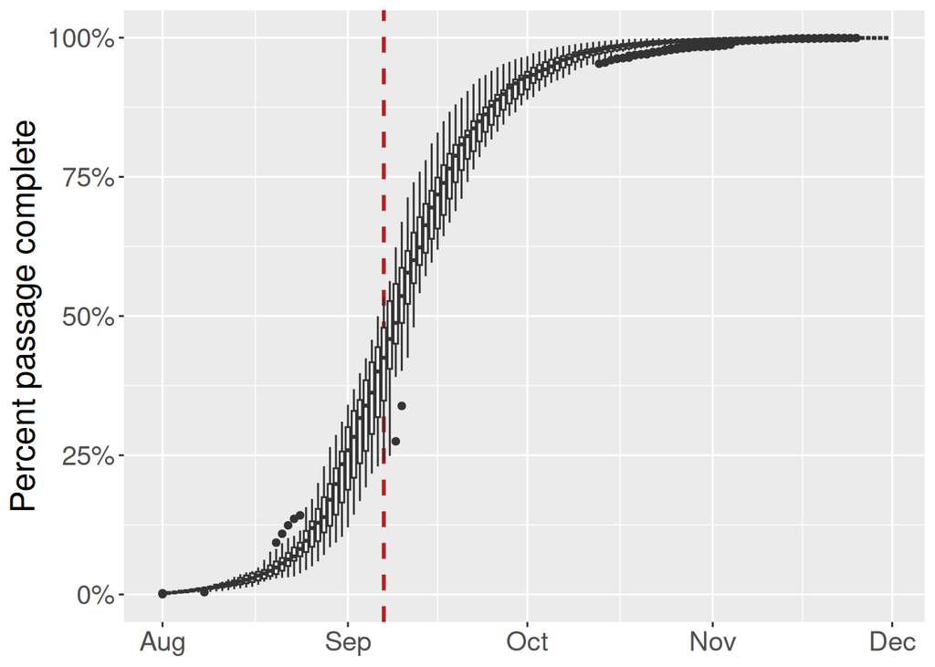

**Percent of the run complete by date in 2011–2025**. Lower and upper hinges correspond to the first and third quartiles (the 25th and 75th percentiles).The upper whisker extends from the hinge to the largest value no further than 1.5 * IQR from the hinge (where IQR is the inter-quartile range, or distance between the first and third quartiles). The lower whisker extends from the hinge to the smallest value at most 1.5 * IQR of the hinge. Data beyond the end of the whiskers are called "outlying" points and are plotted individually.

###### Prediction error

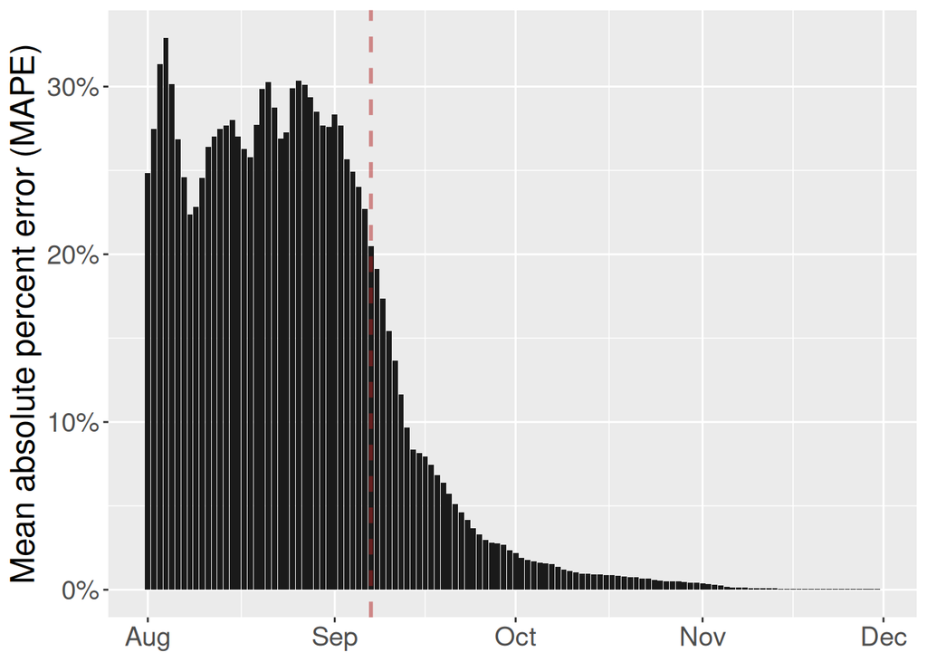

Mean absolute percent error (over 15 year retrospectiv) of predictions based on cumulative counts and 10-year average run timing, by day of year.

##### Run size predictions

###### Prediction table

| Model | Pred | Lo 95 | Lo 50 | Hi 50 | Hi 95 | MAPE |
| --- | --- | --- | --- | --- | --- | --- |
| DLM | 352,086 | 202,566 | 291,091 | 425,861 | 611,969 | 20% |
| ARIMA | 355,821 | 222,063 | 302,179 | 419,532 | 576,444 | 18% |
| 10-year ave. timing | 357,004 | 247,966 | 309,410 | 419,582 | 598,553 | 20% |
| 5-year ave. timing | 323,012 | 234,203 | 284,468 | 373,324 | 515,648 | 20% |

###### Prediction plot

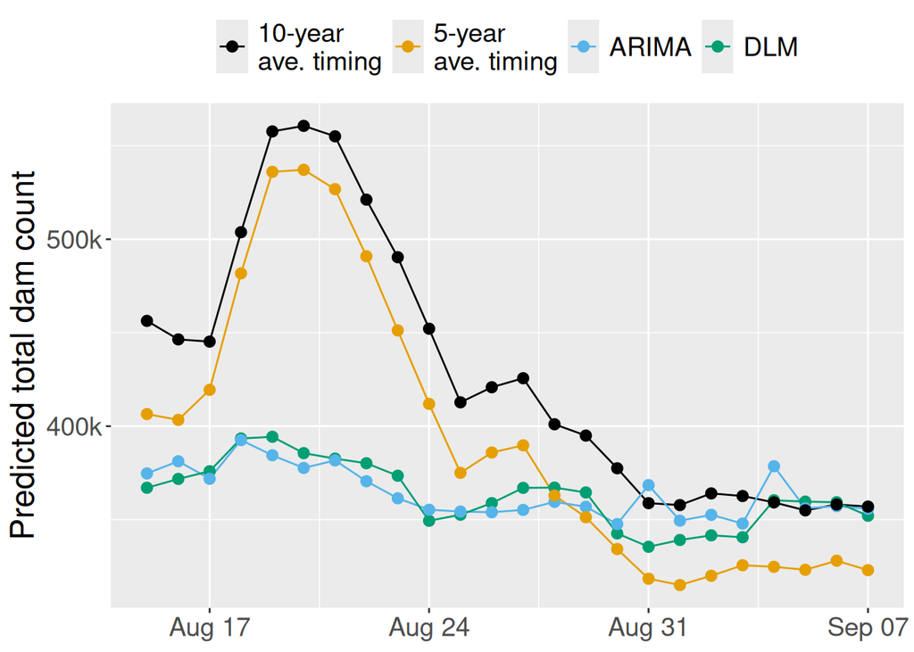

Daily predictions of total counts at Bonneville from different models.

###### Prediction interval plot

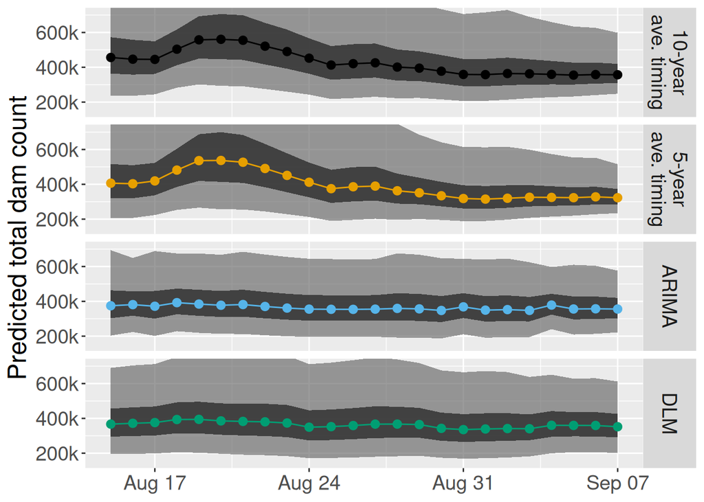

Daily predictions and prediction intervals (95% and 50%). Prediction intervals for different model types are calculated using different methods, so may not be directly comparable. See Methods Description for more details.

###### Covariate effects

Fitted coefficients, covariate values, and effects (coefficient * covariate) for the DLM and ARIMA models. Covariates are the log of the jack returns in the previous years, the log of the cumulative adult counts to date, and an interaction between the cumulative counts and a moving average of river discharge.

| Model<sup>1</sup> | coef intercept | coef log lag jack | coef log cum cnt | coef cnt by flow | covar log lag jack | covar log cum cnt | covar cnt by flow | effect log lag jack | effect log cum cnt | effect cnt by flow |
| --- | --- | --- | --- | --- | --- | --- | --- | --- | --- | --- |
| DLM | −0.05 | 0.23 | 0.57 | 0.05 | 0.28 | 0.28 | NA | 0.07 | 0.16 | NA |
| ARIMA | 12.69 | 0.11 | 0.25 | 0.02 | 0.28 | 0.31 | −0.95 | 0.03 | 0.08 | −0.02 |

<sup>1</sup> The response and the covariates are z-scored before fitting the DLM, but the response is not standardized for the ARIMA model

[output not shown]

###### Methods description

DLM

This is a penalized dynamic linear model fit with the [`Sibregresr` package](https://dfw-wa.github.io/sibregresr/articles/Overview.html). The coefficients are the:

1. log-transformed total count of jacks at Bonneville Dam in the *previous* year,
2. log-transformed cumulative adult count at Bonneville Dam in the *current* year,
3. and interaction between an exponential moving average of river discharge and the cumulative adult count.

The prediction interval is based on the standard deviation (in log-space) of forecasts from a 15-year retrospective. In other words, the root mean square error of the forecast error in log space from a 15-year retrospective is used as the standard deviation in a lognormal prediction interval.

ARIMA

This is an ensemble of ARIMA models fit with the [`SalmonForecasting` package](https://github.com/wdfw-fp/salmonforecast) (see README at the linked page for details). The covariates are the same as those described above for the DLM. Prediction intervals are the weighted average of the prediction intervals provided by the `forecast::forecast()` function in `R`.

Joint likelihood

This is a version of a model that has been used for this purpose of in-season forecasting for several years. The proportion of the run that is complete on a given day is modeled with autoregressive (order 1) errors and an effect of the river discharge covariate. The pre-season forecast is generated using an age-specific sibling regression. I have not yet implemented a retrospective assessment of performance because, in this version, the pre-season forecasts and prediction uncertainty need to be provided, and I have not pulled in the past 15 years’ forecasts.

10 year average run timing

This method takes the 10-year average of the proportion of the run that was complete on a given day and uses it to expand the cumulative counts to date. Performance and prediction intervals are based on a 15-year retrospective as described above for the DLM but assuming a normal prediction distribution for the proportion complete in logit space.

##### Average timing info

###### 10-year average

Prediction

| Date | Daily counts | Cumulative count | 10 Days Early | 9 Days Early | 8 Days Early | 7 Days Early | 6 Days Early | 5 Days Early | 4 Days Early | 3 Days Early | 2 Days Early | 1 Days Early | 10yr Average | 1 Days Late | 2 Days Late | 3 Days Late | 4 Days Late | 5 Days Late | 6 Days Late | 7 Days Late | 8 Days Late | 9 Days Late | 10 Days Late |
| --- | --- | --- | --- | --- | --- | --- | --- | --- | --- | --- | --- | --- | --- | --- | --- | --- | --- | --- | --- | --- | --- | --- | --- |
| 07-Sep | 10,000 | 158,242 | 212,006 | 218,314 | 225,922 | 234,560 | 244,170 | 256,559 | 271,491 | 290,947 | 309,238 | 330,214 | 357,004 | 382,282 | 412,557 | 449,308 | 489,497 | 530,867 | 577,098 | 650,525 | 742,941 | 832,937 | 936,583 |
| 06-Sep | 12,081 | 148,242 | 204,518 | 211,645 | 219,737 | 228,740 | 240,346 | 254,335 | 272,561 | 289,696 | 309,347 | 334,444 | 358,124 | 386,486 | 420,915 | 458,564 | 497,320 | 540,629 | 609,416 | 695,992 | 780,301 | 877,397 | 1,002,258 |
| 05-Sep | 9,637 | 136,161 | 194,397 | 201,830 | 210,099 | 220,759 | 233,608 | 250,349 | 266,087 | 284,137 | 307,188 | 328,939 | 354,990 | 386,613 | 421,194 | 456,791 | 496,571 | 559,752 | 639,273 | 716,711 | 805,894 | 920,580 | 1,071,584 |
| 04-Sep | 9,287 | 126,524 | 187,545 | 195,230 | 205,135 | 217,074 | 232,630 | 247,255 | 264,027 | 285,447 | 305,658 | 329,865 | 359,250 | 391,384 | 424,462 | 461,426 | 520,135 | 594,028 | 665,985 | 748,857 | 855,425 | 995,743 | 1,151,429 |
| 03-Sep | 8,719 | 117,237 | 180,899 | 190,077 | 201,140 | 215,554 | 229,105 | 244,646 | 264,494 | 283,222 | 305,652 | 332,880 | 362,654 | 393,304 | 427,555 | 481,955 | 550,424 | 617,099 | 693,888 | 792,633 | 922,651 | 1,066,909 | 1,251,347 |
| 02-Sep | 10,404 | 108,517 | 175,940 | 186,180 | 199,522 | 212,066 | 226,451 | 244,822 | 262,157 | 282,919 | 308,122 | 335,682 | 364,052 | 395,756 | 446,110 | 509,486 | 571,202 | 642,280 | 733,681 | 854,029 | 987,558 | 1,158,279 | 1,314,262 |
| 01-Sep | 10,827 | 98,114 | 168,331 | 180,394 | 191,735 | 204,741 | 221,351 | 237,024 | 255,795 | 278,581 | 303,499 | 329,150 | 357,814 | 403,340 | 460,641 | 516,440 | 580,703 | 663,342 | 772,151 | 892,879 | 1,047,232 | 1,188,261 | 1,335,473 |
| 31-Aug | 6,883 | 87,286 | 160,487 | 170,576 | 182,147 | 196,924 | 210,867 | 227,567 | 247,839 | 270,007 | 292,827 | 318,328 | 358,830 | 409,807 | 459,449 | 516,620 | 590,139 | 686,941 | 794,346 | 931,666 | 1,057,131 | 1,188,098 | 1,368,594 |
| 30-Aug | 5,366 | 80,404 | 157,125 | 167,784 | 181,396 | 194,239 | 209,623 | 228,296 | 248,716 | 269,737 | 293,227 | 330,535 | 377,493 | 423,220 | 475,883 | 543,605 | 632,774 | 731,709 | 858,201 | 973,773 | 1,094,412 | 1,260,676 | 1,429,476 |
| 29-Aug | 7,281 | 75,038 | 156,587 | 169,291 | 181,277 | 195,634 | 213,061 | 232,118 | 251,736 | 273,659 | 308,477 | 352,301 | 394,977 | 444,126 | 507,328 | 590,547 | 682,880 | 800,930 | 908,790 | 1,021,379 | 1,176,547 | 1,334,082 | 1,515,602 |
| 28-Aug | 4,798 | 67,756 | 152,863 | 163,687 | 176,650 | 192,386 | 209,594 | 227,308 | 247,104 | 278,544 | 318,115 | 356,649 | 401,029 | 458,099 | 533,242 | 616,615 | 723,210 | 820,603 | 922,267 | 1,062,378 | 1,204,627 | 1,368,532 | 1,589,727 |
| 27-Aug | 9,485 | 62,959 | 152,097 | 164,142 | 178,764 | 194,754 | 211,214 | 229,607 | 258,821 | 295,590 | 331,397 | 372,634 | 425,662 | 495,485 | 572,955 | 672,003 | 762,500 | 856,965 | 987,156 | 1,119,332 | 1,271,631 | 1,477,165 | 1,687,872 |
| 26-Aug | 8,117 | 53,474 | 139,414 | 151,833 | 165,414 | 179,394 | 195,017 | 219,829 | 251,060 | 281,471 | 316,496 | 361,536 | 420,840 | 486,639 | 570,765 | 647,629 | 727,862 | 838,440 | 950,704 | 1,080,059 | 1,254,629 | 1,433,592 | 1,649,353 |
| 25-Aug | 2,996 | 45,357 | 128,785 | 140,304 | 152,162 | 165,413 | 186,460 | 212,949 | 238,744 | 268,452 | 306,655 | 356,957 | 412,768 | 484,123 | 549,319 | 617,374 | 711,166 | 806,388 | 916,107 | 1,064,177 | 1,215,975 | 1,398,983 | 1,569,156 |
| 24-Aug | 1,869 | 42,360 | 131,035 | 142,110 | 154,486 | 174,142 | 198,881 | 222,972 | 250,718 | 286,397 | 333,375 | 385,499 | 452,141 | 513,030 | 576,588 | 664,184 | 753,115 | 855,586 | 993,875 | 1,135,644 | 1,306,562 | 1,465,493 | 1,656,924 |
| 23-Aug | 2,203 | 40,491 | 135,838 | 147,668 | 166,456 | 190,104 | 213,132 | 239,653 | 273,757 | 318,662 | 368,486 | 432,186 | 490,388 | 551,142 | 634,871 | 719,878 | 817,827 | 950,012 | 1,085,524 | 1,248,900 | 1,400,816 | 1,583,799 | 1,810,880 |
| 22-Aug | 2,889 | 38,288 | 139,635 | 157,401 | 179,762 | 201,538 | 226,616 | 258,865 | 301,328 | 348,441 | 408,676 | 463,712 | 521,160 | 600,336 | 680,718 | 773,339 | 898,333 | 1,026,474 | 1,180,962 | 1,324,614 | 1,497,643 | 1,712,372 | 1,938,349 |
| 21-Aug | 3,866 | 35,399 | 145,523 | 166,197 | 186,329 | 209,515 | 239,330 | 278,588 | 322,146 | 377,836 | 428,719 | 481,832 | 555,032 | 629,349 | 714,980 | 830,542 | 949,013 | 1,091,842 | 1,224,655 | 1,384,626 | 1,583,151 | 1,792,075 | 2,067,315 |
| 20-Aug | 3,923 | 31,533 | 148,047 | 165,981 | 186,634 | 213,194 | 248,164 | 286,966 | 336,574 | 381,899 | 429,212 | 494,419 | 560,619 | 636,899 | 739,840 | 845,373 | 972,605 | 1,090,913 | 1,233,415 | 1,410,259 | 1,596,367 | 1,841,549 | 2,148,694 |
| 19-Aug | 6,139 | 27,610 | 145,329 | 163,413 | 186,668 | 217,288 | 251,261 | 294,697 | 334,383 | 375,809 | 432,903 | 490,867 | 557,655 | 647,789 | 740,192 | 851,593 | 955,181 | 1,079,952 | 1,234,793 | 1,397,746 | 1,612,422 | 1,881,352 | 2,186,087 |
| 18-Aug | 4,863 | 21,471 | 127,080 | 145,165 | 168,976 | 195,396 | 229,174 | 260,037 | 292,253 | 336,652 | 381,728 | 433,667 | 503,761 | 575,619 | 662,251 | 742,808 | 839,838 | 960,251 | 1,086,973 | 1,253,919 | 1,463,055 | 1,700,036 | 1,939,386 |
| 17-Aug | 2,134 | 16,608 | 112,286 | 130,705 | 151,141 | 177,268 | 201,141 | 226,060 | 260,403 | 295,270 | 335,445 | 389,663 | 445,246 | 512,257 | 574,568 | 649,622 | 742,763 | 840,783 | 969,917 | 1,131,686 | 1,314,993 | 1,500,132 | 1,741,584 |
| 16-Aug | 1,284 | 14,474 | 113,907 | 131,717 | 154,487 | 175,291 | 197,008 | 226,938 | 257,324 | 292,336 | 339,586 | 388,026 | 446,425 | 500,728 | 566,136 | 647,308 | 732,731 | 845,269 | 986,249 | 1,145,998 | 1,307,345 | 1,517,767 | 1,837,513 |
| 15-Aug | 1,186 | 13,190 | 120,036 | 140,787 | 159,746 | 179,537 | 206,812 | 234,504 | 266,411 | 309,471 | 353,615 | 406,835 | 456,323 | 515,930 | 589,903 | 667,751 | 770,309 | 898,786 | 1,044,369 | 1,191,407 | 1,383,168 | 1,674,559 | 2,065,205 |
| 14-Aug | 1,112 | 12,004 | 128,130 | 145,385 | 163,397 | 188,220 | 213,422 | 242,461 | 281,650 | 321,825 | 370,261 | 415,300 | 469,549 | 536,871 | 607,721 | 701,059 | 817,986 | 950,481 | 1,084,301 | 1,258,823 | 1,524,018 | 1,879,545 | 2,324,429 |
| 13-Aug | 1,319 | 10,893 | 131,921 | 148,265 | 170,789 | 193,657 | 220,007 | 255,566 | 292,021 | 335,971 | 376,839 | 426,064 | 487,152 | 551,440 | 636,135 | 742,233 | 862,458 | 983,884 | 1,142,244 | 1,382,879 | 1,705,482 | 2,109,164 | 2,813,955 |
| 12-Aug | 1,571 | 9,573 | 130,307 | 150,103 | 170,201 | 193,360 | 224,612 | 256,651 | 295,278 | 331,196 | 374,459 | 428,148 | 484,650 | 559,086 | 652,333 | 757,996 | 864,715 | 1,003,895 | 1,215,384 | 1,498,913 | 1,853,701 | 2,473,127 | 3,734,030 |
| 11-Aug | 1,377 | 8,002 | 125,464 | 142,263 | 161,620 | 187,742 | 214,522 | 246,809 | 276,830 | 312,992 | 357,868 | 405,095 | 467,312 | 545,253 | 633,572 | 722,773 | 839,106 | 1,015,879 | 1,252,867 | 1,549,417 | 2,067,164 | 3,121,090 | 6,470,770 |
| 10-Aug | 505 | 6,625 | 117,781 | 133,807 | 155,434 | 177,605 | 204,336 | 229,191 | 259,129 | 296,283 | 335,382 | 386,893 | 451,421 | 524,541 | 598,392 | 694,705 | 841,058 | 1,037,263 | 1,282,780 | 1,711,429 | 2,583,986 | 5,357,223 | NA |
| 09-Aug | 302 | 6,119 | 123,599 | 143,577 | 164,057 | 188,748 | 211,707 | 239,362 | 273,681 | 309,798 | 357,379 | 416,985 | 484,527 | 552,744 | 641,711 | 776,899 | 958,136 | 1,184,925 | 1,580,875 | 2,386,870 | 4,948,554 | NA | NA |
| 08-Aug | 661 | 5,817 | 136,491 | 155,961 | 179,433 | 201,260 | 227,549 | 260,175 | 294,509 | 339,742 | 396,407 | 460,615 | 525,466 | 610,042 | 738,558 | 910,852 | 1,126,448 | 1,502,857 | 2,269,076 | 4,704,339 | NA | NA | NA |
| 07-Aug | 931 | 5,157 | 138,246 | 159,052 | 178,399 | 201,703 | 230,623 | 261,057 | 301,153 | 351,381 | 408,296 | 465,781 | 540,750 | 654,669 | 807,392 | 998,500 | 1,332,155 | 2,011,342 | 4,169,995 | NA | NA | NA | NA |
| 06-Aug | 1,047 | 4,226 | 130,351 | 146,207 | 165,306 | 189,007 | 213,949 | 246,809 | 287,974 | 334,619 | 381,730 | 443,171 | 536,534 | 661,698 | 818,320 | 1,091,766 | 1,648,394 | 3,417,517 | NA | NA | NA | NA | NA |
| 05-Aug | 803 | 3,179 | 109,988 | 124,356 | 142,185 | 160,949 | 185,669 | 216,636 | 251,726 | 287,167 | 333,387 | 403,622 | 497,780 | 615,603 | 821,311 | 1,240,049 | 2,570,919 | NA | NA | NA | NA | NA | NA |
| 04-Aug | 489 | 2,377 | 92,962 | 106,291 | 120,318 | 138,797 | 161,946 | 188,178 | 214,672 | 249,224 | 301,728 | 372,116 | 460,195 | 613,971 | 926,999 | 1,921,892 | NA | NA | NA | NA | NA | NA | NA |
| 03-Aug | 587 | 1,888 | 84,424 | 95,566 | 110,243 | 128,630 | 149,466 | 170,509 | 197,953 | 239,656 | 295,563 | 365,522 | 487,664 | 736,295 | 1,526,516 | NA | NA | NA | NA | NA | NA | NA | NA |
| 02-Aug | 649 | 1,300 | 65,832 | 75,943 | 88,609 | 102,962 | 117,458 | 136,363 | 165,091 | 203,604 | 251,796 | 335,935 | 507,209 | 1,051,566 | NA | NA | NA | NA | NA | NA | NA | NA | NA |
| 01-Aug | 651 | 651 | 38,031 | 44,374 | 51,562 | 58,821 | 68,289 | 82,675 | 101,962 | 126,096 | 168,232 | 254,003 | 526,609 | NA | NA | NA | NA | NA | NA | NA | NA | NA | NA |

Proportion complete

| Date | 10 Days Early | 9 Days Early | 8 Days Early | 7 Days Early | 6 Days Early | 5 Days Early | 4 Days Early | 3 Days Early | 2 Days Early | 1 Days Early | 10yr Average | 1 Days Late | 2 Days Late | 3 Days Late | 4 Days Late | 5 Days Late | 6 Days Late | 7 Days Late | 8 Days Late | 9 Days Late | 10 Days Late |
| --- | --- | --- | --- | --- | --- | --- | --- | --- | --- | --- | --- | --- | --- | --- | --- | --- | --- | --- | --- | --- | --- |
| 30-Nov | NA | NA | NA | NA | NA | NA | NA | NA | NA | NA | 1.00 | 1.00 | 1.00 | 1.00 | 1.00 | 1.00 | 1.00 | 1.00 | 1.00 | 1.00 | 1.00 |
| 29-Nov | NA | NA | NA | NA | NA | NA | NA | NA | NA | 1.00 | 1.00 | 1.00 | 1.00 | 1.00 | 1.00 | 1.00 | 1.00 | 1.00 | 1.00 | 1.00 | 1.00 |
| 28-Nov | NA | NA | NA | NA | NA | NA | NA | NA | 1.00 | 1.00 | 1.00 | 1.00 | 1.00 | 1.00 | 1.00 | 1.00 | 1.00 | 1.00 | 1.00 | 1.00 | 1.00 |
| 27-Nov | NA | NA | NA | NA | NA | NA | NA | 1.00 | 1.00 | 1.00 | 1.00 | 1.00 | 1.00 | 1.00 | 1.00 | 1.00 | 1.00 | 1.00 | 1.00 | 1.00 | 1.00 |
| 26-Nov | NA | NA | NA | NA | NA | NA | 1.00 | 1.00 | 1.00 | 1.00 | 1.00 | 1.00 | 1.00 | 1.00 | 1.00 | 1.00 | 1.00 | 1.00 | 1.00 | 1.00 | 1.00 |
| 25-Nov | NA | NA | NA | NA | NA | 1.00 | 1.00 | 1.00 | 1.00 | 1.00 | 1.00 | 1.00 | 1.00 | 1.00 | 1.00 | 1.00 | 1.00 | 1.00 | 1.00 | 1.00 | 1.00 |
| 24-Nov | NA | NA | NA | NA | 1.00 | 1.00 | 1.00 | 1.00 | 1.00 | 1.00 | 1.00 | 1.00 | 1.00 | 1.00 | 1.00 | 1.00 | 1.00 | 1.00 | 1.00 | 1.00 | 1.00 |
| 23-Nov | NA | NA | NA | 1.00 | 1.00 | 1.00 | 1.00 | 1.00 | 1.00 | 1.00 | 1.00 | 1.00 | 1.00 | 1.00 | 1.00 | 1.00 | 1.00 | 1.00 | 1.00 | 1.00 | 1.00 |
| 22-Nov | NA | NA | 1.00 | 1.00 | 1.00 | 1.00 | 1.00 | 1.00 | 1.00 | 1.00 | 1.00 | 1.00 | 1.00 | 1.00 | 1.00 | 1.00 | 1.00 | 1.00 | 1.00 | 1.00 | 1.00 |
| 21-Nov | NA | 1.00 | 1.00 | 1.00 | 1.00 | 1.00 | 1.00 | 1.00 | 1.00 | 1.00 | 1.00 | 1.00 | 1.00 | 1.00 | 1.00 | 1.00 | 1.00 | 1.00 | 1.00 | 1.00 | 1.00 |
| 20-Nov | 1.00 | 1.00 | 1.00 | 1.00 | 1.00 | 1.00 | 1.00 | 1.00 | 1.00 | 1.00 | 1.00 | 1.00 | 1.00 | 1.00 | 1.00 | 1.00 | 1.00 | 1.00 | 1.00 | 1.00 | 1.00 |
| 19-Nov | 1.00 | 1.00 | 1.00 | 1.00 | 1.00 | 1.00 | 1.00 | 1.00 | 1.00 | 1.00 | 1.00 | 1.00 | 1.00 | 1.00 | 1.00 | 1.00 | 1.00 | 1.00 | 1.00 | 1.00 | 1.00 |
| 18-Nov | 1.00 | 1.00 | 1.00 | 1.00 | 1.00 | 1.00 | 1.00 | 1.00 | 1.00 | 1.00 | 1.00 | 1.00 | 1.00 | 1.00 | 1.00 | 1.00 | 1.00 | 1.00 | 1.00 | 1.00 | 1.00 |
| 17-Nov | 1.00 | 1.00 | 1.00 | 1.00 | 1.00 | 1.00 | 1.00 | 1.00 | 1.00 | 1.00 | 1.00 | 1.00 | 1.00 | 1.00 | 1.00 | 1.00 | 1.00 | 1.00 | 1.00 | 1.00 | 1.00 |
| 16-Nov | 1.00 | 1.00 | 1.00 | 1.00 | 1.00 | 1.00 | 1.00 | 1.00 | 1.00 | 1.00 | 1.00 | 1.00 | 1.00 | 1.00 | 1.00 | 1.00 | 1.00 | 1.00 | 1.00 | 1.00 | 1.00 |
| 15-Nov | 1.00 | 1.00 | 1.00 | 1.00 | 1.00 | 1.00 | 1.00 | 1.00 | 1.00 | 1.00 | 1.00 | 1.00 | 1.00 | 1.00 | 1.00 | 1.00 | 1.00 | 1.00 | 1.00 | 1.00 | 1.00 |
| 14-Nov | 1.00 | 1.00 | 1.00 | 1.00 | 1.00 | 1.00 | 1.00 | 1.00 | 1.00 | 1.00 | 1.00 | 1.00 | 1.00 | 1.00 | 1.00 | 1.00 | 1.00 | 1.00 | 1.00 | 1.00 | 1.00 |
| 13-Nov | 1.00 | 1.00 | 1.00 | 1.00 | 1.00 | 1.00 | 1.00 | 1.00 | 1.00 | 1.00 | 1.00 | 1.00 | 1.00 | 1.00 | 1.00 | 1.00 | 1.00 | 1.00 | 1.00 | 1.00 | 1.00 |
| 12-Nov | 1.00 | 1.00 | 1.00 | 1.00 | 1.00 | 1.00 | 1.00 | 1.00 | 1.00 | 1.00 | 1.00 | 1.00 | 1.00 | 1.00 | 1.00 | 1.00 | 1.00 | 1.00 | 1.00 | 1.00 | 1.00 |
| 11-Nov | 1.00 | 1.00 | 1.00 | 1.00 | 1.00 | 1.00 | 1.00 | 1.00 | 1.00 | 1.00 | 1.00 | 1.00 | 1.00 | 1.00 | 1.00 | 1.00 | 1.00 | 1.00 | 1.00 | 1.00 | 1.00 |
| 10-Nov | 1.00 | 1.00 | 1.00 | 1.00 | 1.00 | 1.00 | 1.00 | 1.00 | 1.00 | 1.00 | 1.00 | 1.00 | 1.00 | 1.00 | 1.00 | 1.00 | 1.00 | 1.00 | 1.00 | 1.00 | 0.99 |
| 09-Nov | 1.00 | 1.00 | 1.00 | 1.00 | 1.00 | 1.00 | 1.00 | 1.00 | 1.00 | 1.00 | 1.00 | 1.00 | 1.00 | 1.00 | 1.00 | 1.00 | 1.00 | 1.00 | 1.00 | 0.99 | 0.99 |
| 08-Nov | 1.00 | 1.00 | 1.00 | 1.00 | 1.00 | 1.00 | 1.00 | 1.00 | 1.00 | 1.00 | 1.00 | 1.00 | 1.00 | 1.00 | 1.00 | 1.00 | 1.00 | 1.00 | 0.99 | 0.99 | 0.99 |
| 07-Nov | 1.00 | 1.00 | 1.00 | 1.00 | 1.00 | 1.00 | 1.00 | 1.00 | 1.00 | 1.00 | 1.00 | 1.00 | 1.00 | 1.00 | 1.00 | 1.00 | 1.00 | 0.99 | 0.99 | 0.99 | 0.99 |
| 06-Nov | 1.00 | 1.00 | 1.00 | 1.00 | 1.00 | 1.00 | 1.00 | 1.00 | 1.00 | 1.00 | 1.00 | 1.00 | 1.00 | 1.00 | 1.00 | 1.00 | 0.99 | 0.99 | 0.99 | 0.99 | 0.99 |
| 05-Nov | 1.00 | 1.00 | 1.00 | 1.00 | 1.00 | 1.00 | 1.00 | 1.00 | 1.00 | 1.00 | 1.00 | 1.00 | 1.00 | 1.00 | 1.00 | 0.99 | 0.99 | 0.99 | 0.99 | 0.99 | 0.99 |
| 04-Nov | 1.00 | 1.00 | 1.00 | 1.00 | 1.00 | 1.00 | 1.00 | 1.00 | 1.00 | 1.00 | 1.00 | 1.00 | 1.00 | 1.00 | 0.99 | 0.99 | 0.99 | 0.99 | 0.99 | 0.99 | 0.99 |
| 03-Nov | 1.00 | 1.00 | 1.00 | 1.00 | 1.00 | 1.00 | 1.00 | 1.00 | 1.00 | 1.00 | 1.00 | 1.00 | 1.00 | 0.99 | 0.99 | 0.99 | 0.99 | 0.99 | 0.99 | 0.99 | 0.99 |
| 02-Nov | 1.00 | 1.00 | 1.00 | 1.00 | 1.00 | 1.00 | 1.00 | 1.00 | 1.00 | 1.00 | 1.00 | 1.00 | 0.99 | 0.99 | 0.99 | 0.99 | 0.99 | 0.99 | 0.99 | 0.99 | 0.99 |
| 01-Nov | 1.00 | 1.00 | 1.00 | 1.00 | 1.00 | 1.00 | 1.00 | 1.00 | 1.00 | 1.00 | 1.00 | 0.99 | 0.99 | 0.99 | 0.99 | 0.99 | 0.99 | 0.99 | 0.99 | 0.99 | 0.99 |

[output cut: 92 more lines]

###### 5-year average

Prediction

| Date | Daily counts | Cumulative count | 10 Days Early | 9 Days Early | 8 Days Early | 7 Days Early | 6 Days Early | 5 Days Early | 4 Days Early | 3 Days Early | 2 Days Early | 1 Days Early | 5yr Average | 1 Days Late | 2 Days Late | 3 Days Late | 4 Days Late | 5 Days Late | 6 Days Late | 7 Days Late | 8 Days Late | 9 Days Late | 10 Days Late |
| --- | --- | --- | --- | --- | --- | --- | --- | --- | --- | --- | --- | --- | --- | --- | --- | --- | --- | --- | --- | --- | --- | --- | --- |
| 07-Sep | 10,000 | 158,242 | 201,633 | 207,100 | 213,418 | 220,945 | 228,272 | 237,023 | 247,645 | 261,602 | 277,106 | 296,686 | 323,012 | 350,184 | 375,601 | 406,216 | 439,531 | 466,647 | 508,108 | 577,289 | 657,930 | 740,881 | 847,628 |
| 06-Sep | 12,081 | 148,242 | 194,013 | 199,931 | 206,982 | 213,847 | 222,045 | 231,995 | 245,070 | 259,595 | 277,937 | 302,599 | 328,054 | 351,866 | 380,546 | 411,755 | 437,158 | 475,999 | 540,808 | 616,354 | 694,062 | 794,063 | 917,736 |
| 05-Sep | 9,637 | 136,161 | 183,638 | 190,115 | 196,420 | 203,950 | 213,089 | 225,099 | 238,439 | 255,287 | 277,939 | 301,320 | 323,191 | 349,534 | 378,200 | 401,532 | 437,208 | 496,735 | 566,124 | 637,500 | 729,352 | 842,946 | 982,684 |
| 04-Sep | 9,287 | 126,524 | 176,659 | 182,518 | 189,515 | 198,008 | 209,167 | 221,564 | 237,219 | 258,268 | 279,994 | 300,317 | 324,796 | 351,433 | 373,114 | 406,264 | 461,578 | 526,057 | 592,381 | 677,732 | 783,286 | 913,134 | 1,046,264 |
| 03-Sep | 8,719 | 117,237 | 169,120 | 175,604 | 183,473 | 193,813 | 205,300 | 219,806 | 239,310 | 259,441 | 278,272 | 300,954 | 325,636 | 345,725 | 376,443 | 427,697 | 487,442 | 548,897 | 627,983 | 725,789 | 846,106 | 969,464 | 1,140,036 |
| 02-Sep | 10,404 | 108,517 | 162,543 | 169,827 | 179,399 | 190,031 | 203,458 | 221,511 | 240,145 | 257,576 | 278,571 | 301,417 | 320,012 | 348,445 | 395,887 | 451,188 | 508,073 | 581,277 | 671,809 | 783,177 | 897,360 | 1,055,245 | 1,209,372 |
| 01-Sep | 10,827 | 98,114 | 153,546 | 162,199 | 171,812 | 183,952 | 200,275 | 217,122 | 232,882 | 251,864 | 272,519 | 289,332 | 315,039 | 357,932 | 407,932 | 459,363 | 525,549 | 607,401 | 708,092 | 811,329 | 954,077 | 1,093,427 | 1,257,877 |
| 31-Aug | 6,883 | 87,286 | 144,300 | 152,852 | 163,652 | 178,174 | 193,162 | 207,182 | 224,069 | 242,446 | 257,403 | 280,273 | 318,433 | 362,915 | 408,671 | 467,552 | 540,372 | 629,951 | 721,795 | 848,791 | 972,763 | 1,119,065 | 1,298,917 |
| 30-Aug | 5,366 | 80,404 | 140,799 | 150,748 | 164,124 | 177,930 | 190,845 | 206,401 | 223,328 | 237,106 | 258,172 | 293,323 | 334,298 | 376,445 | 430,684 | 497,762 | 580,278 | 664,879 | 781,861 | 896,057 | 1,030,823 | 1,196,494 | 1,369,581 |
| 29-Aug | 7,281 | 75,038 | 140,688 | 153,171 | 166,056 | 178,109 | 192,627 | 208,425 | 221,283 | 240,944 | 273,749 | 311,989 | 351,324 | 401,943 | 464,545 | 541,554 | 620,510 | 729,685 | 836,261 | 962,033 | 1,116,648 | 1,278,184 | 1,456,887 |
| 28-Aug | 4,798 | 67,756 | 138,308 | 149,943 | 160,826 | 173,935 | 188,200 | 199,810 | 217,563 | 247,185 | 281,715 | 317,233 | 362,940 | 419,466 | 489,003 | 560,297 | 658,878 | 755,112 | 868,680 | 1,008,291 | 1,154,152 | 1,315,515 | 1,520,286 |
| 27-Aug | 9,485 | 62,959 | 139,326 | 149,439 | 161,619 | 174,874 | 185,663 | 202,158 | 229,683 | 261,768 | 294,771 | 337,242 | 389,766 | 454,379 | 520,625 | 612,226 | 701,646 | 807,172 | 936,898 | 1,072,432 | 1,222,369 | 1,412,641 | 1,590,084 |
| 26-Aug | 8,117 | 53,474 | 126,926 | 137,271 | 148,529 | 157,692 | 171,703 | 195,081 | 222,332 | 250,363 | 286,436 | 331,047 | 385,926 | 442,192 | 519,993 | 595,942 | 685,571 | 795,754 | 910,869 | 1,038,218 | 1,199,825 | 1,350,536 | 1,490,287 |
| 25-Aug | 2,996 | 45,357 | 116,434 | 125,983 | 133,755 | 145,639 | 165,468 | 188,582 | 212,358 | 242,955 | 280,795 | 327,343 | 375,068 | 441,059 | 505,479 | 581,502 | 674,959 | 772,600 | 880,617 | 1,017,693 | 1,145,527 | 1,264,063 | 1,397,789 |
| 24-Aug | 1,869 | 42,360 | 117,660 | 124,919 | 136,017 | 154,537 | 176,124 | 198,329 | 226,905 | 262,244 | 305,718 | 350,290 | 411,921 | 472,085 | 543,086 | 630,369 | 721,560 | 822,441 | 950,461 | 1,069,849 | 1,180,555 | 1,305,447 | 1,499,423 |
| 23-Aug | 2,203 | 40,491 | 119,406 | 130,015 | 147,716 | 168,351 | 189,576 | 216,891 | 250,671 | 292,225 | 334,830 | 393,742 | 451,251 | 519,118 | 602,549 | 689,715 | 786,144 | 908,514 | 1,022,634 | 1,128,454 | 1,247,834 | 1,433,249 | 1,659,809 |
| 22-Aug | 2,889 | 38,288 | 122,942 | 139,681 | 159,193 | 179,264 | 205,092 | 237,035 | 276,329 | 316,616 | 372,323 | 426,704 | 490,879 | 569,772 | 652,196 | 743,380 | 859,093 | 967,004 | 1,067,068 | 1,179,954 | 1,355,283 | 1,569,519 | 1,777,205 |
| 21-Aug | 3,866 | 35,399 | 129,140 | 147,180 | 165,736 | 189,615 | 219,147 | 255,476 | 292,723 | 344,226 | 394,503 | 453,836 | 526,775 | 602,979 | 687,282 | 794,263 | 894,031 | 986,543 | 1,090,911 | 1,253,009 | 1,451,078 | 1,643,092 | 1,874,472 |
| 20-Aug | 3,923 | 31,533 | 131,107 | 147,636 | 168,908 | 195,215 | 227,576 | 260,756 | 306,634 | 351,420 | 404,274 | 469,247 | 537,129 | 612,225 | 707,523 | 796,396 | 878,805 | 971,775 | 1,116,171 | 1,292,609 | 1,463,654 | 1,669,765 | 1,956,199 |
| 19-Aug | 6,139 | 27,610 | 129,267 | 147,892 | 170,926 | 199,261 | 228,312 | 268,483 | 307,696 | 353,974 | 410,863 | 470,299 | 536,052 | 619,493 | 697,308 | 769,464 | 850,866 | 977,296 | 1,131,782 | 1,281,545 | 1,462,012 | 1,712,807 | 2,052,748 |
| 18-Aug | 4,863 | 21,471 | 115,010 | 132,923 | 154,958 | 177,550 | 208,789 | 239,284 | 275,272 | 319,512 | 365,734 | 416,867 | 481,756 | 542,270 | 598,383 | 661,686 | 760,006 | 880,143 | 996,608 | 1,136,951 | 1,331,985 | 1,596,343 | 1,885,718 |
| 17-Aug | 2,134 | 16,608 | 102,817 | 119,861 | 137,336 | 161,500 | 185,088 | 212,925 | 247,146 | 282,898 | 322,450 | 372,642 | 419,450 | 462,854 | 511,820 | 587,871 | 680,798 | 770,885 | 879,441 | 1,030,302 | 1,234,785 | 1,458,619 | 1,733,606 |
| 16-Aug | 1,284 | 14,474 | 104,457 | 119,687 | 140,745 | 161,302 | 185,561 | 215,384 | 246,542 | 281,011 | 324,753 | 365,545 | 403,371 | 446,044 | 512,322 | 593,307 | 671,816 | 766,421 | 897,894 | 1,076,099 | 1,271,167 | 1,510,814 | 1,860,559 |
| 15-Aug | 1,186 | 13,190 | 109,073 | 128,263 | 146,997 | 169,105 | 196,283 | 224,678 | 256,090 | 295,953 | 333,128 | 367,599 | 406,488 | 466,888 | 540,691 | 612,238 | 698,453 | 818,267 | 980,668 | 1,158,437 | 1,376,832 | 1,695,561 | 2,111,316 |
| 14-Aug | 1,112 | 12,004 | 116,733 | 133,782 | 153,903 | 178,638 | 204,480 | 233,068 | 269,347 | 303,180 | 334,553 | 369,945 | 424,915 | 492,083 | 557,198 | 635,663 | 744,706 | 892,507 | 1,054,295 | 1,253,056 | 1,543,132 | 1,921,511 | 2,340,193 |
| 13-Aug | 1,319 | 10,893 | 121,393 | 139,650 | 162,094 | 185,543 | 211,484 | 244,403 | 275,103 | 303,570 | 335,685 | 385,564 | 446,512 | 505,597 | 576,795 | 675,739 | 809,853 | 956,658 | 1,137,012 | 1,400,223 | 1,743,561 | 2,123,469 | 2,852,614 |
| 12-Aug | 1,571 | 9,573 | 122,736 | 142,461 | 163,070 | 185,869 | 214,801 | 241,782 | 266,801 | 295,026 | 338,864 | 392,430 | 444,358 | 506,933 | 593,893 | 711,763 | 840,787 | 999,296 | 1,230,628 | 1,532,380 | 1,866,273 | 2,507,103 | 3,948,167 |
| 11-Aug | 1,377 | 8,002 | 119,076 | 136,302 | 155,358 | 179,541 | 202,094 | 223,006 | 246,598 | 283,240 | 328,013 | 371,417 | 423,720 | 496,406 | 594,927 | 702,772 | 835,262 | 1,028,621 | 1,280,840 | 1,559,925 | 2,095,563 | 3,300,077 | 7,146,965 |
| 10-Aug | 505 | 6,625 | 112,846 | 128,623 | 148,644 | 167,316 | 184,629 | 204,161 | 234,497 | 271,566 | 307,500 | 350,803 | 410,980 | 492,547 | 581,833 | 691,523 | 851,607 | 1,060,422 | 1,291,480 | 1,734,940 | 2,732,171 | 5,917,053 | NA |
| 09-Aug | 302 | 6,119 | 118,811 | 137,305 | 154,552 | 170,545 | 188,587 | 216,609 | 250,850 | 284,043 | 324,042 | 379,629 | 454,974 | 537,448 | 638,771 | 786,643 | 979,529 | 1,192,961 | 1,602,593 | 2,523,751 | 5,465,678 | NA | NA |
| 08-Aug | 661 | 5,817 | 130,529 | 146,925 | 162,128 | 179,280 | 205,919 | 238,470 | 270,025 | 308,050 | 360,894 | 432,520 | 510,925 | 607,247 | 747,821 | 931,189 | 1,134,087 | 1,523,504 | 2,399,201 | 5,195,942 | NA | NA | NA |
| 07-Aug | 931 | 5,157 | 130,236 | 143,713 | 158,916 | 182,530 | 211,383 | 239,354 | 273,060 | 319,902 | 383,392 | 452,891 | 538,273 | 662,880 | 825,419 | 1,005,272 | 1,350,456 | 2,126,687 | 4,605,759 | NA | NA | NA | NA |
| 06-Aug | 1,047 | 4,226 | 117,780 | 130,240 | 149,592 | 173,239 | 196,163 | 223,786 | 262,175 | 314,209 | 371,167 | 441,141 | 543,263 | 676,472 | 823,870 | 1,106,765 | 1,742,925 | 3,774,647 | NA | NA | NA | NA | NA |
| 05-Aug | 803 | 3,179 | 97,976 | 112,535 | 130,324 | 147,569 | 168,349 | 197,228 | 236,372 | 279,220 | 331,860 | 408,684 | 508,894 | 619,778 | 832,594 | 1,311,162 | 2,839,580 | NA | NA | NA | NA | NA | NA |
| 04-Aug | 489 | 2,377 | 84,125 | 97,424 | 110,315 | 125,850 | 147,438 | 176,700 | 208,731 | 248,082 | 305,512 | 380,424 | 463,316 | 622,406 | 980,160 | 2,122,730 | NA | NA | NA | NA | NA | NA | NA |
| 03-Aug | 587 | 1,888 | 77,381 | 87,621 | 99,960 | 117,107 | 140,349 | 165,791 | 197,046 | 242,661 | 302,162 | 368,001 | 494,363 | 778,519 | 1,686,037 | NA | NA | NA | NA | NA | NA | NA | NA |
| 02-Aug | 649 | 1,300 | 60,359 | 68,859 | 80,671 | 96,682 | 114,208 | 135,739 | 167,161 | 208,150 | 253,504 | 340,550 | 536,296 | 1,161,455 | NA | NA | NA | NA | NA | NA | NA | NA | NA |
| 01-Aug | 651 | 651 | 34,484 | 40,399 | 48,417 | 57,194 | 67,976 | 83,712 | 104,238 | 126,951 | 170,543 | 268,569 | 581,640 | NA | NA | NA | NA | NA | NA | NA | NA | NA | NA |

Proportion complete

| Date | 10 Days Early | 9 Days Early | 8 Days Early | 7 Days Early | 6 Days Early | 5 Days Early | 4 Days Early | 3 Days Early | 2 Days Early | 1 Days Early | 5yr Average | 1 Days Late | 2 Days Late | 3 Days Late | 4 Days Late | 5 Days Late | 6 Days Late | 7 Days Late | 8 Days Late | 9 Days Late | 10 Days Late |
| --- | --- | --- | --- | --- | --- | --- | --- | --- | --- | --- | --- | --- | --- | --- | --- | --- | --- | --- | --- | --- | --- |
| 30-Nov | NA | NA | NA | NA | NA | NA | NA | NA | NA | NA | 1.00 | 1.00 | 1.00 | 1.00 | 1.00 | 1.00 | 1.00 | 1.00 | 1.00 | 1.00 | 1.00 |
| 29-Nov | NA | NA | NA | NA | NA | NA | NA | NA | NA | 1.00 | 1.00 | 1.00 | 1.00 | 1.00 | 1.00 | 1.00 | 1.00 | 1.00 | 1.00 | 1.00 | 1.00 |
| 28-Nov | NA | NA | NA | NA | NA | NA | NA | NA | 1.00 | 1.00 | 1.00 | 1.00 | 1.00 | 1.00 | 1.00 | 1.00 | 1.00 | 1.00 | 1.00 | 1.00 | 1.00 |
| 27-Nov | NA | NA | NA | NA | NA | NA | NA | 1.00 | 1.00 | 1.00 | 1.00 | 1.00 | 1.00 | 1.00 | 1.00 | 1.00 | 1.00 | 1.00 | 1.00 | 1.00 | 1.00 |
| 26-Nov | NA | NA | NA | NA | NA | NA | 1.00 | 1.00 | 1.00 | 1.00 | 1.00 | 1.00 | 1.00 | 1.00 | 1.00 | 1.00 | 1.00 | 1.00 | 1.00 | 1.00 | 1.00 |
| 25-Nov | NA | NA | NA | NA | NA | 1.00 | 1.00 | 1.00 | 1.00 | 1.00 | 1.00 | 1.00 | 1.00 | 1.00 | 1.00 | 1.00 | 1.00 | 1.00 | 1.00 | 1.00 | 1.00 |
| 24-Nov | NA | NA | NA | NA | 1.00 | 1.00 | 1.00 | 1.00 | 1.00 | 1.00 | 1.00 | 1.00 | 1.00 | 1.00 | 1.00 | 1.00 | 1.00 | 1.00 | 1.00 | 1.00 | 1.00 |
| 23-Nov | NA | NA | NA | 1.00 | 1.00 | 1.00 | 1.00 | 1.00 | 1.00 | 1.00 | 1.00 | 1.00 | 1.00 | 1.00 | 1.00 | 1.00 | 1.00 | 1.00 | 1.00 | 1.00 | 1.00 |
| 22-Nov | NA | NA | 1.00 | 1.00 | 1.00 | 1.00 | 1.00 | 1.00 | 1.00 | 1.00 | 1.00 | 1.00 | 1.00 | 1.00 | 1.00 | 1.00 | 1.00 | 1.00 | 1.00 | 1.00 | 1.00 |
| 21-Nov | NA | 1.00 | 1.00 | 1.00 | 1.00 | 1.00 | 1.00 | 1.00 | 1.00 | 1.00 | 1.00 | 1.00 | 1.00 | 1.00 | 1.00 | 1.00 | 1.00 | 1.00 | 1.00 | 1.00 | 1.00 |
| 20-Nov | 1.00 | 1.00 | 1.00 | 1.00 | 1.00 | 1.00 | 1.00 | 1.00 | 1.00 | 1.00 | 1.00 | 1.00 | 1.00 | 1.00 | 1.00 | 1.00 | 1.00 | 1.00 | 1.00 | 1.00 | 1.00 |
| 19-Nov | 1.00 | 1.00 | 1.00 | 1.00 | 1.00 | 1.00 | 1.00 | 1.00 | 1.00 | 1.00 | 1.00 | 1.00 | 1.00 | 1.00 | 1.00 | 1.00 | 1.00 | 1.00 | 1.00 | 1.00 | 1.00 |
| 18-Nov | 1.00 | 1.00 | 1.00 | 1.00 | 1.00 | 1.00 | 1.00 | 1.00 | 1.00 | 1.00 | 1.00 | 1.00 | 1.00 | 1.00 | 1.00 | 1.00 | 1.00 | 1.00 | 1.00 | 1.00 | 1.00 |
| 17-Nov | 1.00 | 1.00 | 1.00 | 1.00 | 1.00 | 1.00 | 1.00 | 1.00 | 1.00 | 1.00 | 1.00 | 1.00 | 1.00 | 1.00 | 1.00 | 1.00 | 1.00 | 1.00 | 1.00 | 1.00 | 1.00 |
| 16-Nov | 1.00 | 1.00 | 1.00 | 1.00 | 1.00 | 1.00 | 1.00 | 1.00 | 1.00 | 1.00 | 1.00 | 1.00 | 1.00 | 1.00 | 1.00 | 1.00 | 1.00 | 1.00 | 1.00 | 1.00 | 1.00 |
| 15-Nov | 1.00 | 1.00 | 1.00 | 1.00 | 1.00 | 1.00 | 1.00 | 1.00 | 1.00 | 1.00 | 1.00 | 1.00 | 1.00 | 1.00 | 1.00 | 1.00 | 1.00 | 1.00 | 1.00 | 1.00 | 1.00 |
| 14-Nov | 1.00 | 1.00 | 1.00 | 1.00 | 1.00 | 1.00 | 1.00 | 1.00 | 1.00 | 1.00 | 1.00 | 1.00 | 1.00 | 1.00 | 1.00 | 1.00 | 1.00 | 1.00 | 1.00 | 1.00 | 1.00 |
| 13-Nov | 1.00 | 1.00 | 1.00 | 1.00 | 1.00 | 1.00 | 1.00 | 1.00 | 1.00 | 1.00 | 1.00 | 1.00 | 1.00 | 1.00 | 1.00 | 1.00 | 1.00 | 1.00 | 1.00 | 1.00 | 1.00 |
| 12-Nov | 1.00 | 1.00 | 1.00 | 1.00 | 1.00 | 1.00 | 1.00 | 1.00 | 1.00 | 1.00 | 1.00 | 1.00 | 1.00 | 1.00 | 1.00 | 1.00 | 1.00 | 1.00 | 1.00 | 1.00 | 1.00 |
| 11-Nov | 1.00 | 1.00 | 1.00 | 1.00 | 1.00 | 1.00 | 1.00 | 1.00 | 1.00 | 1.00 | 1.00 | 1.00 | 1.00 | 1.00 | 1.00 | 1.00 | 1.00 | 1.00 | 1.00 | 1.00 | 1.00 |
| 10-Nov | 1.00 | 1.00 | 1.00 | 1.00 | 1.00 | 1.00 | 1.00 | 1.00 | 1.00 | 1.00 | 1.00 | 1.00 | 1.00 | 1.00 | 1.00 | 1.00 | 1.00 | 1.00 | 1.00 | 1.00 | 1.00 |
| 09-Nov | 1.00 | 1.00 | 1.00 | 1.00 | 1.00 | 1.00 | 1.00 | 1.00 | 1.00 | 1.00 | 1.00 | 1.00 | 1.00 | 1.00 | 1.00 | 1.00 | 1.00 | 1.00 | 1.00 | 1.00 | 1.00 |
| 08-Nov | 1.00 | 1.00 | 1.00 | 1.00 | 1.00 | 1.00 | 1.00 | 1.00 | 1.00 | 1.00 | 1.00 | 1.00 | 1.00 | 1.00 | 1.00 | 1.00 | 1.00 | 1.00 | 1.00 | 1.00 | 1.00 |
| 07-Nov | 1.00 | 1.00 | 1.00 | 1.00 | 1.00 | 1.00 | 1.00 | 1.00 | 1.00 | 1.00 | 1.00 | 1.00 | 1.00 | 1.00 | 1.00 | 1.00 | 1.00 | 1.00 | 1.00 | 1.00 | 1.00 |
| 06-Nov | 1.00 | 1.00 | 1.00 | 1.00 | 1.00 | 1.00 | 1.00 | 1.00 | 1.00 | 1.00 | 1.00 | 1.00 | 1.00 | 1.00 | 1.00 | 1.00 | 1.00 | 1.00 | 1.00 | 1.00 | 1.00 |
| 05-Nov | 1.00 | 1.00 | 1.00 | 1.00 | 1.00 | 1.00 | 1.00 | 1.00 | 1.00 | 1.00 | 1.00 | 1.00 | 1.00 | 1.00 | 1.00 | 1.00 | 1.00 | 1.00 | 1.00 | 1.00 | 1.00 |
| 04-Nov | 1.00 | 1.00 | 1.00 | 1.00 | 1.00 | 1.00 | 1.00 | 1.00 | 1.00 | 1.00 | 1.00 | 1.00 | 1.00 | 1.00 | 1.00 | 1.00 | 1.00 | 1.00 | 1.00 | 1.00 | 1.00 |
| 03-Nov | 1.00 | 1.00 | 1.00 | 1.00 | 1.00 | 1.00 | 1.00 | 1.00 | 1.00 | 1.00 | 1.00 | 1.00 | 1.00 | 1.00 | 1.00 | 1.00 | 1.00 | 1.00 | 1.00 | 1.00 | 0.99 |
| 02-Nov | 1.00 | 1.00 | 1.00 | 1.00 | 1.00 | 1.00 | 1.00 | 1.00 | 1.00 | 1.00 | 1.00 | 1.00 | 1.00 | 1.00 | 1.00 | 1.00 | 1.00 | 1.00 | 1.00 | 0.99 | 0.99 |
| 01-Nov | 1.00 | 1.00 | 1.00 | 1.00 | 1.00 | 1.00 | 1.00 | 1.00 | 1.00 | 1.00 | 1.00 | 1.00 | 1.00 | 1.00 | 1.00 | 1.00 | 1.00 | 1.00 | 0.99 | 0.99 | 0.99 |

[output cut: 92 more lines]

## Sockeye

###### Current year

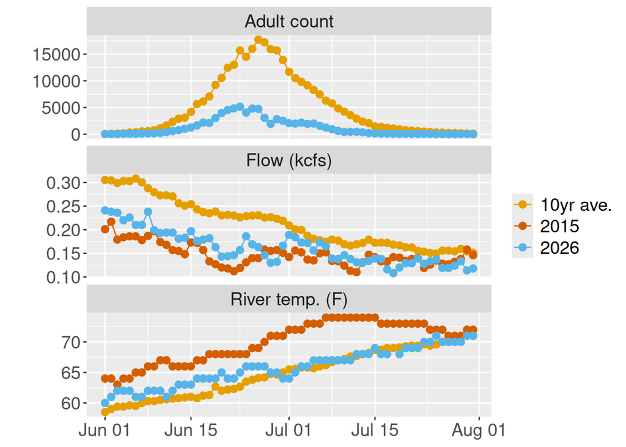

Daily Sockeye salmon counts, flow, and temperature measurements taken at Bonneville Dam.

###### Percent complete

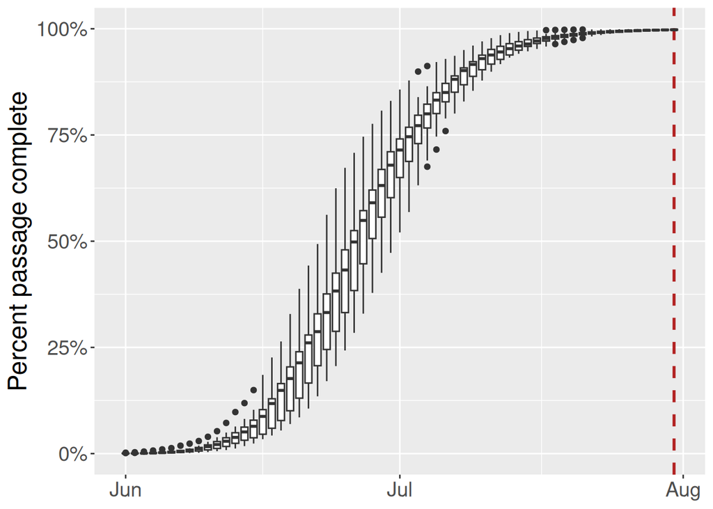

**Percent of the run complete by date in 2011–2025**. Lower and upper hinges correspond to the first and third quartiles (the 25th and 75th percentiles).The upper whisker extends from the hinge to the largest value no further than 1.5 * IQR from the hinge (where IQR is the inter-quartile range, or distance between the first and third quartiles). The lower whisker extends from the hinge to the smallest value at most 1.5 * IQR of the hinge. Data beyond the end of the whiskers are called "outlying" points and are plotted individually.

###### Prediction error

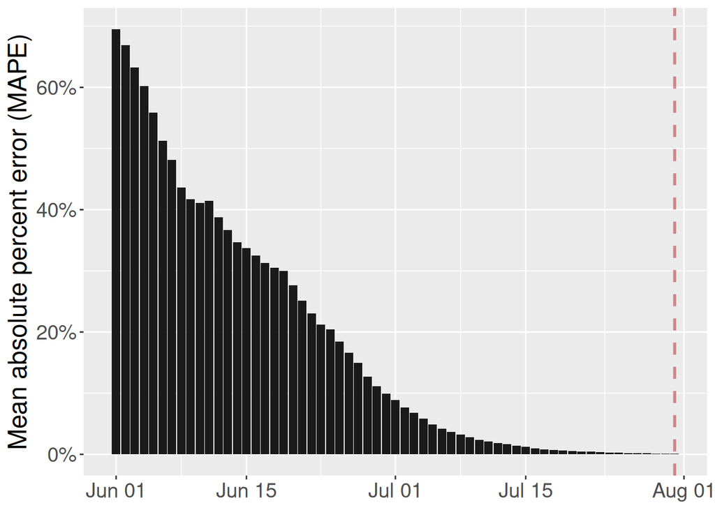

Mean absolute percent error (over 15 year retrospectiv) of predictions based on cumulative counts and 10-year average run timing, by day of year.

##### Run size predictions

###### Prediction table

Predictions of the sockey salmon count with prediction intervals (50% and 95%) and the mean absolute percent error (MAPE) of predictions made with counts through July 31 in a 15-year retrospective assesment.

| Model | Pred | Lo 95 | Lo 50 | Hi 50 | Hi 95 | MAPE |
| --- | --- | --- | --- | --- | --- | --- |
| 10-year ave. timing | 74,156 | 74,030 | 74,093 | 74,254 | 74,622 | 0% |
| 5-year ave. timing | 74,145 | 74,018 | 74,079 | 74,257 | 74,728 | 0% |

###### Prediction plot

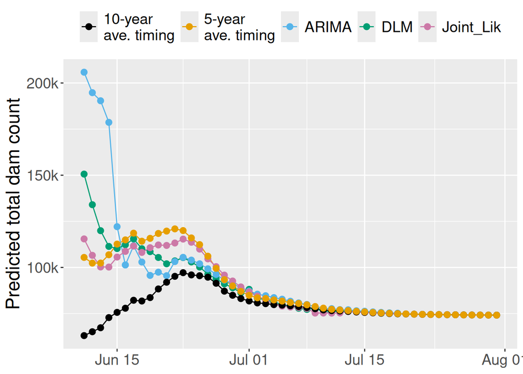

Daily predictions of total counts at Bonneville from different models.

###### Prediction interval plot

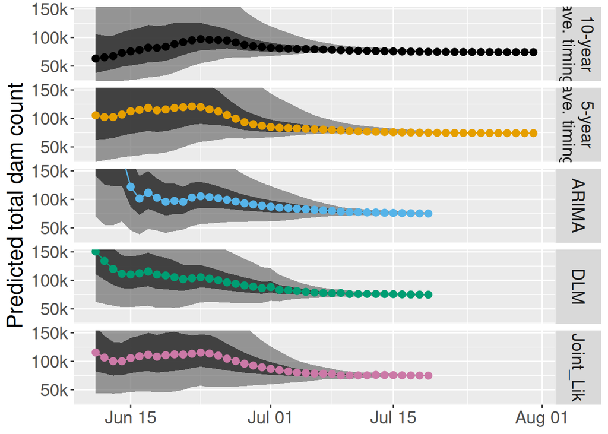

Daily predictions and prediction intervals (95% and 50%). Prediction intervals for different model types are calculated using different methods, so may not be directly comparable. See Methods Description for more details.

###### Methods description

DLM

This is a penalized dynamic linear model fit with the [`Sibregresr` package](https://dfw-wa.github.io/sibregresr/articles/Overview.html). The coefficients are the:

1. log-transformed estimates of age-3 passage at Bonneville Dam in the *previous* year,
2. log-transformed cumulative adult count at Bonneville Dam in the *current* year,
3. an even-odd year indicator that starts in 2000 to reflect the pattern attributed to pink salmon interactions.
4. and interaction between an exponential moving average of river discharge and the cumulative adult count.

The prediction interval is based on the standard deviation (in log-space) of forecasts from a 15-year retrospective. In other words, the root mean square error of the forecast error in log space from a 15-year retrospective is used as the standard deviation in a lognormal prediction interval.

ARIMA

This is an ensemble of ARIMA models fit with the [`SalmonForecasting` package](https://github.com/wdfw-fp/salmonforecast) (see README at the linked page for details). The covariates are the same as those described above for the DLM. Prediction intervals are the weighted average of the prediction intervals provided by the `forecast::forecast()` function in `R`.

Joint likelihood

This is a version of a model that has been used for this purpose of in-season forecasting for several years. The proportion of the run that is complete on a given day is modeled with autoregressive (order 1) errors and an effect of the river discharge covariate. The pre-season forecasts are provided as inputs and assumed to have a lognormal error of 0.6.

10 year average run timing

This method takes the 10-year average of the proportion of the run that was complete on a given day and uses it to expand the cumulative counts to date. Performance and prediction intervals are based on a 15-year retrospective as described above for the DLM but assuming a normal prediction distribution for the proportion complete in logit space.

##### Average timing info

###### 10-year average

Prediction

| Date | Daily counts | Cumulative count | 10 Days Early | 9 Days Early | 8 Days Early | 7 Days Early | 6 Days Early | 5 Days Early | 4 Days Early | 3 Days Early | 2 Days Early | 1 Days Early | 10yr Average | 1 Days Late | 2 Days Late | 3 Days Late | 4 Days Late | 5 Days Late | 6 Days Late | 7 Days Late | 8 Days Late | 9 Days Late | 10 Days Late |
| --- | --- | --- | --- | --- | --- | --- | --- | --- | --- | --- | --- | --- | --- | --- | --- | --- | --- | --- | --- | --- | --- | --- | --- |
| 31-Jul | 4 | 73,937 | 74,041 | 74,044 | 74,048 | 74,053 | 74,060 | 74,070 | 74,082 | 74,095 | 74,112 | 74,132 | 74,156 | 74,184 | 74,218 | 74,260 | 74,311 | 74,371 | 74,441 | 74,520 | 74,619 | 74,737 | 74,871 |
| 30-Jul | 9 | 73,933 | 74,040 | 74,044 | 74,049 | 74,056 | 74,066 | 74,078 | 74,091 | 74,108 | 74,128 | 74,152 | 74,180 | 74,214 | 74,256 | 74,307 | 74,367 | 74,437 | 74,516 | 74,615 | 74,733 | 74,867 | 75,027 |
| 29-Jul | 7 | 73,924 | 74,035 | 74,040 | 74,047 | 74,057 | 74,069 | 74,082 | 74,099 | 74,119 | 74,143 | 74,171 | 74,205 | 74,247 | 74,297 | 74,358 | 74,428 | 74,507 | 74,606 | 74,723 | 74,858 | 75,018 | 75,201 |
| 28-Jul | 5 | 73,917 | 74,033 | 74,040 | 74,050 | 74,062 | 74,075 | 74,092 | 74,112 | 74,136 | 74,164 | 74,198 | 74,240 | 74,290 | 74,351 | 74,421 | 74,500 | 74,599 | 74,716 | 74,851 | 75,011 | 75,194 | 75,409 |
| 27-Jul | 7 | 73,912 | 74,035 | 74,045 | 74,057 | 74,070 | 74,087 | 74,107 | 74,131 | 74,159 | 74,193 | 74,235 | 74,285 | 74,346 | 74,416 | 74,495 | 74,594 | 74,711 | 74,846 | 75,006 | 75,189 | 75,404 | 75,672 |
| 26-Jul | 18 | 73,905 | 74,038 | 74,050 | 74,063 | 74,080 | 74,100 | 74,124 | 74,152 | 74,186 | 74,227 | 74,278 | 74,339 | 74,409 | 74,488 | 74,587 | 74,704 | 74,839 | 74,999 | 75,182 | 75,397 | 75,665 | 75,974 |
| 25-Jul | 20 | 73,887 | 74,032 | 74,045 | 74,062 | 74,082 | 74,106 | 74,134 | 74,168 | 74,209 | 74,260 | 74,320 | 74,391 | 74,470 | 74,569 | 74,686 | 74,820 | 74,980 | 75,164 | 75,379 | 75,647 | 75,955 | 76,324 |
| 24-Jul | 46 | 73,867 | 74,025 | 74,042 | 74,062 | 74,086 | 74,114 | 74,148 | 74,189 | 74,240 | 74,300 | 74,371 | 74,449 | 74,548 | 74,666 | 74,800 | 74,960 | 75,143 | 75,358 | 75,626 | 75,935 | 76,303 | 76,695 |
| 23-Jul | 45 | 73,821 | 73,996 | 74,016 | 74,040 | 74,068 | 74,102 | 74,143 | 74,194 | 74,254 | 74,325 | 74,403 | 74,502 | 74,619 | 74,754 | 74,914 | 75,096 | 75,311 | 75,579 | 75,887 | 76,256 | 76,647 | 77,178 |
| 22-Jul | 28 | 73,776 | 73,971 | 73,994 | 74,023 | 74,057 | 74,098 | 74,149 | 74,209 | 74,279 | 74,358 | 74,457 | 74,574 | 74,708 | 74,868 | 75,051 | 75,266 | 75,533 | 75,841 | 76,209 | 76,600 | 77,131 | 77,754 |
| 21-Jul | 58 | 73,748 | 73,966 | 73,995 | 74,029 | 74,070 | 74,121 | 74,181 | 74,251 | 74,330 | 74,428 | 74,546 | 74,680 | 74,840 | 75,022 | 75,237 | 75,505 | 75,812 | 76,181 | 76,571 | 77,101 | 77,725 | 78,427 |
| 20-Jul | 75 | 73,690 | 73,937 | 73,970 | 74,012 | 74,062 | 74,122 | 74,193 | 74,271 | 74,370 | 74,487 | 74,621 | 74,781 | 74,963 | 75,178 | 75,445 | 75,753 | 76,121 | 76,511 | 77,041 | 77,664 | 78,366 | 79,271 |
| 19-Jul | 59 | 73,615 | 73,895 | 73,936 | 73,987 | 74,047 | 74,117 | 74,196 | 74,294 | 74,411 | 74,545 | 74,705 | 74,887 | 75,101 | 75,368 | 75,676 | 76,043 | 76,433 | 76,963 | 77,585 | 78,286 | 79,190 | 80,339 |
| 18-Jul | 79 | 73,556 | 73,877 | 73,928 | 73,988 | 74,058 | 74,136 | 74,235 | 74,352 | 74,486 | 74,645 | 74,827 | 75,041 | 75,308 | 75,615 | 75,982 | 76,372 | 76,901 | 77,522 | 78,223 | 79,127 | 80,274 | 81,635 |
| 17-Jul | 119 | 73,477 | 73,848 | 73,908 | 73,979 | 74,057 | 74,155 | 74,272 | 74,406 | 74,565 | 74,747 | 74,961 | 75,227 | 75,534 | 75,901 | 76,290 | 76,818 | 77,439 | 78,139 | 79,042 | 80,188 | 81,547 | 83,187 |
| 16-Jul | 129 | 73,358 | 73,789 | 73,859 | 73,937 | 74,035 | 74,152 | 74,285 | 74,444 | 74,626 | 74,839 | 75,106 | 75,412 | 75,778 | 76,166 | 76,694 | 77,314 | 78,013 | 78,914 | 80,058 | 81,415 | 83,053 | 85,042 |
| 15-Jul | 150 | 73,229 | 73,729 | 73,807 | 73,905 | 74,021 | 74,155 | 74,313 | 74,495 | 74,708 | 74,974 | 75,279 | 75,645 | 76,033 | 76,559 | 77,178 | 77,876 | 78,775 | 79,918 | 81,272 | 82,907 | 84,893 | 87,334 |
| 14-Jul | 221 | 73,079 | 73,656 | 73,754 | 73,870 | 74,003 | 74,161 | 74,342 | 74,555 | 74,820 | 75,125 | 75,490 | 75,877 | 76,402 | 77,020 | 77,716 | 78,614 | 79,754 | 81,106 | 82,737 | 84,719 | 87,156 | 90,118 |
| 13-Jul | 367 | 72,858 | 73,531 | 73,647 | 73,779 | 73,937 | 74,117 | 74,330 | 74,594 | 74,898 | 75,262 | 75,648 | 76,172 | 76,787 | 77,481 | 78,376 | 79,513 | 80,861 | 82,487 | 84,463 | 86,892 | 89,846 | 93,236 |
| 12-Jul | 463 | 72,491 | 73,276 | 73,408 | 73,565 | 73,744 | 73,955 | 74,218 | 74,521 | 74,883 | 75,267 | 75,788 | 76,401 | 77,091 | 77,982 | 79,113 | 80,454 | 82,072 | 84,038 | 86,455 | 89,394 | 92,766 | 96,567 |
| 11-Jul | 468 | 72,028 | 72,939 | 73,095 | 73,274 | 73,483 | 73,745 | 74,045 | 74,405 | 74,786 | 75,304 | 75,913 | 76,599 | 77,484 | 78,608 | 79,940 | 81,548 | 83,501 | 85,903 | 88,823 | 92,174 | 95,951 | 100,504 |
| 10-Jul | 436 | 71,560 | 72,621 | 72,798 | 73,006 | 73,266 | 73,564 | 73,922 | 74,301 | 74,815 | 75,420 | 76,102 | 76,981 | 78,097 | 79,421 | 81,018 | 82,959 | 85,345 | 88,246 | 91,576 | 95,328 | 99,852 | 105,152 |
| 09-Jul | 612 | 71,124 | 72,355 | 72,562 | 72,820 | 73,117 | 73,472 | 73,848 | 74,360 | 74,961 | 75,638 | 76,512 | 77,622 | 78,938 | 80,525 | 82,454 | 84,825 | 87,709 | 91,018 | 94,747 | 99,244 | 104,512 | 111,749 |
| 08-Jul | 927 | 70,512 | 71,938 | 72,194 | 72,488 | 72,840 | 73,213 | 73,720 | 74,316 | 74,988 | 75,854 | 76,954 | 78,259 | 79,833 | 81,745 | 84,096 | 86,955 | 90,235 | 93,933 | 98,390 | 103,613 | 110,788 | 119,974 |
| 07-Jul | 1,251 | 69,585 | 71,245 | 71,535 | 71,883 | 72,251 | 72,752 | 73,340 | 74,003 | 74,858 | 75,943 | 77,231 | 78,784 | 80,671 | 82,991 | 85,812 | 89,050 | 92,699 | 97,098 | 102,252 | 109,333 | 118,398 | 129,132 |
| 06-Jul | 1,591 | 68,334 | 70,250 | 70,591 | 70,953 | 71,445 | 72,022 | 72,673 | 73,513 | 74,579 | 75,843 | 77,368 | 79,222 | 81,500 | 84,271 | 87,450 | 91,033 | 95,353 | 100,415 | 107,369 | 116,271 | 126,812 | 140,060 |
| 05-Jul | 2,004 | 66,743 | 68,949 | 69,302 | 69,783 | 70,347 | 70,982 | 71,802 | 72,844 | 74,078 | 75,568 | 77,378 | 79,604 | 82,310 | 85,415 | 88,915 | 93,135 | 98,078 | 104,870 | 113,566 | 123,861 | 136,802 | 153,750 |
| 04-Jul | 1,939 | 64,739 | 67,223 | 67,689 | 68,236 | 68,853 | 69,648 | 70,658 | 71,856 | 73,301 | 75,057 | 77,215 | 79,840 | 82,852 | 86,247 | 90,340 | 95,135 | 101,724 | 110,158 | 120,145 | 132,697 | 149,136 | 169,485 |
| 03-Jul | 2,175 | 62,800 | 65,663 | 66,194 | 66,792 | 67,563 | 68,543 | 69,705 | 71,107 | 72,810 | 74,904 | 77,451 | 80,373 | 83,666 | 87,636 | 92,288 | 98,679 | 106,861 | 116,549 | 128,725 | 144,673 | 164,412 | 187,215 |
| 02-Jul | 1,987 | 60,625 | 63,903 | 64,480 | 65,225 | 66,171 | 67,293 | 68,646 | 70,290 | 72,312 | 74,770 | 77,591 | 80,770 | 84,603 | 89,094 | 95,264 | 103,163 | 112,516 | 124,270 | 139,666 | 158,722 | 180,736 | 210,410 |
| 01-Jul | 2,074 | 58,638 | 62,368 | 63,089 | 64,004 | 65,089 | 66,398 | 67,988 | 69,944 | 72,321 | 75,050 | 78,125 | 81,832 | 86,176 | 92,144 | 99,784 | 108,831 | 120,200 | 135,092 | 153,524 | 174,817 | 203,519 | 238,804 |
| 30-Jun | 2,527 | 56,564 | 60,859 | 61,742 | 62,788 | 64,051 | 65,585 | 67,472 | 69,765 | 72,398 | 75,364 | 78,940 | 83,131 | 88,888 | 96,258 | 104,984 | 115,952 | 130,317 | 148,098 | 168,638 | 196,326 | 230,365 | 277,031 |
| 29-Jun | 2,829 | 54,037 | 58,986 | 59,986 | 61,192 | 62,658 | 64,460 | 66,651 | 69,166 | 72,000 | 75,417 | 79,420 | 84,920 | 91,961 | 100,298 | 110,776 | 124,500 | 141,487 | 161,110 | 187,562 | 220,081 | 264,664 | 321,581 |
| 28-Jun | 1,952 | 51,208 | 56,848 | 57,991 | 59,380 | 61,088 | 63,165 | 65,548 | 68,234 | 71,472 | 75,265 | 80,478 | 87,151 | 95,052 | 104,982 | 117,988 | 134,086 | 152,683 | 177,751 | 208,569 | 250,820 | 304,760 | 380,030 |
| 27-Jun | 3,062 | 49,256 | 55,783 | 57,119 | 58,762 | 60,759 | 63,052 | 65,635 | 68,750 | 72,399 | 77,413 | 83,831 | 91,432 | 100,984 | 113,494 | 128,980 | 146,868 | 170,981 | 200,626 | 241,268 | 293,153 | 365,556 | 453,773 |
| 26-Jun | 4,748 | 46,194 | 53,571 | 55,112 | 56,986 | 59,136 | 61,558 | 64,480 | 67,903 | 72,605 | 78,625 | 85,753 | 94,712 | 106,445 | 120,969 | 137,747 | 160,362 | 188,166 | 226,283 | 274,946 | 342,853 | 425,591 | 534,467 |
| 25-Jun | 4,812 | 41,446 | 49,453 | 51,134 | 53,063 | 55,238 | 57,859 | 60,930 | 65,150 | 70,552 | 76,948 | 84,987 | 95,515 | 108,548 | 123,603 | 143,896 | 168,844 | 203,048 | 246,714 | 307,648 | 381,890 | 479,587 | 618,868 |
| 24-Jun | 4,062 | 36,634 | 45,204 | 46,909 | 48,831 | 51,149 | 53,864 | 57,594 | 62,369 | 68,024 | 75,130 | 84,438 | 95,959 | 109,268 | 127,208 | 149,263 | 179,500 | 218,102 | 271,969 | 337,601 | 423,967 | 547,095 | 700,295 |
| 23-Jun | 5,171 | 32,572 | 41,715 | 43,424 | 45,484 | 47,899 | 51,216 | 55,463 | 60,491 | 66,810 | 75,087 | 85,332 | 97,167 | 113,121 | 132,733 | 159,622 | 193,949 | 241,851 | 300,215 | 377,016 | 486,509 | 622,743 | 785,219 |
| 22-Jun | 4,841 | 27,401 | 36,540 | 38,274 | 40,305 | 43,097 | 46,670 | 50,901 | 56,219 | 63,184 | 71,804 | 81,763 | 95,187 | 111,691 | 134,317 | 163,202 | 203,510 | 252,621 | 317,247 | 409,382 | 524,018 | 660,736 | 883,029 |
| 21-Jun | 4,553 | 22,560 | 31,523 | 33,196 | 35,495 | 38,438 | 41,923 | 46,303 | 52,039 | 59,140 | 67,342 | 78,399 | 91,991 | 110,626 | 134,417 | 167,615 | 208,065 | 261,292 | 337,177 | 431,594 | 544,198 | 727,284 | 989,881 |
| 20-Jun | 3,984 | 18,007 | 26,510 | 28,346 | 30,697 | 33,480 | 36,977 | 41,558 | 47,229 | 53,779 | 62,609 | 73,464 | 88,345 | 107,344 | 133,856 | 166,159 | 208,666 | 269,267 | 344,668 | 434,593 | 580,804 | 790,513 | 1,093,218 |
| 19-Jun | 3,036 | 14,023 | 22,091 | 23,922 | 26,091 | 28,817 | 32,387 | 36,806 | 41,911 | 48,792 | 57,251 | 68,849 | 83,655 | 104,317 | 129,490 | 162,617 | 209,844 | 268,606 | 338,685 | 452,630 | 616,059 | 851,963 | 1,180,508 |
| 18-Jun | 2,101 | 10,987 | 18,760 | 20,461 | 22,598 | 25,398 | 28,864 | 32,867 | 38,263 | 44,897 | 53,992 | 65,603 | 81,806 | 101,547 | 127,525 | 164,561 | 210,642 | 265,599 | 354,956 | 483,118 | 668,115 | 925,762 | 1,281,098 |
| 17-Jun | 2,193 | 8,886 | 16,565 | 18,295 | 20,562 | 23,367 | 26,608 | 30,977 | 36,347 | 43,710 | 53,110 | 66,228 | 82,210 | 103,241 | 133,224 | 170,530 | 215,022 | 287,362 | 391,118 | 540,887 | 749,470 | 1,037,140 | 1,423,380 |
| 16-Jun | 1,667 | 6,693 | 13,803 | 15,513 | 17,630 | 20,075 | 23,371 | 27,423 | 32,978 | 40,071 | 49,967 | 62,025 | 77,893 | 100,515 | 128,661 | 162,229 | 216,808 | 295,090 | 408,087 | 565,459 | 782,500 | 1,073,909 | 1,562,992 |
| 15-Jun | 1,258 | 5,026 | 11,676 | 13,269 | 15,109 | 17,590 | 20,640 | 24,821 | 30,158 | 37,607 | 46,682 | 58,625 | 75,651 | 96,835 | 122,099 | 163,177 | 222,095 | 307,140 | 425,584 | 588,936 | 808,261 | 1,176,360 | 1,706,889 |
| 14-Jun | 1,018 | 3,768 | 9,978 | 11,362 | 13,227 | 15,520 | 18,664 | 22,678 | 28,279 | 35,104 | 44,084 | 56,887 | 72,817 | 91,815 | 122,705 | 167,009 | 230,961 | 320,027 | 442,863 | 607,789 | 884,590 | 1,283,532 | 1,939,411 |
| 13-Jun | 771 | 2,750 | 8,329 | 9,697 | 11,378 | 13,683 | 16,625 | 20,731 | 25,734 | 32,318 | 41,703 | 53,381 | 67,309 | 89,953 | 122,432 | 169,315 | 234,608 | 324,658 | 445,563 | 648,483 | 940,943 | 1,421,760 | 2,140,099 |
| 12-Jun | 585 | 1,979 | 7,023 | 8,240 | 9,910 | 12,041 | 15,015 | 18,638 | 23,406 | 30,204 | 38,661 | 48,748 | 65,149 | 88,672 | 122,626 | 169,915 | 235,133 | 322,699 | 469,663 | 681,477 | 1,029,708 | 1,549,965 | 2,177,829 |
| 11-Jun | 404 | 1,394 | 5,860 | 7,047 | 8,562 | 10,677 | 13,254 | 16,644 | 21,478 | 27,492 | 34,665 | 46,328 | 63,055 | 87,201 | 120,828 | 167,206 | 229,475 | 333,982 | 484,606 | 732,237 | 1,102,197 | 1,548,678 | 2,037,929 |
| 10-Jun | 238 | 990 | 5,070 | 6,160 | 7,682 | 9,535 | 11,975 | 15,452 | 19,779 | 24,940 | 33,330 | 45,365 | 62,736 | 86,929 | 120,295 | 165,094 | 240,282 | 348,647 | 526,804 | 792,970 | 1,114,188 | 1,466,177 | 1,917,778 |
| 09-Jun | 174 | 752 | 4,745 | 5,917 | 7,345 | 9,224 | 11,902 | 15,235 | 19,210 | 25,673 | 34,943 | 48,324 | 66,959 | 92,660 | 127,167 | 185,082 | 268,552 | 405,781 | 610,801 | 858,226 | 1,129,352 | 1,477,207 | 1,801,857 |
| 08-Jun | 142 | 578 | 4,627 | 5,743 | 7,213 | 9,307 | 11,913 | 15,022 | 20,075 | 27,324 | 37,787 | 52,359 | 72,456 | 99,439 | 144,726 | 209,996 | 317,303 | 477,619 | 671,094 | 883,103 | 1,155,109 | 1,408,971 | 1,542,747 |
| 07-Jun | 136 | 436 | 4,436 | 5,571 | 7,189 | 9,202 | 11,603 | 15,507 | 21,106 | 29,188 | 40,444 | 55,967 | 76,810 | 111,791 | 162,208 | 245,096 | 368,930 | 518,377 | 682,140 | 892,248 | 1,088,340 | 1,191,673 | 1,205,000 |
| 06-Jun | 67 | 300 | 3,999 | 5,161 | 6,606 | 8,329 | 11,132 | 15,151 | 20,952 | 29,032 | 40,176 | 55,138 | 80,249 | 116,440 | 175,940 | 264,833 | 372,113 | 489,669 | 640,493 | 781,256 | 855,433 | 865,000 | 865,000 |
| 05-Jun | 70 | 233 | 4,161 | 5,327 | 6,716 | 8,976 | 12,217 | 16,895 | 23,410 | 32,396 | 44,461 | 64,709 | 93,892 | 141,871 | 213,551 | 300,056 | 394,849 | 516,467 | 629,973 | 689,786 | 697,500 | 697,500 | 697,500 |
| 04-Jun | 77 | 163 | 3,990 | 5,031 | 6,724 | 9,152 | 12,656 | 17,537 | 24,268 | 33,306 | 48,474 | 70,335 | 106,276 | 159,972 | 224,773 | 295,783 | 386,888 | 471,915 | 516,721 | 522,500 | 522,500 | 522,500 | 522,500 |
| 03-Jun | 36 | 86 | 3,178 | 4,247 | 5,780 | 7,993 | 11,076 | 15,327 | 21,035 | 30,615 | 44,422 | 67,122 | 101,035 | 141,962 | 186,810 | 244,350 | 298,052 | 326,350 | 330,000 | 330,000 | 330,000 | 330,000 | 330,000 |
| 02-Jun | 30 | 50 | 3,089 | 4,204 | 5,813 | 8,055 | 11,147 | 15,298 | 22,265 | 32,307 | 48,816 | 73,480 | 103,245 | 135,862 | 177,709 | 216,765 | 237,346 | 240,000 | 240,000 | 240,000 | 240,000 | 240,000 | 240,000 |
| 01-Jun | 20 | 20 | 2,890 | 3,997 | 5,538 | 7,664 | 10,518 | 15,308 | 22,211 | 33,561 | 50,517 | 70,981 | 93,405 | 122,175 | 149,026 | 163,175 | 165,000 | 165,000 | 165,000 | 165,000 | 165,000 | 165,000 | 165,000 |

Proportion complete

| Date | 10 Days Early | 9 Days Early | 8 Days Early | 7 Days Early | 6 Days Early | 5 Days Early | 4 Days Early | 3 Days Early | 2 Days Early | 1 Days Early | 10yr Average | 1 Days Late | 2 Days Late | 3 Days Late | 4 Days Late | 5 Days Late | 6 Days Late | 7 Days Late | 8 Days Late | 9 Days Late | 10 Days Late |
| --- | --- | --- | --- | --- | --- | --- | --- | --- | --- | --- | --- | --- | --- | --- | --- | --- | --- | --- | --- | --- | --- |
| 31-Jul | 1.00 | 1.00 | 1.00 | 1.00 | 1.00 | 1.00 | 1.00 | 1.00 | 1.00 | 1.00 | 1.00 | 1.00 | 1.00 | 1.00 | 1.00 | 0.99 | 0.99 | 0.99 | 0.99 | 0.99 | 0.99 |
| 30-Jul | 1.00 | 1.00 | 1.00 | 1.00 | 1.00 | 1.00 | 1.00 | 1.00 | 1.00 | 1.00 | 1.00 | 1.00 | 1.00 | 1.00 | 0.99 | 0.99 | 0.99 | 0.99 | 0.99 | 0.99 | 0.99 |
| 29-Jul | 1.00 | 1.00 | 1.00 | 1.00 | 1.00 | 1.00 | 1.00 | 1.00 | 1.00 | 1.00 | 1.00 | 1.00 | 1.00 | 0.99 | 0.99 | 0.99 | 0.99 | 0.99 | 0.99 | 0.99 | 0.98 |
| 28-Jul | 1.00 | 1.00 | 1.00 | 1.00 | 1.00 | 1.00 | 1.00 | 1.00 | 1.00 | 1.00 | 1.00 | 1.00 | 0.99 | 0.99 | 0.99 | 0.99 | 0.99 | 0.99 | 0.99 | 0.98 | 0.98 |
| 27-Jul | 1.00 | 1.00 | 1.00 | 1.00 | 1.00 | 1.00 | 1.00 | 1.00 | 1.00 | 1.00 | 1.00 | 0.99 | 0.99 | 0.99 | 0.99 | 0.99 | 0.99 | 0.99 | 0.98 | 0.98 | 0.98 |
| 26-Jul | 1.00 | 1.00 | 1.00 | 1.00 | 1.00 | 1.00 | 1.00 | 1.00 | 1.00 | 1.00 | 0.99 | 0.99 | 0.99 | 0.99 | 0.99 | 0.99 | 0.99 | 0.98 | 0.98 | 0.98 | 0.97 |
| 25-Jul | 1.00 | 1.00 | 1.00 | 1.00 | 1.00 | 1.00 | 1.00 | 1.00 | 1.00 | 0.99 | 0.99 | 0.99 | 0.99 | 0.99 | 0.99 | 0.99 | 0.98 | 0.98 | 0.98 | 0.97 | 0.97 |
| 24-Jul | 1.00 | 1.00 | 1.00 | 1.00 | 1.00 | 1.00 | 1.00 | 1.00 | 0.99 | 0.99 | 0.99 | 0.99 | 0.99 | 0.99 | 0.99 | 0.98 | 0.98 | 0.98 | 0.97 | 0.97 | 0.96 |
| 23-Jul | 1.00 | 1.00 | 1.00 | 1.00 | 1.00 | 1.00 | 1.00 | 0.99 | 0.99 | 0.99 | 0.99 | 0.99 | 0.99 | 0.99 | 0.98 | 0.98 | 0.98 | 0.97 | 0.97 | 0.96 | 0.96 |
| 22-Jul | 1.00 | 1.00 | 1.00 | 1.00 | 1.00 | 1.00 | 0.99 | 0.99 | 0.99 | 0.99 | 0.99 | 0.99 | 0.99 | 0.98 | 0.98 | 0.98 | 0.97 | 0.97 | 0.96 | 0.96 | 0.95 |
| 21-Jul | 1.00 | 1.00 | 1.00 | 1.00 | 1.00 | 0.99 | 0.99 | 0.99 | 0.99 | 0.99 | 0.99 | 0.99 | 0.98 | 0.98 | 0.98 | 0.97 | 0.97 | 0.96 | 0.96 | 0.95 | 0.94 |
| 20-Jul | 1.00 | 1.00 | 1.00 | 1.00 | 0.99 | 0.99 | 0.99 | 0.99 | 0.99 | 0.99 | 0.99 | 0.98 | 0.98 | 0.98 | 0.97 | 0.97 | 0.96 | 0.96 | 0.95 | 0.94 | 0.93 |
| 19-Jul | 1.00 | 1.00 | 1.00 | 0.99 | 0.99 | 0.99 | 0.99 | 0.99 | 0.99 | 0.99 | 0.98 | 0.98 | 0.98 | 0.97 | 0.97 | 0.96 | 0.96 | 0.95 | 0.94 | 0.93 | 0.92 |
| 18-Jul | 1.00 | 1.00 | 0.99 | 0.99 | 0.99 | 0.99 | 0.99 | 0.99 | 0.99 | 0.98 | 0.98 | 0.98 | 0.97 | 0.97 | 0.96 | 0.96 | 0.95 | 0.94 | 0.93 | 0.92 | 0.90 |
| 17-Jul | 1.00 | 0.99 | 0.99 | 0.99 | 0.99 | 0.99 | 0.99 | 0.99 | 0.98 | 0.98 | 0.98 | 0.97 | 0.97 | 0.96 | 0.96 | 0.95 | 0.94 | 0.93 | 0.92 | 0.90 | 0.88 |
| 16-Jul | 0.99 | 0.99 | 0.99 | 0.99 | 0.99 | 0.99 | 0.99 | 0.98 | 0.98 | 0.98 | 0.97 | 0.97 | 0.96 | 0.96 | 0.95 | 0.94 | 0.93 | 0.92 | 0.90 | 0.88 | 0.86 |
| 15-Jul | 0.99 | 0.99 | 0.99 | 0.99 | 0.99 | 0.99 | 0.98 | 0.98 | 0.98 | 0.97 | 0.97 | 0.96 | 0.96 | 0.95 | 0.94 | 0.93 | 0.92 | 0.90 | 0.88 | 0.86 | 0.84 |
| 14-Jul | 0.99 | 0.99 | 0.99 | 0.99 | 0.99 | 0.98 | 0.98 | 0.98 | 0.97 | 0.97 | 0.96 | 0.96 | 0.95 | 0.94 | 0.93 | 0.92 | 0.90 | 0.88 | 0.86 | 0.84 | 0.81 |
| 13-Jul | 0.99 | 0.99 | 0.99 | 0.99 | 0.98 | 0.98 | 0.98 | 0.97 | 0.97 | 0.96 | 0.96 | 0.95 | 0.94 | 0.93 | 0.92 | 0.90 | 0.88 | 0.86 | 0.84 | 0.81 | 0.78 |
| 12-Jul | 0.99 | 0.99 | 0.99 | 0.98 | 0.98 | 0.98 | 0.97 | 0.97 | 0.96 | 0.96 | 0.95 | 0.94 | 0.93 | 0.92 | 0.90 | 0.88 | 0.86 | 0.84 | 0.81 | 0.78 | 0.75 |
| 11-Jul | 0.99 | 0.99 | 0.98 | 0.98 | 0.98 | 0.97 | 0.97 | 0.96 | 0.96 | 0.95 | 0.94 | 0.93 | 0.92 | 0.90 | 0.88 | 0.86 | 0.84 | 0.81 | 0.78 | 0.75 | 0.72 |
| 10-Jul | 0.99 | 0.98 | 0.98 | 0.98 | 0.97 | 0.97 | 0.96 | 0.96 | 0.95 | 0.94 | 0.93 | 0.92 | 0.90 | 0.88 | 0.86 | 0.84 | 0.81 | 0.78 | 0.75 | 0.72 | 0.68 |
| 09-Jul | 0.98 | 0.98 | 0.98 | 0.97 | 0.97 | 0.96 | 0.96 | 0.95 | 0.94 | 0.93 | 0.92 | 0.90 | 0.88 | 0.86 | 0.84 | 0.81 | 0.78 | 0.75 | 0.72 | 0.68 | 0.64 |
| 08-Jul | 0.98 | 0.98 | 0.97 | 0.97 | 0.96 | 0.96 | 0.95 | 0.94 | 0.93 | 0.92 | 0.90 | 0.88 | 0.86 | 0.84 | 0.81 | 0.78 | 0.75 | 0.72 | 0.68 | 0.64 | 0.59 |
| 07-Jul | 0.98 | 0.97 | 0.97 | 0.96 | 0.96 | 0.95 | 0.94 | 0.93 | 0.92 | 0.90 | 0.88 | 0.86 | 0.84 | 0.81 | 0.78 | 0.75 | 0.72 | 0.68 | 0.64 | 0.59 | 0.54 |
| 06-Jul | 0.97 | 0.97 | 0.96 | 0.96 | 0.95 | 0.94 | 0.93 | 0.92 | 0.90 | 0.88 | 0.86 | 0.84 | 0.81 | 0.78 | 0.75 | 0.72 | 0.68 | 0.64 | 0.59 | 0.54 | 0.49 |
| 05-Jul | 0.97 | 0.96 | 0.96 | 0.95 | 0.94 | 0.93 | 0.92 | 0.90 | 0.88 | 0.86 | 0.84 | 0.81 | 0.78 | 0.75 | 0.72 | 0.68 | 0.64 | 0.59 | 0.54 | 0.49 | 0.43 |
| 04-Jul | 0.96 | 0.96 | 0.95 | 0.94 | 0.93 | 0.92 | 0.90 | 0.88 | 0.86 | 0.84 | 0.81 | 0.78 | 0.75 | 0.72 | 0.68 | 0.64 | 0.59 | 0.54 | 0.49 | 0.43 | 0.38 |
| 03-Jul | 0.96 | 0.95 | 0.94 | 0.93 | 0.92 | 0.90 | 0.88 | 0.86 | 0.84 | 0.81 | 0.78 | 0.75 | 0.72 | 0.68 | 0.64 | 0.59 | 0.54 | 0.49 | 0.43 | 0.38 | 0.34 |
| 02-Jul | 0.95 | 0.94 | 0.93 | 0.92 | 0.90 | 0.88 | 0.86 | 0.84 | 0.81 | 0.78 | 0.75 | 0.72 | 0.68 | 0.64 | 0.59 | 0.54 | 0.49 | 0.43 | 0.38 | 0.34 | 0.29 |
| 01-Jul | 0.94 | 0.93 | 0.92 | 0.90 | 0.88 | 0.86 | 0.84 | 0.81 | 0.78 | 0.75 | 0.72 | 0.68 | 0.64 | 0.59 | 0.54 | 0.49 | 0.43 | 0.38 | 0.34 | 0.29 | 0.25 |
| 30-Jun | 0.93 | 0.92 | 0.90 | 0.88 | 0.86 | 0.84 | 0.81 | 0.78 | 0.75 | 0.72 | 0.68 | 0.64 | 0.59 | 0.54 | 0.49 | 0.43 | 0.38 | 0.34 | 0.29 | 0.25 | 0.20 |
| 29-Jun | 0.92 | 0.90 | 0.88 | 0.86 | 0.84 | 0.81 | 0.78 | 0.75 | 0.72 | 0.68 | 0.64 | 0.59 | 0.54 | 0.49 | 0.43 | 0.38 | 0.34 | 0.29 | 0.25 | 0.20 | 0.17 |
| 28-Jun | 0.90 | 0.88 | 0.86 | 0.84 | 0.81 | 0.78 | 0.75 | 0.72 | 0.68 | 0.64 | 0.59 | 0.54 | 0.49 | 0.43 | 0.38 | 0.34 | 0.29 | 0.25 | 0.20 | 0.17 | 0.13 |
| 27-Jun | 0.88 | 0.86 | 0.84 | 0.81 | 0.78 | 0.75 | 0.72 | 0.68 | 0.64 | 0.59 | 0.54 | 0.49 | 0.43 | 0.38 | 0.34 | 0.29 | 0.25 | 0.20 | 0.17 | 0.13 | 0.11 |
| 26-Jun | 0.86 | 0.84 | 0.81 | 0.78 | 0.75 | 0.72 | 0.68 | 0.64 | 0.59 | 0.54 | 0.49 | 0.43 | 0.38 | 0.34 | 0.29 | 0.25 | 0.20 | 0.17 | 0.13 | 0.11 | 0.09 |
| 25-Jun | 0.84 | 0.81 | 0.78 | 0.75 | 0.72 | 0.68 | 0.64 | 0.59 | 0.54 | 0.49 | 0.43 | 0.38 | 0.34 | 0.29 | 0.25 | 0.20 | 0.17 | 0.13 | 0.11 | 0.09 | 0.07 |
| 24-Jun | 0.81 | 0.78 | 0.75 | 0.72 | 0.68 | 0.64 | 0.59 | 0.54 | 0.49 | 0.43 | 0.38 | 0.34 | 0.29 | 0.25 | 0.20 | 0.17 | 0.13 | 0.11 | 0.09 | 0.07 | 0.05 |
| 23-Jun | 0.78 | 0.75 | 0.72 | 0.68 | 0.64 | 0.59 | 0.54 | 0.49 | 0.43 | 0.38 | 0.34 | 0.29 | 0.25 | 0.20 | 0.17 | 0.13 | 0.11 | 0.09 | 0.07 | 0.05 | 0.04 |
| 22-Jun | 0.75 | 0.72 | 0.68 | 0.64 | 0.59 | 0.54 | 0.49 | 0.43 | 0.38 | 0.34 | 0.29 | 0.25 | 0.20 | 0.17 | 0.13 | 0.11 | 0.09 | 0.07 | 0.05 | 0.04 | 0.03 |
| 21-Jun | 0.72 | 0.68 | 0.64 | 0.59 | 0.54 | 0.49 | 0.43 | 0.38 | 0.34 | 0.29 | 0.25 | 0.20 | 0.17 | 0.13 | 0.11 | 0.09 | 0.07 | 0.05 | 0.04 | 0.03 | 0.02 |
| 20-Jun | 0.68 | 0.64 | 0.59 | 0.54 | 0.49 | 0.43 | 0.38 | 0.34 | 0.29 | 0.25 | 0.20 | 0.17 | 0.13 | 0.11 | 0.09 | 0.07 | 0.05 | 0.04 | 0.03 | 0.02 | 0.02 |
| 19-Jun | 0.64 | 0.59 | 0.54 | 0.49 | 0.43 | 0.38 | 0.34 | 0.29 | 0.25 | 0.20 | 0.17 | 0.13 | 0.11 | 0.09 | 0.07 | 0.05 | 0.04 | 0.03 | 0.02 | 0.02 | 0.01 |
| 18-Jun | 0.59 | 0.54 | 0.49 | 0.43 | 0.38 | 0.34 | 0.29 | 0.25 | 0.20 | 0.17 | 0.13 | 0.11 | 0.09 | 0.07 | 0.05 | 0.04 | 0.03 | 0.02 | 0.02 | 0.01 | 0.01 |
| 17-Jun | 0.54 | 0.49 | 0.43 | 0.38 | 0.34 | 0.29 | 0.25 | 0.20 | 0.17 | 0.13 | 0.11 | 0.09 | 0.07 | 0.05 | 0.04 | 0.03 | 0.02 | 0.02 | 0.01 | 0.01 | 0.01 |
| 16-Jun | 0.49 | 0.43 | 0.38 | 0.34 | 0.29 | 0.25 | 0.20 | 0.17 | 0.13 | 0.11 | 0.09 | 0.07 | 0.05 | 0.04 | 0.03 | 0.02 | 0.02 | 0.01 | 0.01 | 0.01 | 0.00 |
| 15-Jun | 0.43 | 0.38 | 0.34 | 0.29 | 0.25 | 0.20 | 0.17 | 0.13 | 0.11 | 0.09 | 0.07 | 0.05 | 0.04 | 0.03 | 0.02 | 0.02 | 0.01 | 0.01 | 0.01 | 0.00 | 0.00 |
| 14-Jun | 0.38 | 0.34 | 0.29 | 0.25 | 0.20 | 0.17 | 0.13 | 0.11 | 0.09 | 0.07 | 0.05 | 0.04 | 0.03 | 0.02 | 0.02 | 0.01 | 0.01 | 0.01 | 0.00 | 0.00 | 0.00 |
| 13-Jun | 0.34 | 0.29 | 0.25 | 0.20 | 0.17 | 0.13 | 0.11 | 0.09 | 0.07 | 0.05 | 0.04 | 0.03 | 0.02 | 0.02 | 0.01 | 0.01 | 0.01 | 0.00 | 0.00 | 0.00 | 0.00 |
| 12-Jun | 0.29 | 0.25 | 0.20 | 0.17 | 0.13 | 0.11 | 0.09 | 0.07 | 0.05 | 0.04 | 0.03 | 0.02 | 0.02 | 0.01 | 0.01 | 0.01 | 0.00 | 0.00 | 0.00 | 0.00 | 0.00 |
| 11-Jun | 0.25 | 0.20 | 0.17 | 0.13 | 0.11 | 0.09 | 0.07 | 0.05 | 0.04 | 0.03 | 0.02 | 0.02 | 0.01 | 0.01 | 0.01 | 0.00 | 0.00 | 0.00 | 0.00 | 0.00 | 0.00 |
| 10-Jun | 0.20 | 0.17 | 0.13 | 0.11 | 0.09 | 0.07 | 0.05 | 0.04 | 0.03 | 0.02 | 0.02 | 0.01 | 0.01 | 0.01 | 0.00 | 0.00 | 0.00 | 0.00 | 0.00 | 0.00 | 0.00 |
| 09-Jun | 0.17 | 0.13 | 0.11 | 0.09 | 0.07 | 0.05 | 0.04 | 0.03 | 0.02 | 0.02 | 0.01 | 0.01 | 0.01 | 0.00 | 0.00 | 0.00 | 0.00 | 0.00 | 0.00 | 0.00 | 0.00 |
| 08-Jun | 0.13 | 0.11 | 0.09 | 0.07 | 0.05 | 0.04 | 0.03 | 0.02 | 0.02 | 0.01 | 0.01 | 0.01 | 0.00 | 0.00 | 0.00 | 0.00 | 0.00 | 0.00 | 0.00 | 0.00 | 0.00 |
| 07-Jun | 0.11 | 0.09 | 0.07 | 0.05 | 0.04 | 0.03 | 0.02 | 0.02 | 0.01 | 0.01 | 0.01 | 0.00 | 0.00 | 0.00 | 0.00 | 0.00 | 0.00 | 0.00 | 0.00 | 0.00 | 0.00 |
| 06-Jun | 0.09 | 0.07 | 0.05 | 0.04 | 0.03 | 0.02 | 0.02 | 0.01 | 0.01 | 0.01 | 0.00 | 0.00 | 0.00 | 0.00 | 0.00 | 0.00 | 0.00 | 0.00 | 0.00 | 0.00 | 0.00 |
| 05-Jun | 0.07 | 0.05 | 0.04 | 0.03 | 0.02 | 0.02 | 0.01 | 0.01 | 0.01 | 0.00 | 0.00 | 0.00 | 0.00 | 0.00 | 0.00 | 0.00 | 0.00 | 0.00 | 0.00 | 0.00 | 0.00 |
| 04-Jun | 0.05 | 0.04 | 0.03 | 0.02 | 0.02 | 0.01 | 0.01 | 0.01 | 0.00 | 0.00 | 0.00 | 0.00 | 0.00 | 0.00 | 0.00 | 0.00 | 0.00 | 0.00 | 0.00 | 0.00 | 0.00 |
| 03-Jun | 0.04 | 0.03 | 0.02 | 0.02 | 0.01 | 0.01 | 0.01 | 0.00 | 0.00 | 0.00 | 0.00 | 0.00 | 0.00 | 0.00 | 0.00 | 0.00 | 0.00 | 0.00 | 0.00 | 0.00 | 0.00 |
| 02-Jun | 0.03 | 0.02 | 0.02 | 0.01 | 0.01 | 0.01 | 0.00 | 0.00 | 0.00 | 0.00 | 0.00 | 0.00 | 0.00 | 0.00 | 0.00 | 0.00 | 0.00 | 0.00 | 0.00 | 0.00 | 0.00 |
| 01-Jun | 0.02 | 0.02 | 0.01 | 0.01 | 0.01 | 0.00 | 0.00 | 0.00 | 0.00 | 0.00 | 0.00 | 0.00 | 0.00 | 0.00 | 0.00 | 0.00 | 0.00 | 0.00 | 0.00 | 0.00 | 0.00 |

###### 5-year average

Prediction

| Date | Daily counts | Cumulative count | 10 Days Early | 9 Days Early | 8 Days Early | 7 Days Early | 6 Days Early | 5 Days Early | 4 Days Early | 3 Days Early | 2 Days Early | 1 Days Early | 5yr Average | 1 Days Late | 2 Days Late | 3 Days Late | 4 Days Late | 5 Days Late | 6 Days Late | 7 Days Late | 8 Days Late | 9 Days Late | 10 Days Late |
| --- | --- | --- | --- | --- | --- | --- | --- | --- | --- | --- | --- | --- | --- | --- | --- | --- | --- | --- | --- | --- | --- | --- | --- |
| 31-Jul | 4 | 73,937 | 74,042 | 74,044 | 74,046 | 74,050 | 74,055 | 74,063 | 74,074 | 74,086 | 74,103 | 74,121 | 74,145 | 74,171 | 74,205 | 74,251 | 74,306 | 74,365 | 74,436 | 74,514 | 74,621 | 74,739 | 74,885 |
| 30-Jul | 9 | 73,933 | 74,040 | 74,042 | 74,046 | 74,051 | 74,059 | 74,070 | 74,082 | 74,099 | 74,117 | 74,141 | 74,167 | 74,201 | 74,247 | 74,302 | 74,361 | 74,432 | 74,510 | 74,617 | 74,735 | 74,881 | 75,056 |
| 29-Jul | 7 | 73,924 | 74,033 | 74,037 | 74,042 | 74,050 | 74,061 | 74,073 | 74,090 | 74,108 | 74,132 | 74,158 | 74,192 | 74,238 | 74,293 | 74,352 | 74,423 | 74,501 | 74,608 | 74,726 | 74,872 | 75,047 | 75,259 |
| 28-Jul | 5 | 73,917 | 74,030 | 74,035 | 74,043 | 74,054 | 74,066 | 74,083 | 74,101 | 74,125 | 74,151 | 74,185 | 74,231 | 74,285 | 74,345 | 74,416 | 74,494 | 74,601 | 74,719 | 74,865 | 75,040 | 75,252 | 75,502 |
| 27-Jul | 7 | 73,912 | 74,030 | 74,038 | 74,049 | 74,061 | 74,078 | 74,096 | 74,120 | 74,146 | 74,180 | 74,226 | 74,280 | 74,340 | 74,411 | 74,489 | 74,596 | 74,714 | 74,860 | 75,035 | 75,247 | 75,497 | 75,790 |
| 26-Jul | 18 | 73,905 | 74,031 | 74,042 | 74,054 | 74,071 | 74,089 | 74,113 | 74,139 | 74,173 | 74,219 | 74,273 | 74,333 | 74,404 | 74,482 | 74,589 | 74,707 | 74,853 | 75,028 | 75,239 | 75,490 | 75,783 | 76,154 |
| 25-Jul | 20 | 73,887 | 74,024 | 74,036 | 74,053 | 74,071 | 74,095 | 74,121 | 74,155 | 74,201 | 74,255 | 74,315 | 74,386 | 74,464 | 74,570 | 74,689 | 74,834 | 75,010 | 75,221 | 75,472 | 75,765 | 76,135 | 76,575 |
| 24-Jul | 46 | 73,867 | 74,016 | 74,033 | 74,051 | 74,075 | 74,101 | 74,135 | 74,181 | 74,235 | 74,295 | 74,366 | 74,444 | 74,550 | 74,669 | 74,814 | 74,989 | 75,201 | 75,451 | 75,744 | 76,115 | 76,554 | 77,015 |
| 23-Jul | 45 | 73,821 | 73,987 | 74,005 | 74,029 | 74,055 | 74,089 | 74,135 | 74,189 | 74,248 | 74,319 | 74,397 | 74,504 | 74,622 | 74,768 | 74,943 | 75,154 | 75,404 | 75,697 | 76,067 | 76,507 | 76,967 | 77,601 |
| 22-Jul | 28 | 73,776 | 73,960 | 73,984 | 74,010 | 74,044 | 74,090 | 74,144 | 74,203 | 74,274 | 74,352 | 74,459 | 74,577 | 74,722 | 74,897 | 75,108 | 75,358 | 75,651 | 76,021 | 76,460 | 76,920 | 77,554 | 78,320 |
| 21-Jul | 58 | 73,748 | 73,956 | 73,982 | 74,016 | 74,061 | 74,116 | 74,175 | 74,246 | 74,324 | 74,430 | 74,549 | 74,694 | 74,869 | 75,080 | 75,330 | 75,622 | 75,992 | 76,431 | 76,891 | 77,524 | 78,291 | 79,163 |
| 20-Jul | 75 | 73,690 | 73,923 | 73,958 | 74,003 | 74,058 | 74,117 | 74,188 | 74,265 | 74,372 | 74,490 | 74,635 | 74,810 | 75,021 | 75,271 | 75,563 | 75,932 | 76,371 | 76,830 | 77,463 | 78,229 | 79,100 | 80,263 |
| 19-Jul | 59 | 73,615 | 73,882 | 73,928 | 73,982 | 74,041 | 74,112 | 74,190 | 74,296 | 74,414 | 74,559 | 74,734 | 74,944 | 75,194 | 75,486 | 75,855 | 76,293 | 76,752 | 77,384 | 78,149 | 79,020 | 80,182 | 81,575 |
| 18-Jul | 79 | 73,556 | 73,869 | 73,923 | 73,982 | 74,053 | 74,130 | 74,237 | 74,355 | 74,499 | 74,674 | 74,884 | 75,134 | 75,425 | 75,794 | 76,232 | 76,691 | 77,322 | 78,087 | 78,957 | 80,117 | 81,509 | 83,195 |
| 17-Jul | 119 | 73,477 | 73,844 | 73,903 | 73,973 | 74,051 | 74,157 | 74,275 | 74,419 | 74,594 | 74,804 | 75,053 | 75,344 | 75,713 | 76,150 | 76,608 | 77,239 | 78,003 | 78,872 | 80,031 | 81,422 | 83,106 | 84,989 |
| 16-Jul | 129 | 73,358 | 73,783 | 73,854 | 73,931 | 74,037 | 74,155 | 74,299 | 74,473 | 74,683 | 74,932 | 75,222 | 75,590 | 76,027 | 76,484 | 77,114 | 77,877 | 78,744 | 79,902 | 81,290 | 82,971 | 84,852 | 86,945 |
| 15-Jul | 150 | 73,229 | 73,724 | 73,801 | 73,907 | 74,024 | 74,168 | 74,342 | 74,552 | 74,800 | 75,090 | 75,457 | 75,893 | 76,350 | 76,979 | 77,740 | 78,606 | 79,761 | 81,147 | 82,825 | 84,703 | 86,792 | 89,715 |
| 14-Jul | 221 | 73,079 | 73,650 | 73,755 | 73,873 | 74,017 | 74,190 | 74,399 | 74,647 | 74,937 | 75,303 | 75,738 | 76,193 | 76,821 | 77,581 | 78,445 | 79,598 | 80,981 | 82,656 | 84,529 | 86,615 | 89,531 | 92,993 |
| 13-Jul | 367 | 72,858 | 73,533 | 73,649 | 73,793 | 73,966 | 74,174 | 74,421 | 74,710 | 75,075 | 75,509 | 75,963 | 76,589 | 77,346 | 78,208 | 79,357 | 80,736 | 82,406 | 84,274 | 86,353 | 89,260 | 92,712 | 96,485 |
| 12-Jul | 463 | 72,491 | 73,279 | 73,421 | 73,593 | 73,801 | 74,047 | 74,334 | 74,698 | 75,129 | 75,581 | 76,204 | 76,957 | 77,814 | 78,958 | 80,330 | 81,991 | 83,850 | 85,918 | 88,811 | 92,245 | 95,999 | 99,907 |
| 11-Jul | 468 | 72,028 | 72,953 | 73,124 | 73,330 | 73,574 | 73,860 | 74,221 | 74,650 | 75,098 | 75,717 | 76,466 | 77,317 | 78,454 | 79,817 | 81,468 | 83,314 | 85,370 | 88,244 | 91,656 | 95,386 | 99,269 | 104,260 |
| 10-Jul | 436 | 71,560 | 72,649 | 72,854 | 73,096 | 73,380 | 73,739 | 74,165 | 74,611 | 75,226 | 75,969 | 76,815 | 77,945 | 79,299 | 80,939 | 82,773 | 84,816 | 87,671 | 91,061 | 94,767 | 98,624 | 103,583 | 110,075 |
| 09-Jul | 612 | 71,124 | 72,410 | 72,651 | 72,933 | 73,290 | 73,713 | 74,156 | 74,767 | 75,507 | 76,348 | 77,470 | 78,816 | 80,446 | 82,269 | 84,299 | 87,137 | 90,506 | 94,190 | 98,024 | 102,952 | 109,405 | 118,414 |
| 08-Jul | 927 | 70,512 | 72,027 | 72,306 | 72,660 | 73,079 | 73,519 | 74,125 | 74,857 | 75,691 | 76,804 | 78,138 | 79,754 | 81,562 | 83,574 | 86,388 | 89,728 | 93,380 | 97,181 | 102,067 | 108,464 | 117,395 | 128,504 |
| 07-Jul | 1,251 | 69,585 | 71,356 | 71,705 | 72,119 | 72,553 | 73,151 | 73,874 | 74,697 | 75,795 | 77,112 | 78,706 | 80,490 | 82,476 | 85,253 | 88,549 | 92,153 | 95,904 | 100,726 | 107,039 | 115,853 | 126,815 | 140,578 |
| 06-Jul | 1,591 | 68,334 | 70,417 | 70,824 | 71,249 | 71,836 | 72,547 | 73,355 | 74,433 | 75,726 | 77,292 | 79,044 | 80,994 | 83,721 | 86,958 | 90,497 | 94,181 | 98,916 | 105,116 | 113,772 | 124,537 | 138,052 | 156,904 |
| 05-Jul | 2,004 | 66,743 | 69,176 | 69,592 | 70,165 | 70,859 | 71,648 | 72,701 | 73,964 | 75,494 | 77,205 | 79,110 | 81,773 | 84,935 | 88,392 | 91,990 | 96,614 | 102,670 | 111,125 | 121,639 | 134,840 | 153,253 | 180,896 |
| 04-Jul | 1,939 | 64,739 | 67,504 | 68,060 | 68,733 | 69,498 | 70,520 | 71,745 | 73,229 | 74,889 | 76,736 | 79,320 | 82,387 | 85,739 | 89,230 | 93,716 | 99,590 | 107,790 | 117,989 | 130,795 | 148,655 | 175,468 | 204,893 |
| 03-Jul | 2,175 | 62,800 | 66,023 | 66,675 | 67,418 | 68,409 | 69,598 | 71,037 | 72,647 | 74,440 | 76,946 | 79,921 | 83,173 | 86,559 | 90,911 | 96,609 | 104,564 | 114,458 | 126,880 | 144,206 | 170,217 | 198,760 | 231,193 |
| 02-Jul | 1,987 | 60,625 | 64,368 | 65,085 | 66,042 | 67,189 | 68,579 | 70,133 | 71,863 | 74,283 | 77,155 | 80,295 | 83,563 | 87,764 | 93,265 | 100,945 | 110,497 | 122,489 | 139,215 | 164,326 | 191,882 | 223,191 | 267,280 |
| 01-Jul | 2,074 | 58,638 | 62,953 | 63,879 | 64,989 | 66,333 | 67,836 | 69,510 | 71,850 | 74,628 | 77,665 | 80,827 | 84,890 | 90,211 | 97,639 | 106,878 | 118,477 | 134,656 | 158,944 | 185,597 | 215,882 | 258,527 | 310,762 |
| 30-Jun | 2,527 | 56,564 | 61,621 | 62,692 | 63,988 | 65,439 | 67,053 | 69,311 | 71,991 | 74,920 | 77,970 | 81,890 | 87,023 | 94,189 | 103,101 | 114,290 | 129,897 | 153,327 | 179,038 | 208,252 | 249,390 | 299,779 | 371,370 |
| 29-Jun | 2,829 | 54,037 | 59,893 | 61,132 | 62,518 | 64,060 | 66,217 | 68,777 | 71,576 | 74,490 | 78,234 | 83,138 | 89,984 | 98,498 | 109,188 | 124,098 | 146,482 | 171,046 | 198,956 | 238,257 | 286,398 | 354,792 | 445,074 |
| 28-Jun | 1,952 | 51,208 | 57,934 | 59,247 | 60,709 | 62,753 | 65,179 | 67,832 | 70,593 | 74,142 | 78,789 | 85,277 | 93,346 | 103,477 | 117,607 | 138,820 | 162,099 | 188,549 | 225,794 | 271,417 | 336,234 | 421,792 | 530,594 |
| 27-Jun | 3,062 | 49,256 | 56,991 | 58,397 | 60,363 | 62,697 | 65,249 | 67,905 | 71,318 | 75,789 | 82,029 | 89,791 | 99,536 | 113,128 | 133,533 | 155,925 | 181,368 | 217,195 | 261,080 | 323,428 | 405,728 | 510,386 | 654,547 |
| 26-Jun | 4,748 | 46,194 | 54,770 | 56,614 | 58,803 | 61,196 | 63,687 | 66,889 | 71,082 | 76,935 | 84,214 | 93,354 | 106,102 | 125,240 | 146,241 | 170,104 | 203,706 | 244,865 | 303,341 | 380,530 | 478,687 | 613,895 | 788,678 |
| 25-Jun | 4,812 | 41,446 | 50,801 | 52,765 | 54,912 | 57,148 | 60,021 | 63,783 | 69,035 | 75,567 | 83,768 | 95,207 | 112,380 | 131,225 | 152,637 | 182,789 | 219,722 | 272,193 | 341,456 | 429,535 | 550,860 | 707,696 | 921,665 |
| 24-Jun | 4,062 | 36,634 | 46,646 | 48,544 | 50,520 | 53,060 | 56,386 | 61,029 | 66,803 | 74,053 | 84,166 | 99,347 | 116,006 | 134,935 | 161,590 | 194,240 | 240,626 | 301,856 | 379,720 | 486,974 | 625,621 | 814,775 | 1,027,940 |
| 23-Jun | 5,171 | 32,572 | 43,168 | 44,925 | 47,184 | 50,141 | 54,270 | 59,405 | 65,853 | 74,845 | 88,345 | 103,160 | 119,992 | 143,695 | 172,729 | 213,979 | 268,428 | 337,669 | 433,046 | 556,339 | 724,546 | 914,104 | 1,194,386 |
| 22-Jun | 4,841 | 27,401 | 37,803 | 39,704 | 42,192 | 45,667 | 49,988 | 55,413 | 62,980 | 74,339 | 86,805 | 100,970 | 120,915 | 145,346 | 180,056 | 225,874 | 284,138 | 364,394 | 468,141 | 609,682 | 769,190 | 1,005,038 | 1,387,271 |
| 21-Jun | 4,553 | 22,560 | 32,701 | 34,751 | 37,612 | 41,171 | 45,639 | 51,871 | 61,228 | 71,495 | 83,161 | 99,589 | 119,711 | 148,299 | 186,035 | 234,023 | 300,124 | 385,572 | 502,149 | 633,523 | 827,773 | 1,142,589 | 1,655,310 |
| 20-Jun | 3,984 | 18,007 | 27,752 | 30,037 | 32,879 | 36,447 | 41,424 | 48,896 | 57,095 | 66,412 | 79,531 | 95,600 | 118,430 | 148,566 | 186,889 | 239,677 | 307,915 | 401,013 | 505,927 | 661,054 | 912,464 | 1,321,920 | 1,957,257 |
| 19-Jun | 3,036 | 14,023 | 23,408 | 25,623 | 28,404 | 32,283 | 38,105 | 44,495 | 51,756 | 61,980 | 74,503 | 92,295 | 115,780 | 145,646 | 186,784 | 239,964 | 312,516 | 394,277 | 515,170 | 711,098 | 1,030,194 | 1,525,323 | 2,203,550 |
| 18-Jun | 2,101 | 10,987 | 20,094 | 22,275 | 25,316 | 29,883 | 34,894 | 40,587 | 48,605 | 58,425 | 72,378 | 90,796 | 114,216 | 146,477 | 188,181 | 245,077 | 309,195 | 404,000 | 557,648 | 807,885 | 1,196,168 | 1,728,038 | 2,469,218 |
| 17-Jun | 2,193 | 8,886 | 18,033 | 20,495 | 24,192 | 28,249 | 32,858 | 39,349 | 47,300 | 58,595 | 73,505 | 92,466 | 118,584 | 152,346 | 198,407 | 250,315 | 327,067 | 451,456 | 654,040 | 968,383 | 1,398,970 | 1,999,008 | 2,880,772 |
| 16-Jun | 1,667 | 6,693 | 15,463 | 18,252 | 21,313 | 24,791 | 29,688 | 35,687 | 44,209 | 55,458 | 69,764 | 89,469 | 114,942 | 149,694 | 188,857 | 246,765 | 340,613 | 493,459 | 730,624 | 1,055,492 | 1,508,208 | 2,173,480 | 3,350,362 |
| 15-Jun | 1,258 | 5,026 | 13,737 | 16,041 | 18,658 | 22,344 | 26,859 | 33,273 | 41,740 | 52,507 | 67,337 | 86,509 | 112,665 | 142,140 | 185,723 | 256,357 | 371,394 | 549,892 | 794,399 | 1,135,129 | 1,635,835 | 2,521,596 | 4,018,505 |
| 14-Jun | 1,018 | 3,768 | 12,062 | 14,031 | 16,802 | 20,197 | 25,020 | 31,387 | 39,483 | 50,636 | 65,052 | 84,721 | 106,886 | 139,659 | 192,773 | 279,278 | 413,503 | 597,366 | 853,584 | 1,230,101 | 1,896,169 | 3,021,802 | 5,535,109 |
| 13-Jun | 771 | 2,750 | 10,286 | 12,318 | 14,806 | 18,342 | 23,010 | 28,945 | 37,120 | 47,689 | 62,108 | 78,357 | 102,382 | 141,320 | 204,735 | 303,135 | 437,922 | 625,753 | 901,773 | 1,390,060 | 2,215,248 | 4,057,726 | 6,223,470 |
| 12-Jun | 585 | 1,979 | 8,921 | 10,723 | 13,284 | 16,665 | 20,963 | 26,884 | 34,539 | 44,981 | 56,750 | 74,150 | 102,351 | 148,279 | 219,545 | 317,165 | 453,201 | 653,108 | 1,006,749 | 1,604,391 | 2,938,803 | 4,507,342 | 5,062,500 |
| 11-Jun | 404 | 1,394 | 7,626 | 9,447 | 11,850 | 14,907 | 19,118 | 24,561 | 31,987 | 40,355 | 52,729 | 72,783 | 105,443 | 156,121 | 225,539 | 322,276 | 464,433 | 715,911 | 1,140,901 | 2,089,816 | 3,205,221 | 3,600,000 | 3,600,000 |
| 10-Jun | 238 | 990 | 6,796 | 8,526 | 10,725 | 13,754 | 17,670 | 23,013 | 29,033 | 37,936 | 52,363 | 75,860 | 112,320 | 162,263 | 231,860 | 334,133 | 515,058 | 820,815 | 1,503,506 | 2,305,978 | 2,590,000 | 2,590,000 | 2,590,000 |
| 09-Jun | 174 | 752 | 6,567 | 8,261 | 10,594 | 13,611 | 17,726 | 22,364 | 29,221 | 40,334 | 58,433 | 86,517 | 124,986 | 178,595 | 257,373 | 396,734 | 632,249 | 1,158,106 | 1,776,226 | 1,995,000 | 1,995,000 | 1,995,000 | 1,995,000 |
| 08-Jun | 142 | 578 | 6,460 | 8,284 | 10,643 | 13,861 | 17,487 | 22,849 | 31,539 | 45,692 | 67,652 | 97,734 | 139,653 | 201,254 | 310,228 | 494,390 | 905,587 | 1,388,929 | 1,560,000 | 1,560,000 | 1,560,000 | 1,560,000 | 1,560,000 |
| 07-Jun | 136 | 436 | 6,399 | 8,221 | 10,707 | 13,508 | 17,650 | 24,362 | 35,294 | 52,257 | 75,493 | 107,873 | 155,456 | 239,631 | 381,885 | 699,508 | 1,072,859 | 1,205,000 | 1,205,000 | 1,205,000 | 1,205,000 | 1,205,000 | 1,205,000 |
| 06-Jun | 67 | 300 | 5,901 | 7,686 | 9,696 | 12,670 | 17,488 | 25,336 | 37,512 | 54,192 | 77,436 | 111,593 | 172,017 | 274,133 | 502,136 | 770,143 | 865,000 | 865,000 | 865,000 | 865,000 | 865,000 | 865,000 | 865,000 |
| 05-Jun | 70 | 233 | 6,197 | 7,819 | 10,216 | 14,102 | 20,430 | 30,248 | 43,698 | 62,441 | 89,984 | 138,708 | 221,049 | 404,902 | 621,012 | 697,500 | 697,500 | 697,500 | 697,500 | 697,500 | 697,500 | 697,500 | 697,500 |
| 04-Jun | 77 | 163 | 5,857 | 7,653 | 10,564 | 15,304 | 22,659 | 32,735 | 46,775 | 67,407 | 103,906 | 165,589 | 303,314 | 465,202 | 522,500 | 522,500 | 522,500 | 522,500 | 522,500 | 522,500 | 522,500 | 522,500 | 522,500 |
| 03-Jun | 36 | 86 | 4,833 | 6,672 | 9,666 | 14,311 | 20,674 | 29,542 | 42,573 | 65,625 | 104,583 | 191,566 | 293,812 | 330,000 | 330,000 | 330,000 | 330,000 | 330,000 | 330,000 | 330,000 | 330,000 | 330,000 | 330,000 |
| 02-Jun | 30 | 50 | 4,852 | 7,030 | 10,408 | 15,036 | 21,485 | 30,962 | 47,727 | 76,060 | 139,321 | 213,681 | 240,000 | 240,000 | 240,000 | 240,000 | 240,000 | 240,000 | 240,000 | 240,000 | 240,000 | 240,000 | 240,000 |
| 01-Jun | 20 | 20 | 4,833 | 7,156 | 10,337 | 14,771 | 21,286 | 32,813 | 52,291 | 95,783 | 146,906 | 165,000 | 165,000 | 165,000 | 165,000 | 165,000 | 165,000 | 165,000 | 165,000 | 165,000 | 165,000 | 165,000 | 165,000 |

Proportion complete

| Date | 10 Days Early | 9 Days Early | 8 Days Early | 7 Days Early | 6 Days Early | 5 Days Early | 4 Days Early | 3 Days Early | 2 Days Early | 1 Days Early | 5yr Average | 1 Days Late | 2 Days Late | 3 Days Late | 4 Days Late | 5 Days Late | 6 Days Late | 7 Days Late | 8 Days Late | 9 Days Late | 10 Days Late |
| --- | --- | --- | --- | --- | --- | --- | --- | --- | --- | --- | --- | --- | --- | --- | --- | --- | --- | --- | --- | --- | --- |
| 31-Jul | 1.00 | 1.00 | 1.00 | 1.00 | 1.00 | 1.00 | 1.00 | 1.00 | 1.00 | 1.00 | 1.00 | 1.00 | 1.00 | 1.00 | 1.00 | 0.99 | 0.99 | 0.99 | 0.99 | 0.99 | 0.99 |
| 30-Jul | 1.00 | 1.00 | 1.00 | 1.00 | 1.00 | 1.00 | 1.00 | 1.00 | 1.00 | 1.00 | 1.00 | 1.00 | 1.00 | 1.00 | 0.99 | 0.99 | 0.99 | 0.99 | 0.99 | 0.99 | 0.99 |
| 29-Jul | 1.00 | 1.00 | 1.00 | 1.00 | 1.00 | 1.00 | 1.00 | 1.00 | 1.00 | 1.00 | 1.00 | 1.00 | 1.00 | 0.99 | 0.99 | 0.99 | 0.99 | 0.99 | 0.99 | 0.99 | 0.98 |
| 28-Jul | 1.00 | 1.00 | 1.00 | 1.00 | 1.00 | 1.00 | 1.00 | 1.00 | 1.00 | 1.00 | 1.00 | 1.00 | 0.99 | 0.99 | 0.99 | 0.99 | 0.99 | 0.99 | 0.99 | 0.98 | 0.98 |
| 27-Jul | 1.00 | 1.00 | 1.00 | 1.00 | 1.00 | 1.00 | 1.00 | 1.00 | 1.00 | 1.00 | 1.00 | 0.99 | 0.99 | 0.99 | 0.99 | 0.99 | 0.99 | 0.99 | 0.98 | 0.98 | 0.98 |
| 26-Jul | 1.00 | 1.00 | 1.00 | 1.00 | 1.00 | 1.00 | 1.00 | 1.00 | 1.00 | 1.00 | 0.99 | 0.99 | 0.99 | 0.99 | 0.99 | 0.99 | 0.99 | 0.98 | 0.98 | 0.98 | 0.97 |
| 25-Jul | 1.00 | 1.00 | 1.00 | 1.00 | 1.00 | 1.00 | 1.00 | 1.00 | 1.00 | 0.99 | 0.99 | 0.99 | 0.99 | 0.99 | 0.99 | 0.99 | 0.98 | 0.98 | 0.98 | 0.97 | 0.97 |
| 24-Jul | 1.00 | 1.00 | 1.00 | 1.00 | 1.00 | 1.00 | 1.00 | 1.00 | 0.99 | 0.99 | 0.99 | 0.99 | 0.99 | 0.99 | 0.99 | 0.98 | 0.98 | 0.98 | 0.97 | 0.97 | 0.96 |
| 23-Jul | 1.00 | 1.00 | 1.00 | 1.00 | 1.00 | 1.00 | 1.00 | 0.99 | 0.99 | 0.99 | 0.99 | 0.99 | 0.99 | 0.99 | 0.98 | 0.98 | 0.98 | 0.97 | 0.97 | 0.96 | 0.95 |
| 22-Jul | 1.00 | 1.00 | 1.00 | 1.00 | 1.00 | 1.00 | 0.99 | 0.99 | 0.99 | 0.99 | 0.99 | 0.99 | 0.99 | 0.98 | 0.98 | 0.98 | 0.97 | 0.97 | 0.96 | 0.95 | 0.94 |
| 21-Jul | 1.00 | 1.00 | 1.00 | 1.00 | 1.00 | 0.99 | 0.99 | 0.99 | 0.99 | 0.99 | 0.99 | 0.99 | 0.98 | 0.98 | 0.98 | 0.97 | 0.97 | 0.96 | 0.95 | 0.94 | 0.93 |
| 20-Jul | 1.00 | 1.00 | 1.00 | 1.00 | 0.99 | 0.99 | 0.99 | 0.99 | 0.99 | 0.99 | 0.99 | 0.98 | 0.98 | 0.98 | 0.97 | 0.97 | 0.96 | 0.95 | 0.94 | 0.93 | 0.92 |
| 19-Jul | 1.00 | 1.00 | 1.00 | 0.99 | 0.99 | 0.99 | 0.99 | 0.99 | 0.99 | 0.99 | 0.98 | 0.98 | 0.98 | 0.97 | 0.97 | 0.96 | 0.95 | 0.94 | 0.93 | 0.92 | 0.90 |
| 18-Jul | 1.00 | 1.00 | 0.99 | 0.99 | 0.99 | 0.99 | 0.99 | 0.99 | 0.99 | 0.98 | 0.98 | 0.98 | 0.97 | 0.97 | 0.96 | 0.95 | 0.94 | 0.93 | 0.92 | 0.90 | 0.88 |
| 17-Jul | 1.00 | 0.99 | 0.99 | 0.99 | 0.99 | 0.99 | 0.99 | 0.99 | 0.98 | 0.98 | 0.98 | 0.97 | 0.97 | 0.96 | 0.95 | 0.94 | 0.93 | 0.92 | 0.90 | 0.88 | 0.87 |
| 16-Jul | 0.99 | 0.99 | 0.99 | 0.99 | 0.99 | 0.99 | 0.99 | 0.98 | 0.98 | 0.98 | 0.97 | 0.97 | 0.96 | 0.95 | 0.94 | 0.93 | 0.92 | 0.90 | 0.88 | 0.87 | 0.84 |
| 15-Jul | 0.99 | 0.99 | 0.99 | 0.99 | 0.99 | 0.99 | 0.98 | 0.98 | 0.98 | 0.97 | 0.97 | 0.96 | 0.95 | 0.94 | 0.93 | 0.92 | 0.90 | 0.88 | 0.87 | 0.84 | 0.82 |
| 14-Jul | 0.99 | 0.99 | 0.99 | 0.99 | 0.99 | 0.98 | 0.98 | 0.98 | 0.97 | 0.97 | 0.96 | 0.95 | 0.94 | 0.93 | 0.92 | 0.90 | 0.88 | 0.87 | 0.84 | 0.82 | 0.79 |
| 13-Jul | 0.99 | 0.99 | 0.99 | 0.99 | 0.98 | 0.98 | 0.98 | 0.97 | 0.97 | 0.96 | 0.95 | 0.94 | 0.93 | 0.92 | 0.90 | 0.88 | 0.87 | 0.84 | 0.82 | 0.79 | 0.76 |
| 12-Jul | 0.99 | 0.99 | 0.99 | 0.98 | 0.98 | 0.98 | 0.97 | 0.97 | 0.96 | 0.95 | 0.94 | 0.93 | 0.92 | 0.90 | 0.88 | 0.87 | 0.84 | 0.82 | 0.79 | 0.76 | 0.73 |
| 11-Jul | 0.99 | 0.99 | 0.98 | 0.98 | 0.98 | 0.97 | 0.97 | 0.96 | 0.95 | 0.94 | 0.93 | 0.92 | 0.90 | 0.88 | 0.87 | 0.84 | 0.82 | 0.79 | 0.76 | 0.73 | 0.69 |
| 10-Jul | 0.99 | 0.98 | 0.98 | 0.98 | 0.97 | 0.97 | 0.96 | 0.95 | 0.94 | 0.93 | 0.92 | 0.90 | 0.88 | 0.87 | 0.84 | 0.82 | 0.79 | 0.76 | 0.73 | 0.69 | 0.65 |
| 09-Jul | 0.98 | 0.98 | 0.98 | 0.97 | 0.97 | 0.96 | 0.95 | 0.94 | 0.93 | 0.92 | 0.90 | 0.88 | 0.87 | 0.84 | 0.82 | 0.79 | 0.76 | 0.73 | 0.69 | 0.65 | 0.60 |
| 08-Jul | 0.98 | 0.98 | 0.97 | 0.97 | 0.96 | 0.95 | 0.94 | 0.93 | 0.92 | 0.90 | 0.88 | 0.87 | 0.84 | 0.82 | 0.79 | 0.76 | 0.73 | 0.69 | 0.65 | 0.60 | 0.55 |
| 07-Jul | 0.98 | 0.97 | 0.97 | 0.96 | 0.95 | 0.94 | 0.93 | 0.92 | 0.90 | 0.88 | 0.87 | 0.84 | 0.82 | 0.79 | 0.76 | 0.73 | 0.69 | 0.65 | 0.60 | 0.55 | 0.50 |
| 06-Jul | 0.97 | 0.97 | 0.96 | 0.95 | 0.94 | 0.93 | 0.92 | 0.90 | 0.88 | 0.87 | 0.84 | 0.82 | 0.79 | 0.76 | 0.73 | 0.69 | 0.65 | 0.60 | 0.55 | 0.50 | 0.44 |
| 05-Jul | 0.97 | 0.96 | 0.95 | 0.94 | 0.93 | 0.92 | 0.90 | 0.88 | 0.87 | 0.84 | 0.82 | 0.79 | 0.76 | 0.73 | 0.69 | 0.65 | 0.60 | 0.55 | 0.50 | 0.44 | 0.37 |
| 04-Jul | 0.96 | 0.95 | 0.94 | 0.93 | 0.92 | 0.90 | 0.88 | 0.87 | 0.84 | 0.82 | 0.79 | 0.76 | 0.73 | 0.69 | 0.65 | 0.60 | 0.55 | 0.50 | 0.44 | 0.37 | 0.32 |
| 03-Jul | 0.95 | 0.94 | 0.93 | 0.92 | 0.90 | 0.88 | 0.87 | 0.84 | 0.82 | 0.79 | 0.76 | 0.73 | 0.69 | 0.65 | 0.60 | 0.55 | 0.50 | 0.44 | 0.37 | 0.32 | 0.27 |
| 02-Jul | 0.94 | 0.93 | 0.92 | 0.90 | 0.88 | 0.87 | 0.84 | 0.82 | 0.79 | 0.76 | 0.73 | 0.69 | 0.65 | 0.60 | 0.55 | 0.50 | 0.44 | 0.37 | 0.32 | 0.27 | 0.23 |
| 01-Jul | 0.93 | 0.92 | 0.90 | 0.88 | 0.87 | 0.84 | 0.82 | 0.79 | 0.76 | 0.73 | 0.69 | 0.65 | 0.60 | 0.55 | 0.50 | 0.44 | 0.37 | 0.32 | 0.27 | 0.23 | 0.19 |
| 30-Jun | 0.92 | 0.90 | 0.88 | 0.87 | 0.84 | 0.82 | 0.79 | 0.76 | 0.73 | 0.69 | 0.65 | 0.60 | 0.55 | 0.50 | 0.44 | 0.37 | 0.32 | 0.27 | 0.23 | 0.19 | 0.15 |
| 29-Jun | 0.90 | 0.88 | 0.87 | 0.84 | 0.82 | 0.79 | 0.76 | 0.73 | 0.69 | 0.65 | 0.60 | 0.55 | 0.50 | 0.44 | 0.37 | 0.32 | 0.27 | 0.23 | 0.19 | 0.15 | 0.12 |
| 28-Jun | 0.88 | 0.87 | 0.84 | 0.82 | 0.79 | 0.76 | 0.73 | 0.69 | 0.65 | 0.60 | 0.55 | 0.50 | 0.44 | 0.37 | 0.32 | 0.27 | 0.23 | 0.19 | 0.15 | 0.12 | 0.10 |
| 27-Jun | 0.87 | 0.84 | 0.82 | 0.79 | 0.76 | 0.73 | 0.69 | 0.65 | 0.60 | 0.55 | 0.50 | 0.44 | 0.37 | 0.32 | 0.27 | 0.23 | 0.19 | 0.15 | 0.12 | 0.10 | 0.08 |
| 26-Jun | 0.84 | 0.82 | 0.79 | 0.76 | 0.73 | 0.69 | 0.65 | 0.60 | 0.55 | 0.50 | 0.44 | 0.37 | 0.32 | 0.27 | 0.23 | 0.19 | 0.15 | 0.12 | 0.10 | 0.08 | 0.06 |
| 25-Jun | 0.82 | 0.79 | 0.76 | 0.73 | 0.69 | 0.65 | 0.60 | 0.55 | 0.50 | 0.44 | 0.37 | 0.32 | 0.27 | 0.23 | 0.19 | 0.15 | 0.12 | 0.10 | 0.08 | 0.06 | 0.05 |
| 24-Jun | 0.79 | 0.76 | 0.73 | 0.69 | 0.65 | 0.60 | 0.55 | 0.50 | 0.44 | 0.37 | 0.32 | 0.27 | 0.23 | 0.19 | 0.15 | 0.12 | 0.10 | 0.08 | 0.06 | 0.05 | 0.04 |
| 23-Jun | 0.76 | 0.73 | 0.69 | 0.65 | 0.60 | 0.55 | 0.50 | 0.44 | 0.37 | 0.32 | 0.27 | 0.23 | 0.19 | 0.15 | 0.12 | 0.10 | 0.08 | 0.06 | 0.05 | 0.04 | 0.03 |
| 22-Jun | 0.73 | 0.69 | 0.65 | 0.60 | 0.55 | 0.50 | 0.44 | 0.37 | 0.32 | 0.27 | 0.23 | 0.19 | 0.15 | 0.12 | 0.10 | 0.08 | 0.06 | 0.05 | 0.04 | 0.03 | 0.02 |
| 21-Jun | 0.69 | 0.65 | 0.60 | 0.55 | 0.50 | 0.44 | 0.37 | 0.32 | 0.27 | 0.23 | 0.19 | 0.15 | 0.12 | 0.10 | 0.08 | 0.06 | 0.05 | 0.04 | 0.03 | 0.02 | 0.01 |
| 20-Jun | 0.65 | 0.60 | 0.55 | 0.50 | 0.44 | 0.37 | 0.32 | 0.27 | 0.23 | 0.19 | 0.15 | 0.12 | 0.10 | 0.08 | 0.06 | 0.05 | 0.04 | 0.03 | 0.02 | 0.01 | 0.01 |
| 19-Jun | 0.60 | 0.55 | 0.50 | 0.44 | 0.37 | 0.32 | 0.27 | 0.23 | 0.19 | 0.15 | 0.12 | 0.10 | 0.08 | 0.06 | 0.05 | 0.04 | 0.03 | 0.02 | 0.01 | 0.01 | 0.01 |
| 18-Jun | 0.55 | 0.50 | 0.44 | 0.37 | 0.32 | 0.27 | 0.23 | 0.19 | 0.15 | 0.12 | 0.10 | 0.08 | 0.06 | 0.05 | 0.04 | 0.03 | 0.02 | 0.01 | 0.01 | 0.01 | 0.00 |
| 17-Jun | 0.50 | 0.44 | 0.37 | 0.32 | 0.27 | 0.23 | 0.19 | 0.15 | 0.12 | 0.10 | 0.08 | 0.06 | 0.05 | 0.04 | 0.03 | 0.02 | 0.01 | 0.01 | 0.01 | 0.00 | 0.00 |
| 16-Jun | 0.44 | 0.37 | 0.32 | 0.27 | 0.23 | 0.19 | 0.15 | 0.12 | 0.10 | 0.08 | 0.06 | 0.05 | 0.04 | 0.03 | 0.02 | 0.01 | 0.01 | 0.01 | 0.00 | 0.00 | 0.00 |
| 15-Jun | 0.37 | 0.32 | 0.27 | 0.23 | 0.19 | 0.15 | 0.12 | 0.10 | 0.08 | 0.06 | 0.05 | 0.04 | 0.03 | 0.02 | 0.01 | 0.01 | 0.01 | 0.00 | 0.00 | 0.00 | 0.00 |
| 14-Jun | 0.32 | 0.27 | 0.23 | 0.19 | 0.15 | 0.12 | 0.10 | 0.08 | 0.06 | 0.05 | 0.04 | 0.03 | 0.02 | 0.01 | 0.01 | 0.01 | 0.00 | 0.00 | 0.00 | 0.00 | 0.00 |
| 13-Jun | 0.27 | 0.23 | 0.19 | 0.15 | 0.12 | 0.10 | 0.08 | 0.06 | 0.05 | 0.04 | 0.03 | 0.02 | 0.01 | 0.01 | 0.01 | 0.00 | 0.00 | 0.00 | 0.00 | 0.00 | 0.00 |
| 12-Jun | 0.23 | 0.19 | 0.15 | 0.12 | 0.10 | 0.08 | 0.06 | 0.05 | 0.04 | 0.03 | 0.02 | 0.01 | 0.01 | 0.01 | 0.00 | 0.00 | 0.00 | 0.00 | 0.00 | 0.00 | 0.00 |
| 11-Jun | 0.19 | 0.15 | 0.12 | 0.10 | 0.08 | 0.06 | 0.05 | 0.04 | 0.03 | 0.02 | 0.01 | 0.01 | 0.01 | 0.00 | 0.00 | 0.00 | 0.00 | 0.00 | 0.00 | 0.00 | 0.00 |
| 10-Jun | 0.15 | 0.12 | 0.10 | 0.08 | 0.06 | 0.05 | 0.04 | 0.03 | 0.02 | 0.01 | 0.01 | 0.01 | 0.00 | 0.00 | 0.00 | 0.00 | 0.00 | 0.00 | 0.00 | 0.00 | 0.00 |
| 09-Jun | 0.12 | 0.10 | 0.08 | 0.06 | 0.05 | 0.04 | 0.03 | 0.02 | 0.01 | 0.01 | 0.01 | 0.00 | 0.00 | 0.00 | 0.00 | 0.00 | 0.00 | 0.00 | 0.00 | 0.00 | 0.00 |
| 08-Jun | 0.10 | 0.08 | 0.06 | 0.05 | 0.04 | 0.03 | 0.02 | 0.01 | 0.01 | 0.01 | 0.00 | 0.00 | 0.00 | 0.00 | 0.00 | 0.00 | 0.00 | 0.00 | 0.00 | 0.00 | 0.00 |
| 07-Jun | 0.08 | 0.06 | 0.05 | 0.04 | 0.03 | 0.02 | 0.01 | 0.01 | 0.01 | 0.00 | 0.00 | 0.00 | 0.00 | 0.00 | 0.00 | 0.00 | 0.00 | 0.00 | 0.00 | 0.00 | 0.00 |
| 06-Jun | 0.06 | 0.05 | 0.04 | 0.03 | 0.02 | 0.01 | 0.01 | 0.01 | 0.00 | 0.00 | 0.00 | 0.00 | 0.00 | 0.00 | 0.00 | 0.00 | 0.00 | 0.00 | 0.00 | 0.00 | 0.00 |
| 05-Jun | 0.05 | 0.04 | 0.03 | 0.02 | 0.01 | 0.01 | 0.01 | 0.00 | 0.00 | 0.00 | 0.00 | 0.00 | 0.00 | 0.00 | 0.00 | 0.00 | 0.00 | 0.00 | 0.00 | 0.00 | 0.00 |
| 04-Jun | 0.04 | 0.03 | 0.02 | 0.01 | 0.01 | 0.01 | 0.00 | 0.00 | 0.00 | 0.00 | 0.00 | 0.00 | 0.00 | 0.00 | 0.00 | 0.00 | 0.00 | 0.00 | 0.00 | 0.00 | 0.00 |
| 03-Jun | 0.03 | 0.02 | 0.01 | 0.01 | 0.01 | 0.00 | 0.00 | 0.00 | 0.00 | 0.00 | 0.00 | 0.00 | 0.00 | 0.00 | 0.00 | 0.00 | 0.00 | 0.00 | 0.00 | 0.00 | 0.00 |
| 02-Jun | 0.02 | 0.01 | 0.01 | 0.01 | 0.00 | 0.00 | 0.00 | 0.00 | 0.00 | 0.00 | 0.00 | 0.00 | 0.00 | 0.00 | 0.00 | 0.00 | 0.00 | 0.00 | 0.00 | 0.00 | 0.00 |
| 01-Jun | 0.01 | 0.01 | 0.01 | 0.00 | 0.00 | 0.00 | 0.00 | 0.00 | 0.00 | 0.00 | 0.00 | 0.00 | 0.00 | 0.00 | 0.00 | 0.00 | 0.00 | 0.00 | 0.00 | 0.00 | 0.00 |

## Data sources

Fish counts are accessed from the [Fish Passage Center](https://www.fpc.org) and river environment data from the [US Army Corps of Engineers Northwest District](https://www.nwd-wc.usace.army.mil/dd/common/dataquery/www/?k=bonneville)

Fall season visual estimates of tule and bright passage are available from [data.wa.gov](https://data.wa.gov/en/Natural-Resources-Environment/WDFW-Bonneville-Dam-observations/w52y-hhyj/about_data)

## Additional resources

**Columbia Basin Research** produces spring and fall Chinook run size predictions available [here](https://www.cbr.washington.edu/inseason/adult).

[This site](https://oscrpapps.shinyapps.io/TAC-Inseason-Preds-sh/) shows **spring Chinook run size predictions from ODFW** based on a log-linear regression between end-of-season dam counts and 2 predictors: 1) the total jack dam counts from the previous year, and 2) the cumulative adult counts to date.

[This site](https://oscrpapps.shinyapps.io/tac-inseason-preds-sox/) shows **sockeye run size predictions from ODFW**.

Data from **test fishing** is available [here](https://wdfw.wa.gov/fishing/management/columbia-river/research/test-fishing)

A plethora of information including pre-season **forecasts and fact sheet** with catch updates is available [here](https://wdfw.wa.gov/fishing/management/columbia-river/compact). Note that pre-season forecasts are generally of an index of abundance that includes the Bonneville Dam counts and harvest below Bonneville Dam, so a greater number than what is being predicted here.

**Code** used to generate predictions and render website is available [here](https://github.com/dfw-wa/Inseasonfor)